# **Music Recommendation System**

# **Milestone 1**

## **Problem Definition**

**The context** - Why is this problem important to solve?  
**The objectives** - What is the intended goal?  
**The key questions** - What are the key questions that need to be answered?  
**The problem formulation** - What is it that we are trying to solve using data science?

**The context**  
The problem of recommending the right song to the right user is important because every business/site/company wants to make the customer happy/satisfied with his interaction experience, help him to find the item of his interest, to increase user engagement, to increase Revenue and Return on Investment. That is why the customer should be able to see on his screen relevant items according to his taste and preference.  
There is plenty of different songs on the platform (of different artists, genres, styles, released in different years), so the customer cannot manually scan all of them to choose his favorite. Thus, the recommendation engine can help to provide a personalized experience, help a user to take the correct decision, which will lead to greater satisfaction, hence, increasing interaction/sales, make this customer loyal to the platform, make him return back.

**The objectives** The intended goals of the project: - To analyze available data about the songs, users, and their interaction. - To find similarities/patterns in the data to determine the groups with the same taste. To be able to recalculate these patterns over time. - To be able to recommend songs to any user according to his preferences (recent interaction with the platform). **The key questions** These questions need to be answered: 1. What are important fields of the data, on which we are going to sort the users/songs into the groups. 2. Which algorithm we are going to use for the new customers, who did not interact with the system. 3. Which algorithm we are going to use for the customers who had interaction. 4. How to recommend the personalized list to a particular user according to the patterns and similarities.

**The problem formulation** What is it that we are trying to solve using data science? 1. We are solving a real business problem of creating a personalized list for a particular user for greater customer satisfaction. 2. We are trying to utilize available data to find similarities/patterns in the data and construct an algorithm(s) that will provide an optimal solution for any user on the platform. 3. With higher customer satisfaction we are trying to make the user loyal/ make him a return customer and overperform the competitors.

## **Data Dictionary**

The core data is the Taste Profile Subset released by The Echo Nest as part of the Million Song Dataset. There are two files in this dataset. One contains the details about the song id, titles, release, artist name and the year of release. Second file contains the user id, song id and the play count of users.

song_data

song_id - A unique id given to every song

title - Title of the song

Release - Name of the released album

Artist_name - Name of the artist

year - Year of release

count_data

user _id - A unique id given to the user

song_id - A unique id given to the song

play_count - Number of times the song was played

## **Data Source**

http://millionsongdataset.com/

## **Important Notes**

- This notebook can be considered a guide to refer to while solving the problem. The evaluation will be as per the Rubric shared for each Milestone. Unlike previous courses, it does not follow the pattern of the graded questions in different sections. This notebook would give you a direction on what steps need to be taken in order to get a viable solution to the problem. Please note that this is just one way of doing this. There can be other 'creative' ways to solve the problem and we urge you to feel free and explore them as an 'optional' exercise.
- In the notebook, there are markdown cells called - Observations and Insights. It is a good practice to provide observations and extract insights from the outputs.
- The naming convention for different variables can vary. Please consider the code provided in this notebook as a sample code.
- All the outputs in the notebook are just for reference and can be different if you follow a different approach.
- There are sections called **Think About It** in the notebook that will help you get a better understanding of the reasoning behind a particular technique/step. Interested learners can take alternative approaches if they want to explore different techniques.

## **Importing Libraries and the Dataset**

```python
import warnings
warnings.filterwarnings('ignore')

import numpy as np

import pandas as pd

import seaborn as sns
import matplotlib.pyplot as plt

from sklearn.preprocessing import LabelEncoder

from sklearn.model_selection import train_test_split

from sklearn.metrics.pairwise import cosine_similarity

from scipy.sparse.linalg import svds

from sklearn.metrics import mean_squared_error

from scipy.sparse import csr_matrix

from sklearn.cluster import KMeans

from sklearn.metrics import r2_score

import seaborn as sns

#import recmetrics
#import ml_metrics

#!pip install ml_metrics

#from ml_metrics import mapk
```

```python
import time
start_time = time.time()
```

```python
count_df = pd.read_csv('count_data.csv')
song_df = pd.read_csv('song_data.csv')

#from google.colab import drive
#drive.mount('/gdrive')
#%cd /gdrive
#count_df = pd.read_csv("/gdrive/MyDrive/ADSP/count_data.csv")
#count_df
#song_df = pd.read_csv("/gdrive/MyDrive/ADSP/song_data.csv")
#song_df
```

## **Understanding the data by viewing a few observations. Checking the data types and and missing values of each column**

### ** File "count_data.csv"

```python
#View first 10 rows of the count_df dataframe
count_df.head()
```

|  | Unnamed: 0 | user_id | song_id | play_count |
| --- | --- | --- | --- | --- |
| 0 | 0 | b80344d063b5ccb3212f76538f3d9e43d87dca9e | SOAKIMP12A8C130995 | 1 |
| 1 | 1 | b80344d063b5ccb3212f76538f3d9e43d87dca9e | SOBBMDR12A8C13253B | 2 |
| 2 | 2 | b80344d063b5ccb3212f76538f3d9e43d87dca9e | SOBXHDL12A81C204C0 | 1 |
| 3 | 3 | b80344d063b5ccb3212f76538f3d9e43d87dca9e | SOBYHAJ12A6701BF1D | 1 |
| 4 | 4 | b80344d063b5ccb3212f76538f3d9e43d87dca9e | SODACBL12A8C13C273 | 1 |

```python
#Check the datatypes of each column of the count_df dataframe. Hint: Use info() method
count_df.info()
```

```
<class 'pandas.core.frame.DataFrame'>
RangeIndex: 2000000 entries, 0 to 1999999
Data columns (total 4 columns):
 #   Column      Dtype
---  ------      -----
 0   Unnamed: 0  int64
 1   user_id     object
 2   song_id     object
 3   play_count  int64
dtypes: int64(2), object(2)
memory usage: 61.0+ MB
```

```python
count_df.count() #counts non-NA cells for each column
```

```
Unnamed: 0    2000000
user_id       2000000
song_id       2000000
play_count    2000000
dtype: int64
```

```python
count_df.nunique() #counts unique records in each column
```

```
Unnamed: 0    2000000
user_id         76353
song_id         10000
play_count        295
dtype: int64
```

```python
count_df.describe().T
```

|  | count | mean | std | min | 25% | 50% | 75% | max |
| --- | --- | --- | --- | --- | --- | --- | --- | --- |
| Unnamed: 0 | 2000000.0 | 999999.500000 | 577350.413528 | 0.0 | 499999.75 | 999999.5 | 1499999.25 | 1999999.0 |
| play_count | 2000000.0 | 3.045485 | 6.579720 | 1.0 | 1.00 | 1.0 | 3.00 | 2213.0 |

#### **Observations and Insights**

File “count_data.csv”

### ** File "song_data.csv"

```python
#View first 10 rows of the song_df dataframe
song_df.head()
```

|  | song_id | title | release | artist_name | year |
| --- | --- | --- | --- | --- | --- |
| 0 | SOQMMHC12AB0180CB8 | Silent Night | Monster Ballads X-Mas | Faster Pussy cat | 2003 |
| 1 | SOVFVAK12A8C1350D9 | Tanssi vaan | Karkuteillä | Karkkiautomaatti | 1995 |
| 2 | SOGTUKN12AB017F4F1 | No One Could Ever | Butter | Hudson Mohawke | 2006 |
| 3 | SOBNYVR12A8C13558C | Si Vos Querés | De Culo | Yerba Brava | 2003 |
| 4 | SOHSBXH12A8C13B0DF | Tangle Of Aspens | Rene Ablaze Presents Winter Sessions | Der Mystic | 0 |

```python
#Check the data types of each column of the song_df dataframe. Hint: Use info() method
song_df.info()
```

```
<class 'pandas.core.frame.DataFrame'>
RangeIndex: 1000000 entries, 0 to 999999
Data columns (total 5 columns):
 #   Column       Non-Null Count    Dtype
---  ------       --------------    -----
 0   song_id      1000000 non-null  object
 1   title        999985 non-null   object
 2   release      999995 non-null   object
 3   artist_name  1000000 non-null  object
 4   year         1000000 non-null  int64
dtypes: int64(1), object(4)
memory usage: 38.1+ MB
```

```python
#Let's check null records / Nan "title" - 15 records
null_title_records = song_df.loc[song_df["title"].isna()]
null_title_records
```

|  | song_id | title | release | artist_name | year |
| --- | --- | --- | --- | --- | --- |
| 64262 | SOVICLT12A58A7C4D0 | NaN | Of Flies And Men | Milton | 0 |
| 114672 | SOAGRAA12AB018D567 | NaN | Puce de luxe | Sébastien Roch | 0 |
| 229353 | SOOAFJX12AB018A028 | NaN | Puce de luxe | Sébastien Roch | 0 |
| 264639 | SOLDTFD12AB018AFE6 | NaN | Puce de luxe | Sébastien Roch | 0 |
| 458083 | SOAUTVB12AB018AFF0 | NaN | Puce de luxe | Sébastien Roch | 0 |
| 557125 | SOMPGYE12AB018AFE0 | NaN | Puce de luxe | Sébastien Roch | 0 |
| 578241 | SOVHAZH12AB018D5B3 | NaN | Puce de luxe | Sébastien Roch | 0 |
| 652287 | SOECGBQ12AB018D582 | NaN | Puce de luxe | Sébastien Roch | 0 |
| 697789 | SOTJWHR12AB018D5A0 | NaN | Puce de luxe | Sébastien Roch | 0 |
| 697813 | SOBDDHR12AB01888A6 | NaN | Grand Glam Outtakes | Remute | 0 |
| 725270 | SOFDILP12AC960A4EF | NaN | Recupera tus Clásicos - Fobia | Fobia | 0 |
| 795481 | SOSFNKO12AB018D5BB | NaN | Puce de luxe | Sébastien Roch | 0 |
| 853170 | SOASSAS12AB018AFCF | NaN | Puce de luxe | Sébastien Roch | 0 |
| 857992 | SOZDBDL12AB018AFFF | NaN | Puce de luxe | Sébastien Roch | 0 |
| 925868 | SOQUGMS12AB018B01D | NaN | Puce de luxe | Sébastien Roch | 0 |

```python
#Let's check null records / Nan "release" - 5 records
null_release_records = song_df.loc[song_df["release"].isna()]
null_release_records
```

|  | song_id | title | release | artist_name | year |
| --- | --- | --- | --- | --- | --- |
| 138011 | SOOBGAQ12A6D4F6762 | Solitude | NaN | Metro | 0 |
| 197822 | SOGFJER12A6D4F675F | All The Beautiful People | NaN | Metro | 0 |
| 223019 | SOAFJBH12A6D4F6765 | Down The Aisles | NaN | Metro | 0 |
| 693232 | SOCKQGJ12A6D4F6768 | Provincial | NaN | Metro | 0 |
| 841107 | SOSQKYC12A6D4F6763 | Middlemen | NaN | Metro | 0 |

```python
song_df.nunique() #checking unique records. I see there are duplicates in "song_id"
```

```
song_id        999056
title          702428
release        149288
artist_name     72665
year               90
dtype: int64
```

```python
#let's find if there are duplicates by "song_id" to choose which records to drop (if we need)
#It may happen that some songs with the same "song_id" have different "year" - "0" or non-"0"
#I would like to double-check, what I am going to drop

duplicate_songs_from_file = song_df[song_df.duplicated(subset=['song_id'],keep=False)]
duplicate_songs_from_file
```

|  | song_id | title | release | artist_name | year |
| --- | --- | --- | --- | --- | --- |
| 353 | SOFWNQG12AF72A0FC2 | Boring | Dude Ranch | Blink-182 | 1997 |
| 487 | SOCAXWE12A8C13CEC0 | This Cocaine Makes Me Feel Like I'm On This Song | Mezmerize | System of a Down | 2005 |
| 814 | SOAOOXO12AF72A787F | Still | In Your Honor | Foo Fighters | 2005 |
| 1675 | SOTLHDK12AB018A405 | Happy (Love Theme From "Lady Sings The Blues") | Music and Me | Michael Jackson | 1992 |
| 4642 | SOWYSFD12A6701DF67 | Here He Comes (Lover Man) | South Saturn Delta | Jimi Hendrix | 1997 |
| ... | ... | ... | ... | ... | ... |
| 997476 | SOCGXXL12B0B808865 | Yesterdays | Greatest Hits | Guns N' Roses | 1991 |
| 998785 | SOEUIVS12A8C1400E3 | Someone Put Your Hand Out | King Of Pop | Michael Jackson | 1992 |
| 999365 | SORANLE12A6310DBC8 | Long Way To Go | Love Angel Music Baby | Gwen Stefani / Andre 3000 | 0 |
| 999643 | SOAPUFN12AB017FF03 | Suggestions | System Of A Down (Bonus Pack) | System of a Down | 1998 |
| 999740 | SODNVTM12A6D4FA448 | Ruled By Secrecy | Absolution | Muse | 0 |

1840 rows × 5 columns

```python
#printing this dataframe to excel - only 1840 rows x 5 columns
#duplicate_songs_from_file.to_excel("output.xlsx")
```

```python
#I fould out that for some songs with the same "song_id":
#     - in one record the year is "0", in another record - there is a non-"0" year
#For example: song with "song_id": SOALQNQ12AB0184A6E

song_df[song_df['song_id'] == "SOALQNQ12AB0184A6E"]
```

|  | song_id | title | release | artist_name | year |
| --- | --- | --- | --- | --- | --- |
| 238090 | SOALQNQ12AB0184A6E | Whisper (Live in Europe) | Anywhere But Home (Live) | Evanescence | 0 |
| 299803 | SOALQNQ12AB0184A6E | Whisper | Anywhere But Home | Evanescence | 2000 |

### This song has the same "song_id", but I would like to drop the duplicate with year = "0".

```python
#To drop duplicates with year = "0" I will:
# 1. Sort the dataframe by "song_id", after - by "year" ascending.
# 2. Drop duplicates except for the last occurrence. keep = last
# In this case I will keep records with non-"0" year (it there is any) and drop "0"-years.

song_df.sort_values(by = ["song_id", "year"])
```

|  | song_id | title | release | artist_name | year |
| --- | --- | --- | --- | --- | --- |
| 234946 | SOAAABI12A8C13615F | Afro Jazziac | To Birdland And Hurry | Herbie Mann | 2000 |
| 21668 | SOAAABT12AC46860F0 | Herre Gud Ditt Dyre Namn Og Ære | Som Den Gyldne Sol Frembryter | Bergen Big Band | 0 |
| 877870 | SOAAABX12A8C13FEB2 | N.Y.C. Remix | Paris Can´t Wait | Guardner | 0 |
| 831028 | SOAAACR12A58A79456 | Irresistible | Wowie Zowie | Superchumbo | 2002 |
| 882278 | SOAAACY12A58A79663 | Untitled 1 | Pine Cone Temples | Thuja | 0 |
| ... | ... | ... | ... | ... | ... |
| 515324 | SOZZZWG12A8C14184C | Ik Nazar Dekh Le Khawaja | Khawaja Piya | Aziz Mian | 0 |
| 633505 | SOZZZWN12AF72A1E29 | Peter Pan | Mother_ Queen of My Heart: A Collection of Son... | James McMurtry | 1997 |
| 28373 | SOZZZYE12A81C22900 | Down The Road | It's Only Natural | Lynette Schultz | 0 |
| 101285 | SOZZZZH12A8C140F37 | Climate Control | Carambolage EP | Doubtingthomas | 0 |
| 96537 | SOZZZZM12AB018B095 | Be Anything | Jazz Café New York | Helen O'Connell | 0 |

1000000 rows × 5 columns

```python
song_df_cleaned_by_year = song_df.drop_duplicates(["song_id"], keep = "last")
song_df_cleaned_by_year
```

|  | song_id | title | release | artist_name | year |
| --- | --- | --- | --- | --- | --- |
| 0 | SOQMMHC12AB0180CB8 | Silent Night | Monster Ballads X-Mas | Faster Pussy cat | 2003 |
| 1 | SOVFVAK12A8C1350D9 | Tanssi vaan | Karkuteillä | Karkkiautomaatti | 1995 |
| 2 | SOGTUKN12AB017F4F1 | No One Could Ever | Butter | Hudson Mohawke | 2006 |
| 3 | SOBNYVR12A8C13558C | Si Vos Querés | De Culo | Yerba Brava | 2003 |
| 4 | SOHSBXH12A8C13B0DF | Tangle Of Aspens | Rene Ablaze Presents Winter Sessions | Der Mystic | 0 |
| ... | ... | ... | ... | ... | ... |
| 999995 | SOTXAME12AB018F136 | O Samba Da Vida | Pacha V.I.P. | Kiko Navarro | 0 |
| 999996 | SOXQYIQ12A8C137FBB | Jago Chhadeo | Naale Baba Lassi Pee Gya | Kuldeep Manak | 0 |
| 999997 | SOHODZI12A8C137BB3 | Novemba | Dub_Connected: electronic music | Gabriel Le Mar | 0 |
| 999998 | SOLXGOR12A81C21EB7 | Faraday | The Trance Collection Vol. 2 | Elude | 0 |
| 999999 | SOWXJXQ12AB0189F43 | Fernweh feat. Sektion Kuchikäschtli | So Oder So | Texta | 2004 |

999056 rows × 5 columns

```python
#Check the data types of each column of the song_df_cleaned_by_year dataframe. Hint: Use info() method
song_df_cleaned_by_year.info()
```

```
<class 'pandas.core.frame.DataFrame'>
Int64Index: 999056 entries, 0 to 999999
Data columns (total 5 columns):
 #   Column       Non-Null Count   Dtype
---  ------       --------------   -----
 0   song_id      999056 non-null  object
 1   title        999041 non-null  object
 2   release      999051 non-null  object
 3   artist_name  999056 non-null  object
 4   year         999056 non-null  int64
dtypes: int64(1), object(4)
memory usage: 45.7+ MB
```

```python
#checking how many records for each year in the cleaned song database
pd.concat([song_df_cleaned_by_year.year.value_counts(), song_df_cleaned_by_year.year.value_counts()/len(song_df_cleaned_by_year)], axis = 1).set_axis(["Count_Play", "%% In Total"], axis = 1, inplace = False)
```

|  | Count_Play | %% In Total |
| --- | --- | --- |
| 0 | 484278 | 0.484736 |
| 2007 | 39336 | 0.039373 |
| 2006 | 37488 | 0.037523 |
| 2005 | 34875 | 0.034908 |
| 2008 | 34684 | 0.034717 |
| ... | ... | ... |
| 1925 | 7 | 0.000007 |
| 1922 | 6 | 0.000006 |
| 1933 | 6 | 0.000006 |
| 1924 | 5 | 0.000005 |
| 2011 | 1 | 0.000001 |

90 rows × 2 columns

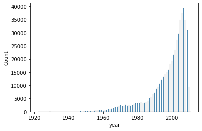

```python
#Here I am plotting number of UNIQUE songs BY YEAR without year == "0" - from the cleaned song database
song_df_clean_non_null_years = song_df_cleaned_by_year.drop(index = song_df_cleaned_by_year[song_df_cleaned_by_year["year"] == 0].index)

sns.histplot(song_df_clean_non_null_years.year)
```

```python
song_df_clean_non_null_years
```

|  | song_id | title | release | artist_name | year |
| --- | --- | --- | --- | --- | --- |
| 0 | SOQMMHC12AB0180CB8 | Silent Night | Monster Ballads X-Mas | Faster Pussy cat | 2003 |
| 1 | SOVFVAK12A8C1350D9 | Tanssi vaan | Karkuteillä | Karkkiautomaatti | 1995 |
| 2 | SOGTUKN12AB017F4F1 | No One Could Ever | Butter | Hudson Mohawke | 2006 |
| 3 | SOBNYVR12A8C13558C | Si Vos Querés | De Culo | Yerba Brava | 2003 |
| 7 | SOEYRFT12AB018936C | 2 Da Beat Ch'yall | Da Bomb | Kris Kross | 1993 |
| ... | ... | ... | ... | ... | ... |
| 999987 | SOMDVLO12A58A7A02B | Ether | 0 | Transmission0 | 2004 |
| 999990 | SOFAXZU12AB01881C4 | Way Down | Way Down | Taylor Hawkins & The Coattail Riders | 2010 |
| 999991 | SOYFFWW12A6701C135 | So Many People | Four | Bah Samba | 2002 |
| 999992 | SOBODSE12A8C13EBD6 | Inequality Street | No Daylights_ Nor Heeltaps | SKYCLAD | 1996 |
| 999999 | SOWXJXQ12AB0189F43 | Fernweh feat. Sektion Kuchikäschtli | So Oder So | Texta | 2004 |

514778 rows × 5 columns

```python
#checking how many records for each NON-"0" year in the cleaned song database
pd.concat([song_df_clean_non_null_years.year.value_counts(), song_df_clean_non_null_years.year.value_counts()/len(song_df_clean_non_null_years)], axis = 1).set_axis(["Count_Play", "%% In Total"], axis = 1, inplace = False)
```

|  | Count_Play | %% In Total |
| --- | --- | --- |
| 2007 | 39336 | 0.076414 |
| 2006 | 37488 | 0.072824 |
| 2005 | 34875 | 0.067748 |
| 2008 | 34684 | 0.067377 |
| 2009 | 30968 | 0.060158 |
| ... | ... | ... |
| 1925 | 7 | 0.000014 |
| 1922 | 6 | 0.000012 |
| 1933 | 6 | 0.000012 |
| 1924 | 5 | 0.000010 |
| 2011 | 1 | 0.000002 |

89 rows × 2 columns

```python
song_df_clean_non_null_years.describe().T #unique songs with year =! 0
```

|  | count | mean | std | min | 25% | 50% | 75% | max |
| --- | --- | --- | --- | --- | --- | --- | --- | --- |
| year | 514778.0 | 1998.393047 | 10.931672 | 1922.0 | 1994.0 | 2002.0 | 2006.0 | 2011.0 |

#### **Observations and Insights**

File "song_data.csv"

1. File “song_data.csv” contains 1 mln records of song IDs, corresponding to song title, name of release, artist name and year of release.
2. Types of data for this file:
- song_id, title, release, artist_name – object type
- year – integer (int64) type. From summary statistics I see that the "year" is in range of 0 to 2011 (0 is for a missing year). To reduce the use of memory maybe it is a good idea change the type of "year" from int64 (64-bit integer) to int16 (16-bit integer).
1. There are 15 missing values in “title” field, 5 missing values in “release” field.
2. Number of unique records:
- song_id 999 056 unique records
- title 702 428 unique records
- release 149 288 unique records
- artist_name 72 665 unique record
- year 90 unique records It means there are duplicates in this file.
1. Before dropping the duplicates, let’s analyze them. It was found out that:

1. After dropping duplicates, the data contained:
- song_id 999056 non-null records
- title 999041 non-null records
- release 999051 non-null records
- artist_name 999056 non-null records
- year 999056 non-null reords
1. It was found that there are 90 unique years in the data, one of them is “0” (missing year data). There are ~48.47% of records with missing year data.
2. From statistical summary it is seen that for non-“0” years minimum year is 1922, maximum year is 2011.

   ```
       The maximum number of songs are from years
   ```

- 2007 39336 7.6414%
- 2006 37488 7.2824%
- 2005 34875 6.7748%
- 2008 34684 6.7377%
- 2009 30968 6.0158%

  The least number of songs are from years:
- 2011 1 0.0002%
- 1924 5 0.0010%
- 1922 6 0.0012%
- 1933 6 0.0012%

## Since both the datasets have the column song_id, we can merge these datasets using this column.

```python
df = pd.merge(count_df, song_df_cleaned_by_year, on="song_id", how="left")
df = df.drop(['Unnamed: 0'],axis=1)
df
```

|  | user_id | song_id | play_count | title | release | artist_name | year |
| --- | --- | --- | --- | --- | --- | --- | --- |
| 0 | b80344d063b5ccb3212f76538f3d9e43d87dca9e | SOAKIMP12A8C130995 | 1 | The Cove | Thicker Than Water | Jack Johnson | 0 |
| 1 | b80344d063b5ccb3212f76538f3d9e43d87dca9e | SOBBMDR12A8C13253B | 2 | Entre Dos Aguas | Flamenco Para Niños | Paco De Lucia | 1976 |
| 2 | b80344d063b5ccb3212f76538f3d9e43d87dca9e | SOBXHDL12A81C204C0 | 1 | Stronger | Graduation | Kanye West | 2007 |
| 3 | b80344d063b5ccb3212f76538f3d9e43d87dca9e | SOBYHAJ12A6701BF1D | 1 | Constellations | In Between Dreams | Jack Johnson | 2005 |
| 4 | b80344d063b5ccb3212f76538f3d9e43d87dca9e | SODACBL12A8C13C273 | 1 | Learn To Fly | There Is Nothing Left To Lose | Foo Fighters | 1999 |
| ... | ... | ... | ... | ... | ... | ... | ... |
| 1999995 | d8bfd4ec88f0f3773a9e022e3c1a0f1d3b7b6a92 | SOJEYPO12AAA8C6B0E | 2 | Ignorance (Album Version) | Ignorance | Paramore | 0 |
| 1999996 | d8bfd4ec88f0f3773a9e022e3c1a0f1d3b7b6a92 | SOJJYDE12AF729FC16 | 4 | Two Is Better Than One | Love Drunk | Boys Like Girls featuring Taylor Swift | 2009 |
| 1999997 | d8bfd4ec88f0f3773a9e022e3c1a0f1d3b7b6a92 | SOJKQSF12A6D4F5EE9 | 3 | What I've Done (Album Version) | What I've Done | Linkin Park | 2007 |
| 1999998 | d8bfd4ec88f0f3773a9e022e3c1a0f1d3b7b6a92 | SOJUXGA12AC961885C | 1 | Up | My Worlds | Justin Bieber | 2010 |
| 1999999 | d8bfd4ec88f0f3773a9e022e3c1a0f1d3b7b6a92 | SOJYOLS12A8C13C06F | 1 | Soil_ Soil (Album Version) | The Con | Tegan And Sara | 2007 |

2000000 rows × 7 columns

```python
df.info()
```

```
<class 'pandas.core.frame.DataFrame'>
Int64Index: 2000000 entries, 0 to 1999999
Data columns (total 7 columns):
 #   Column       Dtype
---  ------       -----
 0   user_id      object
 1   song_id      object
 2   play_count   int64
 3   title        object
 4   release      object
 5   artist_name  object
 6   year         int64
dtypes: int64(2), object(5)
memory usage: 122.1+ MB
```

```python
df.nunique()
```

```
user_id        76353
song_id        10000
play_count       295
title           9564
release         5391
artist_name     3377
year              58
dtype: int64
```

**Think About It:** The user_id and the song_id are encrypted and these encryptions do not provide information about the user or the song. Can we transform these variables using label encoding to ease the processing?

```python
le = LabelEncoder()

df['user_id'] = le.fit_transform(df['user_id'])
```

```python
#Similarly, do the label encoding for the song_id column
df['song_id'] = le.fit_transform(df['song_id'])
```

```python
df.head()
```

|  | user_id | song_id | play_count | title | release | artist_name | year |
| --- | --- | --- | --- | --- | --- | --- | --- |
| 0 | 54961 | 153 | 1 | The Cove | Thicker Than Water | Jack Johnson | 0 |
| 1 | 54961 | 413 | 2 | Entre Dos Aguas | Flamenco Para Niños | Paco De Lucia | 1976 |
| 2 | 54961 | 736 | 1 | Stronger | Graduation | Kanye West | 2007 |
| 3 | 54961 | 750 | 1 | Constellations | In Between Dreams | Jack Johnson | 2005 |
| 4 | 54961 | 1188 | 1 | Learn To Fly | There Is Nothing Left To Lose | Foo Fighters | 1999 |

```python
df.info()
```

```
<class 'pandas.core.frame.DataFrame'>
Int64Index: 2000000 entries, 0 to 1999999
Data columns (total 7 columns):
 #   Column       Dtype
---  ------       -----
 0   user_id      int32
 1   song_id      int32
 2   play_count   int64
 3   title        object
 4   release      object
 5   artist_name  object
 6   year         int64
dtypes: int32(2), int64(2), object(3)
memory usage: 106.8+ MB
```

### **Let's check the total number of unique users, songs, artists in the data**

```python
df.nunique()
```

```
user_id        76353
song_id        10000
play_count       295
title           9564
release         5391
artist_name     3377
year              58
dtype: int64
```

#### **Observations and Insights**

- In the merged df types of "user_id" and "song_id" were converted from object to int32.
- There are 2mln records in the dataframe.
- Theare are 76 353 unqiue users IDs in the merged dataframe.
- These users were listening to 10 000 unique songs.
- There are 9564 unique titles of the songs. It means some songs with different "song_id" can have the same "title".
- These users were listening to the songs of 3377 unique artists.

**Think About It:** What does it mean for the value of year being 0? Would it affect the recommendations?

**Observation** The year with the values 0 - I would consider as a missing value of the year. Yes, it can affect recommendations.

**Think About It:** What other information can be extracted from this data? Try to explore the data. For example, we can find how the count of songs played has changed over the years. **I checked it earlier with the table and histogram.**

```python
# Let's count how many records in the merged table by year.
df2 = df["year"].value_counts()/2000000
years_table = pd.concat([df["year"].value_counts(), df2, df2.cumsum()], axis = 1)
years_table = years_table.set_axis(['Num of Years', '%% of this year', "Cumulative %%"], axis=1, inplace=False)
print("Number of rows in this YEAR table is:", len(years_table))
years_table
```

```
Number of rows in this YEAR table is: 58
```

|  | Num of Years | %% of this year | Cumulative %% |
| --- | --- | --- | --- |
| 0 | 366884 | 0.183442 | 0.183442 |
| 2009 | 179883 | 0.089941 | 0.273384 |
| 2008 | 166593 | 0.083296 | 0.356680 |
| 2007 | 161780 | 0.080890 | 0.437570 |
| 2006 | 125183 | 0.062591 | 0.500162 |
| 2005 | 113996 | 0.056998 | 0.557160 |
| 2003 | 104025 | 0.052013 | 0.609172 |
| 2004 | 74052 | 0.037026 | 0.646198 |
| 2002 | 71825 | 0.035912 | 0.682111 |
| 2010 | 69165 | 0.034583 | 0.716693 |
| 2001 | 63326 | 0.031663 | 0.748356 |
| 2000 | 57596 | 0.028798 | 0.777154 |
| 1999 | 37791 | 0.018895 | 0.796049 |
| 1997 | 33602 | 0.016801 | 0.812850 |
| 1996 | 27260 | 0.013630 | 0.826480 |
| 1994 | 24054 | 0.012027 | 0.838507 |
| 1995 | 23996 | 0.011998 | 0.850505 |
| 1998 | 23845 | 0.011923 | 0.862428 |
| 1992 | 23248 | 0.011624 | 0.874052 |
| 1991 | 19818 | 0.009909 | 0.883961 |
| 1990 | 18581 | 0.009291 | 0.893251 |
| 1993 | 17473 | 0.008736 | 0.901988 |
| 1986 | 16443 | 0.008221 | 0.910209 |
| 1987 | 13549 | 0.006775 | 0.916984 |
| 1988 | 11727 | 0.005863 | 0.922847 |
| 1984 | 11570 | 0.005785 | 0.928632 |
| 1989 | 11354 | 0.005677 | 0.934309 |
| 1982 | 10024 | 0.005012 | 0.939321 |
| 1974 | 9392 | 0.004696 | 0.944017 |
| 1983 | 9073 | 0.004536 | 0.948554 |
| 1970 | 8922 | 0.004461 | 0.953015 |
| 1985 | 7836 | 0.003918 | 0.956933 |
| 1979 | 7763 | 0.003881 | 0.960815 |
| 1978 | 6570 | 0.003285 | 0.964099 |
| 1969 | 6479 | 0.003240 | 0.967339 |
| 1973 | 6476 | 0.003238 | 0.970577 |
| 1981 | 6429 | 0.003214 | 0.973791 |
| 1976 | 6179 | 0.003089 | 0.976881 |
| 1968 | 5646 | 0.002823 | 0.979704 |
| 1975 | 5459 | 0.002730 | 0.982433 |
| 1980 | 5340 | 0.002670 | 0.985103 |
| 1977 | 4963 | 0.002482 | 0.987585 |
| 1972 | 4496 | 0.002248 | 0.989833 |
| 1971 | 4152 | 0.002076 | 0.991909 |
| 1967 | 3889 | 0.001945 | 0.993853 |
| 1965 | 2714 | 0.001357 | 0.995210 |
| 1966 | 2353 | 0.001177 | 0.996387 |
| 1964 | 1530 | 0.000765 | 0.997152 |
| 1962 | 1160 | 0.000580 | 0.997732 |
| 1963 | 942 | 0.000471 | 0.998203 |
| 1959 | 941 | 0.000470 | 0.998674 |
| 1958 | 765 | 0.000382 | 0.999056 |
| 1960 | 680 | 0.000340 | 0.999396 |
| 1956 | 403 | 0.000201 | 0.999598 |
| 1961 | 288 | 0.000144 | 0.999742 |
| 1957 | 225 | 0.000112 | 0.999854 |
| 1955 | 148 | 0.000074 | 0.999928 |
| 1954 | 144 | 0.000072 | 1.000000 |

### **Observation**

- ~18.34% Of all the records in the combined table has "year" = 0, i.e. missing year.
- It is almost one fifth of all the records. We cannot just omit this data.

**- I see 3 possibilities with recommendation system in this case:

```
- Consider songs with missing year and with assigned year separately (and give recommendation separately - depending on the fact if the song has a year or a missing year).
- Do not take year into account.
- Substitue "0"s with:
    - mean/median/mode/average of the corresponding artist or release
    (Example: "song_id" = SOEOMKM12A8C1342B2, artist_name = Jack Johnson, year = 0.
    Check all songs with non-"0" year for Jack Johnson and take average for this artist - kind of "aprox. year". In this example substitute "0" by average "2005").**
```

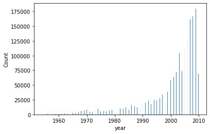

```python
#Here I am plotting number of UNIQUE songs with year != 0 - from df
song_df_non_null_years = df.drop(index = df[df["year"] == 0].index)
sns.histplot(song_df_non_null_years.year)
```

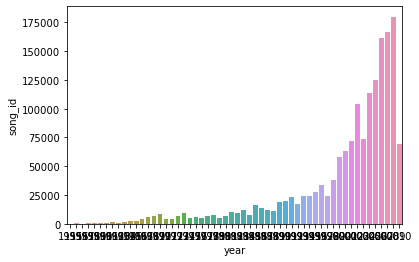

```python
#OR
#Plot a barplot to visualize the count of songs played each year
#Songs played in a year
count_songs = song_df_non_null_years.groupby(["year"]).count()["song_id"]
count = pd.DataFrame(count_songs)
count.drop(count.index[0], inplace=True)
count = count.reset_index()
count.head()
sns.barplot(x = 'year', y = "song_id", data = count)
```

```python
# Let's count how many records in the merged table by year - for NON-"0" years
df3 = song_df_non_null_years["year"].value_counts()/len(song_df_non_null_years)
years_table2 = pd.concat([song_df_non_null_years["year"].value_counts(), df3, df3.cumsum()], axis = 1)
years_table2 = years_table2.set_axis(['Num of Years', '%% of this year', "Cumulative %%"], axis=1, inplace=False)
print("Number of rows in this YEAR table is:", len(years_table2))
years_table2
```

```
Number of rows in this YEAR table is: 57
```

|  | Num of Years | %% of this year | Cumulative %% |
| --- | --- | --- | --- |
| 2009 | 179883 | 0.110147 | 0.110147 |
| 2008 | 166593 | 0.102009 | 0.212156 |
| 2007 | 161780 | 0.099062 | 0.311219 |
| 2006 | 125183 | 0.076653 | 0.387871 |
| 2005 | 113996 | 0.069803 | 0.457674 |
| 2003 | 104025 | 0.063697 | 0.521371 |
| 2004 | 74052 | 0.045344 | 0.566715 |
| 2002 | 71825 | 0.043980 | 0.610696 |
| 2010 | 69165 | 0.042352 | 0.653047 |
| 2001 | 63326 | 0.038776 | 0.691823 |
| 2000 | 57596 | 0.035268 | 0.727091 |
| 1999 | 37791 | 0.023140 | 0.750231 |
| 1997 | 33602 | 0.020575 | 0.770807 |
| 1996 | 27260 | 0.016692 | 0.787499 |
| 1994 | 24054 | 0.014729 | 0.802228 |
| 1995 | 23996 | 0.014693 | 0.816921 |
| 1998 | 23845 | 0.014601 | 0.831522 |
| 1992 | 23248 | 0.014235 | 0.845757 |
| 1991 | 19818 | 0.012135 | 0.857893 |
| 1990 | 18581 | 0.011378 | 0.869270 |
| 1993 | 17473 | 0.010699 | 0.879969 |
| 1986 | 16443 | 0.010068 | 0.890038 |
| 1987 | 13549 | 0.008296 | 0.898334 |
| 1988 | 11727 | 0.007181 | 0.905515 |
| 1984 | 11570 | 0.007085 | 0.912600 |
| 1989 | 11354 | 0.006952 | 0.919552 |
| 1982 | 10024 | 0.006138 | 0.925690 |
| 1974 | 9392 | 0.005751 | 0.931441 |
| 1983 | 9073 | 0.005556 | 0.936997 |
| 1970 | 8922 | 0.005463 | 0.942460 |
| 1985 | 7836 | 0.004798 | 0.947258 |
| 1979 | 7763 | 0.004753 | 0.952011 |
| 1978 | 6570 | 0.004023 | 0.956034 |
| 1969 | 6479 | 0.003967 | 0.960002 |
| 1973 | 6476 | 0.003965 | 0.963967 |
| 1981 | 6429 | 0.003937 | 0.967904 |
| 1976 | 6179 | 0.003784 | 0.971687 |
| 1968 | 5646 | 0.003457 | 0.975144 |
| 1975 | 5459 | 0.003343 | 0.978487 |
| 1980 | 5340 | 0.003270 | 0.981757 |
| 1977 | 4963 | 0.003039 | 0.984796 |
| 1972 | 4496 | 0.002753 | 0.987549 |
| 1971 | 4152 | 0.002542 | 0.990091 |
| 1967 | 3889 | 0.002381 | 0.992473 |
| 1965 | 2714 | 0.001662 | 0.994135 |
| 1966 | 2353 | 0.001441 | 0.995575 |
| 1964 | 1530 | 0.000937 | 0.996512 |
| 1962 | 1160 | 0.000710 | 0.997222 |
| 1963 | 942 | 0.000577 | 0.997799 |
| 1959 | 941 | 0.000576 | 0.998375 |
| 1958 | 765 | 0.000468 | 0.998844 |
| 1960 | 680 | 0.000416 | 0.999260 |
| 1956 | 403 | 0.000247 | 0.999507 |
| 1961 | 288 | 0.000176 | 0.999683 |
| 1957 | 225 | 0.000138 | 0.999821 |
| 1955 | 148 | 0.000091 | 0.999912 |
| 1954 | 144 | 0.000088 | 1.000000 |

#### **Observations and Insights:**

- In the merged dataframe with NON-"0" year:
  - ~57% of records belongs to the years from 2003 to 2009.
  - ~75% of records belongs to the years from 1999 to 2010.

### **Let's find out about the most interacted songs and interacted users**

```python
#Check the most interacted songs by using the title column. Hint: Use value_counts() method
df["title"].value_counts()
```

```
Sehr kosmisch                     8277
Undo                              7032
Dog Days Are Over (Radio Edit)    6949
You're The One                    6729
Revelry                           6145
                                  ...
Historia Del Portero                51
Scared                              51
Don´t Leave Me Now                  50
Ghosts (Toxic Avenger Mix)          48
No Creo En El Jamas                 48
Name: title, Length: 9564, dtype: int64
```

```python
#Check the most interacted songs by using the song_id column. Hint: Use value_counts() method
songs_interaction = df["song_id"].value_counts()
songs_interaction
```

```
2220    8277
317     7032
352     6949
614     6412
7416    6145
        ...
8747      51
4492      51
622       50
2666      48
9638      48
Name: song_id, Length: 10000, dtype: int64
```

```python
songs_played = df.groupby(['song_id']).agg({'play_count': 'sum'})

songs_played = songs_played.sort_values("play_count", ascending=False)

#df = df.drop("new_play_count"], axis=1)

songs_played
```

| song_id | play_count |
| --- | --- |
| 614 | 54136 |
| 317 | 49253 |
| 7416 | 41418 |
| 1664 | 31153 |
| 2220 | 31036 |
| ... | ... |
| 164 | 76 |
| 7251 | 75 |
| 1771 | 73 |
| 5402 | 73 |
| 3971 | 71 |

10000 rows × 1 columns

#### **Song 2220 "Sehr kosmisch" was interacted with 8277 unique users out of 76 353, that is 10.8% of all the songs. So, we still have a lot of users who did not listen to this song but maybe will like it.**

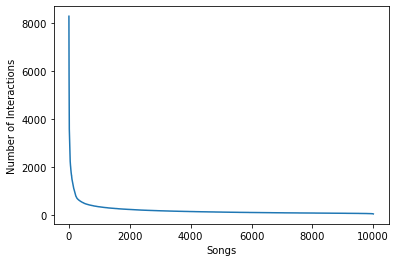

```python
p = plt.plot(songs_interaction.values)
plt.xlabel("Songs")
plt.ylabel("Number of Interactions")
```

```python
songs_interaction.head(57)
```

```
2220    8277
317     7032
352     6949
614     6412
7416    6145
5531    5841
1664    5385
4448    4795
1334    4758
2115    4548
8582    3976
8092    3947
8138    3879
7791    3578
6246    3526
```

[output cut: 43 more lines]

```python
songs_interaction.tail(8000)
```

```
4189    233
4256    233
872     233
5494    233
9061    233
       ...
8747     51
4492     51
622      50
2666     48
9638     48
Name: song_id, Length: 8000, dtype: int64
```

#### **Observations and Insights**

- It means that for the same "title" there can be different "song_id" -> the title of the song is not unique.

```python
#Let's filter our df by the song title "You're The One" and see if our assumption that
#there can be several different songs (song_id-s) with the same title is correct.

df_with_the_song_Youre_The_One = df[df["title"]=="You're The One"]
df_with_the_song_Youre_The_One.head(20)
```

|  | user_id | song_id | play_count | title | release | artist_name | year |
| --- | --- | --- | --- | --- | --- | --- | --- |
| 91 | 66678 | 614 | 2 | You're The One | If There Was A Way | Dwight Yoakam | 1990 |
| 304 | 63855 | 614 | 26 | You're The One | If There Was A Way | Dwight Yoakam | 1990 |
| 578 | 27018 | 5962 | 1 | You're The One | Magic Potion | The Black Keys | 2006 |
| 1022 | 3204 | 614 | 8 | You're The One | If There Was A Way | Dwight Yoakam | 1990 |
| 1341 | 12898 | 614 | 2 | You're The One | If There Was A Way | Dwight Yoakam | 1990 |
| 1702 | 34420 | 614 | 1 | You're The One | If There Was A Way | Dwight Yoakam | 1990 |
| 1813 | 45949 | 614 | 58 | You're The One | If There Was A Way | Dwight Yoakam | 1990 |
| 1887 | 54615 | 614 | 2 | You're The One | If There Was A Way | Dwight Yoakam | 1990 |
| 2178 | 18971 | 614 | 5 | You're The One | If There Was A Way | Dwight Yoakam | 1990 |
| 2512 | 29430 | 614 | 2 | You're The One | If There Was A Way | Dwight Yoakam | 1990 |
| 2694 | 6937 | 614 | 4 | You're The One | If There Was A Way | Dwight Yoakam | 1990 |
| 3314 | 70000 | 5962 | 1 | You're The One | Magic Potion | The Black Keys | 2006 |
| 3362 | 44648 | 614 | 1 | You're The One | If There Was A Way | Dwight Yoakam | 1990 |
| 3495 | 53923 | 5962 | 1 | You're The One | Magic Potion | The Black Keys | 2006 |
| 3693 | 19568 | 614 | 6 | You're The One | If There Was A Way | Dwight Yoakam | 1990 |
| 4227 | 68099 | 614 | 20 | You're The One | If There Was A Way | Dwight Yoakam | 1990 |
| 4326 | 24524 | 614 | 2 | You're The One | If There Was A Way | Dwight Yoakam | 1990 |
| 4392 | 41638 | 614 | 5 | You're The One | If There Was A Way | Dwight Yoakam | 1990 |
| 4822 | 35178 | 614 | 4 | You're The One | If There Was A Way | Dwight Yoakam | 1990 |
| 5347 | 16375 | 614 | 79 | You're The One | If There Was A Way | Dwight Yoakam | 1990 |

**Observation**

- So, we can see that there can be several unique songs (song_id-s) with the same title. These songs are different - have different artist, release, and year.
- That's why:
  - when customer types a keyword - we need to go "title" route (in this case can be different "song-id"-s.
  - when looking for similarities and recommending songs - go to "song_id" route.

```python
#Check unique users with the most interaction by using the user_id column. Hint: Use value_counts() method
users_interactions = df["user_id"].value_counts()
#users_interactions = users_interactions.set_axis(['user_id', 'num_of_interactions'], axis=1, inplace=False)
users_interactions
```

```
32542    711
75144    643
23297    556
10807    540
7834     533
        ...
33372      1
5374       1
70176      1
72171      1
41776      1
Name: user_id, Length: 76353, dtype: int64
```

#### ** User 32 542 interacted with 711 songs (which is maximum number of interactions among all users). Out of 10 000 available unique songs. Which is ~7% of all the songs. It means we still have plenty of songs to offer to this user.

```python
#printing this dataframe to excel - only 1840 rows x 5 columns
#users_interactions.to_excel("output_users.xlsx")
```

```python
users_interactions.head(764)
```

```
32542    711
75144    643
23297    556
10807    540
7834     533
        ...
55624    158
1035     158
67690    158
20953    158
26438    158
Name: user_id, Length: 764, dtype: int64
```

```python
users_interactions.tail(50000)
```

```
22019    23
42806    23
13066    23
29681    23
21342    23
         ..
33372     1
5374      1
70176     1
72171     1
41776     1
Name: user_id, Length: 50000, dtype: int64
```

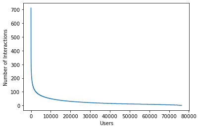

```python
p = plt.plot(users_interactions.values)
plt.xlabel("Users")
plt.ylabel("Number of Interactions")
```

**Observation**

- The users, who interacted with the most number of songs:
  - user 32542 - interacted with 711 songs
  - user 75144 - interacted with 643 songs
  - user 23297 - interacted with 556 songs
- Some users interacted only with 1 song

```python
#Check unique artists with the most interaction by using the artist_name column. Hint: Use value_counts() method
artists = df["artist_name"].value_counts()
artists
```

```
Coldplay                  29422
The Black Keys            19862
Kings Of Leon             18747
Florence + The Machine    18112
Jack Johnson              17801
                          ...
Shotta                       54
The Four Seasons             52
Ricardo Montaner             52
Umphrey's McGee              52
Amparanoia                   50
Name: artist_name, Length: 3377, dtype: int64
```

```python
#Check unique artists with the most interaction by using the artist_name column. Hint: Use value_counts() method
releases = df["release"].value_counts()
releases
```

```
Greatest Hits                                   16613
My Worlds                                        9797
Waking Up                                        9469
Save Me_ San Francisco                           9388
Now That's What I Call Music! 75                 8781
                                                ...
Jersey Boys Original Broadway Cast Recording       52
Las #1 De Ricardo Montaner                         52
Historias                                          51
Enchilao                                           50
Ghosts (Remixes)                                   48
Name: release, Length: 5391, dtype: int64
```

```python
artists1 = df.groupby(["artist_name","year","release"]).count()
artists1.sort_values(by=["play_count"])
artists1.tail(20)
```

| artist_name | year | release | user_id | song_id | play_count | title |
| --- | --- | --- | --- | --- | --- | --- |
| iio | 2004 | Runaway | 103 | 103 | 103 | 103 |
| keller williams | 1998 | Spun | 158 | 158 | 158 | 158 |
| matchbox twenty | 1996 | Yourself Or Someone Like You | 1052 | 1052 | 1052 | 1052 |
|  | 2000 | Bent | 288 | 288 | 288 | 288 |
|  |  | Mad Season | 207 | 207 | 207 | 207 |
|  | 2002 | More Than You Think You Are | 378 | 378 | 378 | 378 |
|  | 2003 | More Than You Think You Are | 618 | 618 | 618 | 618 |
|  | 2007 | Exile On Mainstream | 942 | 942 | 942 | 942 |
| moe. | 1996 | No Doy | 136 | 136 | 136 | 136 |
| rinôçérôse | 2002 | Music Kills Me | 88 | 88 | 88 | 88 |
| the bird and the bee | 0 | I Hate Camera - Japan-Only EP | 114 | 114 | 114 | 114 |
|  | 2006 | the bird and the bee | 637 | 637 | 637 | 637 |
|  | 2007 | Ray Guns Are Not Just The Future | 384 | 384 | 384 | 384 |
|  |  | the bird and the bee | 330 | 330 | 330 | 330 |
|  | 2008 | One Too Many Hearts | 273 | 273 | 273 | 273 |
|  |  | Ray Guns Are Not Just The Future | 314 | 314 | 314 | 314 |
|  | 2009 | Ray Guns Are Not Just The Future | 3177 | 3177 | 3177 | 3177 |
| themselves | 2009 | Crownsdown | 108 | 108 | 108 | 108 |
| tobyMac | 0 | Portable Sounds With Bonus Remixes | 79 | 79 | 79 | 79 |
|  | 2009 | WOW Hits 2010 | 88 | 88 | 88 | 88 |

```python
artists_by_years = song_df_non_null_years.groupby(["year","artist_name"]).count()
artists_by_years.head(30)
```

| year | artist_name | user_id | song_id | play_count | title | release |
| --- | --- | --- | --- | --- | --- | --- |
| 1954 | Penguins | 144 | 144 | 144 | 144 | 144 |
| 1955 | Bo Diddley | 148 | 148 | 148 | 148 | 148 |
| 1956 | Chuck Berry | 265 | 265 | 265 | 265 | 265 |
|  | Frankie Lymon And The Teenagers | 138 | 138 | 138 | 138 | 138 |
| 1957 | Bobby Helms | 225 | 225 | 225 | 225 | 225 |
| 1958 | Brenda Lee | 133 | 133 | 133 | 133 | 133 |
|  | Chordettes | 105 | 105 | 105 | 105 | 105 |
|  | Dion & The Belmonts | 169 | 169 | 169 | 169 | 169 |
|  | Jackie Wilson | 72 | 72 | 72 | 72 | 72 |
|  | Nina Simone | 70 | 70 | 70 | 70 | 70 |
|  | The Champs | 216 | 216 | 216 | 216 | 216 |
| 1959 | Big Bopper | 346 | 346 | 346 | 346 | 346 |
|  | Bobby Darin | 157 | 157 | 157 | 157 | 157 |
|  | Chuck Berry | 114 | 114 | 114 | 114 | 114 |
|  | Dion & The Belmonts | 156 | 156 | 156 | 156 | 156 |
|  | Everly Brothers | 88 | 88 | 88 | 88 | 88 |
|  | Joao Gilberto | 80 | 80 | 80 | 80 | 80 |
| 1960 | Buddy Holly | 171 | 171 | 171 | 171 | 171 |
|  | Charles Mingus | 74 | 74 | 74 | 74 | 74 |
|  | Julie London | 295 | 295 | 295 | 295 | 295 |
|  | Oscar Brown Jr. | 72 | 72 | 72 | 72 | 72 |
|  | The Ventures | 68 | 68 | 68 | 68 | 68 |
| 1961 | April Stevens | 104 | 104 | 104 | 104 | 104 |
|  | Gene Chandler | 100 | 100 | 100 | 100 | 100 |
|  | The Tokens | 84 | 84 | 84 | 84 | 84 |
| 1962 | Herb Alpert And The Tijuana Brass | 162 | 162 | 162 | 162 | 162 |
|  | João Gilberto | 325 | 325 | 325 | 325 | 325 |
|  | Patsy Cline / The Jordanaires | 105 | 105 | 105 | 105 | 105 |
|  | The Contours | 172 | 172 | 172 | 172 | 172 |
|  | The Dells | 276 | 276 | 276 | 276 | 276 |

## Proposed Approach

### Potential Techniques

Different techniques can be applied:

- I wanted at the beginning to try clustering (to find groups of users with similar tastes and groups of songs, liked by users, so we can consider that within the cluster the users and items are similar. In this case we can give the same (average) recommendations to all the users in this group). I double-checked – the matrix would be sparse, so probably clustering will not be a good idea.
- It is a better idea to apply user-user collaborative filtering (find groups of users with similar tastes to predict the songs they like based on their previous behavior (what songs they listened and how many times).
- We also can consider item-item collaborative filtering (find similarities between songs that users listened to).
- In case of the problem of "cold start" for some users (new users or users with very little interaction – we have some users with only 1 interaction), we can use averaging (popularity-based recommendations) or content-based filtering.
- For collaborative filtering to complete matrix estimation, we will use Singular Value Decomposition (SVD).
- For measuring similarities, we will use cosine similarity.
- For validation of the model, we can use simple random 80/20 split for training/testing sets or use k-fold Cross-Validation.

## Overall Solution Design

- Prepare the data.
- Convert data into matrix with users on one side, songs - on perpendicular side, number interactions (number of times particular user listened to a song) - inside the matrix. The matrix will be sparse.
- For clustering algorithm (in this case probably not a good solution as the matrix is sparse): compute similarity between each pair of users, obtain representation of each user in low dimensional space, perform k-means algorithm, and find k number of clusters. Predict recommendation for each cluster.
- For collaborative filtering (user-user): represent every user by its vector of interactions with all songs, compute (probably cosine) similarity between our target user and all other users, find k-nearest-neighbors (users) to our user, suggest popular songs among similar users (that our user didn't listen to).
- For collaborative filtering (item-item): represent items/songs by its vectors with every user, compute similarities between the song the user likes the most and all other songs, find k-nearest-neighbors of the song the user likes the most, recommend those songs that are new to the user.
- For new users (if we have the problem of "cold start") we use:
- Averaging/popularity-based: recommending top popular songs: calculate number of interactions for each song (or average number among non-“0” interactions). Recommend songs with the most interactions.
- or Content-based filtering: classification - traditional supervised ML problem.

## Measures of success

From the data science point of view key measures of success are:

- Precision, recall
- F1-score
- Root Mean Square Error (RMSE).
- Mean Average Precision at K (MAP@K)

From the business point of view key measures of success will be:

- Click through rate after recommendation provided.
- Conversion rate.
- Purchases.
- Revenue, Return on Investment.
- Number of loyal customers.
- Customer Lifetime Value, etc.

# **Music Recommendation System**

# **Milestone 2**

Now that we have explored the data, let's apply different algorithms to build recommendation systems

```python
## I am gouping by song_id, not by title, as song_id is unique for the song, title is not unique.
play_count = df.groupby(["song_id"]).count() #Hint: Use groupby function on the title column
count_sum = df.groupby(["song_id"]).sum() #Hint: Use groupby function on the title column
```

```python
df
```

|  | user_id | song_id | play_count | title | release | artist_name | year |
| --- | --- | --- | --- | --- | --- | --- | --- |
| 0 | 54961 | 153 | 1 | The Cove | Thicker Than Water | Jack Johnson | 0 |
| 1 | 54961 | 413 | 2 | Entre Dos Aguas | Flamenco Para Niños | Paco De Lucia | 1976 |
| 2 | 54961 | 736 | 1 | Stronger | Graduation | Kanye West | 2007 |
| 3 | 54961 | 750 | 1 | Constellations | In Between Dreams | Jack Johnson | 2005 |
| 4 | 54961 | 1188 | 1 | Learn To Fly | There Is Nothing Left To Lose | Foo Fighters | 1999 |
| ... | ... | ... | ... | ... | ... | ... | ... |
| 1999995 | 64590 | 3660 | 2 | Ignorance (Album Version) | Ignorance | Paramore | 0 |
| 1999996 | 64590 | 3736 | 4 | Two Is Better Than One | Love Drunk | Boys Like Girls featuring Taylor Swift | 2009 |
| 1999997 | 64590 | 3744 | 3 | What I've Done (Album Version) | What I've Done | Linkin Park | 2007 |
| 1999998 | 64590 | 3893 | 1 | Up | My Worlds | Justin Bieber | 2010 |
| 1999999 | 64590 | 3963 | 1 | Soil_ Soil (Album Version) | The Con | Tegan And Sara | 2007 |

2000000 rows × 7 columns

```python
df.info()
```

```
<class 'pandas.core.frame.DataFrame'>
Int64Index: 2000000 entries, 0 to 1999999
Data columns (total 7 columns):
 #   Column       Dtype
---  ------       -----
 0   user_id      int32
 1   song_id      int32
 2   play_count   int64
 3   title        object
 4   release      object
 5   artist_name  object
 6   year         int64
dtypes: int32(2), int64(2), object(3)
memory usage: 171.3+ MB
```

```python
play_count.head()
```

| song_id | user_id | play_count | title | release | artist_name | year |
| --- | --- | --- | --- | --- | --- | --- |
| 0 | 66 | 66 | 66 | 66 | 66 | 66 |
| 1 | 147 | 147 | 147 | 147 | 147 | 147 |
| 2 | 67 | 67 | 67 | 67 | 67 | 67 |
| 3 | 62 | 62 | 62 | 62 | 62 | 62 |
| 4 | 190 | 190 | 190 | 190 | 190 | 190 |

```python
play_count.info()
```

```
<class 'pandas.core.frame.DataFrame'>
Int64Index: 10000 entries, 0 to 9999
Data columns (total 6 columns):
 #   Column       Non-Null Count  Dtype
---  ------       --------------  -----
 0   user_id      10000 non-null  int64
 1   play_count   10000 non-null  int64
 2   title        10000 non-null  int64
 3   release      10000 non-null  int64
 4   artist_name  10000 non-null  int64
 5   year         10000 non-null  int64
dtypes: int64(6)
memory usage: 546.9 KB
```

```python
count_sum.head()
```

| song_id | user_id | play_count | year |
| --- | --- | --- | --- |
| 0 | 2449807 | 227 | 132528 |
| 1 | 5510334 | 352 | 0 |
| 2 | 2678633 | 158 | 134603 |
| 3 | 2373112 | 131 | 0 |
| 4 | 7512571 | 405 | 380000 |

```python
count_sum.info()
```

```
<class 'pandas.core.frame.DataFrame'>
Int64Index: 10000 entries, 0 to 9999
Data columns (total 3 columns):
 #   Column      Non-Null Count  Dtype
---  ------      --------------  -----
 0   user_id     10000 non-null  int32
 1   play_count  10000 non-null  int64
 2   year        10000 non-null  int64
dtypes: int32(1), int64(2)
memory usage: 273.4 KB
```

```python
final_short = pd.DataFrame({'count_sum': count_sum["play_count"], 'play_count': play_count["play_count"]}).sort_values(by="count_sum", ascending = 0)
final_short
```

| song_id | count_sum | play_count |
| --- | --- | --- |
| 614 | 54136 | 6412 |
| 317 | 49253 | 7032 |
| 7416 | 41418 | 6145 |
| 1664 | 31153 | 5385 |
| 2220 | 31036 | 8277 |
| ... | ... | ... |
| 164 | 76 | 65 |
| 7251 | 75 | 68 |
| 1771 | 73 | 60 |
| 5402 | 73 | 62 |
| 3971 | 71 | 65 |

10000 rows × 2 columns

```python
f = final_short.reset_index().merge(df, left_on = "song_id", right_on = "song_id", how = "inner").drop_duplicates(subset = ["song_id"])
final= f.drop(columns = ["user_id","play_count_y"]).set_index("song_id")
final.rename(columns={'play_count_x': 'play_count'}, inplace=True)
final
```

| song_id | count_sum | play_count | title | release | artist_name | year |
| --- | --- | --- | --- | --- | --- | --- |
| 614 | 54136 | 6412 | You're The One | If There Was A Way | Dwight Yoakam | 1990 |
| 317 | 49253 | 7032 | Undo | Vespertine Live | Björk | 2001 |
| 7416 | 41418 | 6145 | Revelry | Only By The Night | Kings Of Leon | 2008 |
| 1664 | 31153 | 5385 | Horn Concerto No. 4 in E flat K495: II. Romanc... | Mozart - Eine kleine Nachtmusik | Barry Tuckwell/Academy of St Martin-in-the-Fie... | 0 |
| 2220 | 31036 | 8277 | Sehr kosmisch | Musik von Harmonia | Harmonia | 0 |
| ... | ... | ... | ... | ... | ... | ... |
| 164 | 76 | 65 | Summer In Dixie (LP Version) | Notorious | Confederate Railroad | 1994 |
| 7251 | 75 | 68 | Slan Le Maige | Heroes | Reel Feelings | 0 |
| 1771 | 73 | 60 | Traveling Man | Spirits All Around Us | John Brown's Body | 2001 |
| 5402 | 73 | 62 | Robot Rock (Soulwax Remix) | Robot Rock | Daft Punk | 2005 |
| 3971 | 71 | 65 | clouding | Everything Ecstatic | Four Tet | 2005 |

10000 rows × 6 columns

#### **To reduce computational complexity, let's create a shorter vestion of the data.

We can create shorter version of the merged dataset **df** by filtering top 5000 most played songs and top 5000 users who has interacted most. In this case we will recieve more dense matrix of users/items and reduce calculation time.

```python
#Find IDs of top 5000 songs
top5000_most_played_songs = final.sort_values(by='play_count', ascending=False).index[:5000].values
top5000_most_played_songs
```

```
array([2220,  317,  352, ..., 1502, 5533, 5170], dtype=int64)
```

```python
#Find IDs of top 5000 users
top5000_users = users_interactions.index[:5000].values
top5000_users
```

```
array([32542, 75144, 23297, ..., 33485, 67310, 42239], dtype=int64)
```

```python
type(top5000_users)
```

```
numpy.ndarray
```

```python
#Filter the original data to contain only the top 5000 songs
df_smaller_only_top5000_songs = df[df.song_id.isin(top5000_most_played_songs)]
df_smaller_only_top5000_songs
```

|  | user_id | song_id | play_count | title | release | artist_name | year |
| --- | --- | --- | --- | --- | --- | --- | --- |
| 0 | 54961 | 153 | 1 | The Cove | Thicker Than Water | Jack Johnson | 0 |
| 1 | 54961 | 413 | 2 | Entre Dos Aguas | Flamenco Para Niños | Paco De Lucia | 1976 |
| 2 | 54961 | 736 | 1 | Stronger | Graduation | Kanye West | 2007 |
| 3 | 54961 | 750 | 1 | Constellations | In Between Dreams | Jack Johnson | 2005 |
| 4 | 54961 | 1188 | 1 | Learn To Fly | There Is Nothing Left To Lose | Foo Fighters | 1999 |
| ... | ... | ... | ... | ... | ... | ... | ... |
| 1999994 | 64590 | 3390 | 4 | Unwell (Album Version) | More Than You Think You Are | matchbox twenty | 2003 |
| 1999995 | 64590 | 3660 | 2 | Ignorance (Album Version) | Ignorance | Paramore | 0 |
| 1999996 | 64590 | 3736 | 4 | Two Is Better Than One | Love Drunk | Boys Like Girls featuring Taylor Swift | 2009 |
| 1999997 | 64590 | 3744 | 3 | What I've Done (Album Version) | What I've Done | Linkin Park | 2007 |
| 1999998 | 64590 | 3893 | 1 | Up | My Worlds | Justin Bieber | 2010 |

1547961 rows × 7 columns

```python
#Filter the data with top 5000 songs to contain only top 5000 users

df_small = df_smaller_only_top5000_songs[df_smaller_only_top5000_songs.user_id.isin(top5000_users)]
df_small
```

|  | user_id | song_id | play_count | title | release | artist_name | year |
| --- | --- | --- | --- | --- | --- | --- | --- |
| 197 | 6958 | 40 | 1 | Full Circle | Breakout | Miley Cyrus | 2008 |
| 198 | 6958 | 151 | 2 | Poor Jackie | Rabbit Habits | Man Man | 2008 |
| 199 | 6958 | 326 | 1 | Hot N Cold (Manhattan Clique Remix Radio Edit) | Hot N Cold | Katy Perry | 2008 |
| 200 | 6958 | 447 | 1 | Daisy And Prudence | Distillation | Erin McKeown | 2000 |
| 201 | 6958 | 484 | 1 | Everythings Just Wonderful | Alright_ Still | Lily Allen | 0 |
| ... | ... | ... | ... | ... | ... | ... | ... |
| 1999761 | 47786 | 9717 | 1 | Do You Wanna | Konk | The Kooks | 2008 |
| 1999764 | 47786 | 9803 | 1 | Oh Comely | In The Aeroplane Over The Sea | Neutral Milk Hotel | 1998 |
| 1999765 | 47786 | 9847 | 1 | He Can Only Hold Her | Back To Black | Amy Winehouse | 2006 |
| 1999766 | 47786 | 9858 | 5 | Drunk Kid Catholic | Noise Floor [Rarities 98 - 05] | Bright Eyes | 2000 |
| 1999768 | 47786 | 9954 | 3 | Let's Live For Today | 150 Rock 'N' Roll Classics | The Grass Roots | 1987 |

456352 rows × 7 columns

```python
#Use the smaller version of the original data to compute interaction matrix

interactions_matrix = df_small.pivot(index='user_id', columns='song_id', values='play_count')

interactions_matrix
```

| song_id user_id | 1 | 4 | 5 | 11 | 14 | 15 | 16 | 17 | 20 | 21 | ... | 9976 | 9977 | 9981 | 9983 | 9988 | 9989 | 9992 | 9994 | 9995 | 9996 |
| --- | --- | --- | --- | --- | --- | --- | --- | --- | --- | --- | --- | --- | --- | --- | --- | --- | --- | --- | --- | --- | --- |
| 11 | NaN | NaN | NaN | NaN | NaN | NaN | NaN | NaN | NaN | NaN | ... | NaN | NaN | NaN | NaN | NaN | NaN | NaN | NaN | NaN | NaN |
| 17 | NaN | NaN | NaN | NaN | NaN | NaN | NaN | NaN | NaN | NaN | ... | NaN | NaN | NaN | NaN | NaN | NaN | NaN | NaN | NaN | NaN |
| 32 | NaN | NaN | NaN | NaN | NaN | NaN | NaN | NaN | NaN | NaN | ... | NaN | NaN | NaN | NaN | NaN | NaN | NaN | NaN | NaN | NaN |
| 42 | NaN | NaN | NaN | NaN | NaN | NaN | NaN | NaN | NaN | NaN | ... | NaN | NaN | NaN | NaN | NaN | NaN | NaN | NaN | NaN | NaN |
| 57 | NaN | NaN | 5.0 | NaN | NaN | NaN | NaN | NaN | NaN | NaN | ... | NaN | NaN | NaN | NaN | NaN | NaN | NaN | NaN | NaN | NaN |
| ... | ... | ... | ... | ... | ... | ... | ... | ... | ... | ... | ... | ... | ... | ... | ... | ... | ... | ... | ... | ... | ... |
| 76307 | NaN | NaN | NaN | NaN | NaN | NaN | NaN | NaN | NaN | NaN | ... | NaN | NaN | NaN | NaN | NaN | NaN | NaN | NaN | NaN | NaN |
| 76331 | NaN | NaN | NaN | NaN | NaN | NaN | NaN | NaN | 4.0 | NaN | ... | NaN | NaN | NaN | NaN | NaN | NaN | NaN | NaN | NaN | NaN |
| 76333 | NaN | NaN | NaN | NaN | NaN | NaN | NaN | NaN | NaN | NaN | ... | NaN | NaN | NaN | NaN | NaN | NaN | NaN | NaN | NaN | NaN |
| 76342 | NaN | NaN | NaN | NaN | NaN | NaN | NaN | NaN | NaN | NaN | ... | NaN | NaN | NaN | NaN | NaN | NaN | NaN | NaN | NaN | NaN |
| 76347 | NaN | NaN | NaN | NaN | NaN | NaN | NaN | NaN | NaN | NaN | ... | NaN | NaN | NaN | NaN | NaN | NaN | NaN | NaN | NaN | NaN |

5000 rows × 5000 columns

```python
nan_count = interactions_matrix.isnull().sum().sum()
non_nan_count = 5000*5000 - nan_count
print("\nNumber of NaN-s: ", nan_count, " ", nan_count/250000, "%% of matrix",
      "\nNumber of non-NaN-s: ", non_nan_count, " ", non_nan_count/250000, "%% of matrix")
```

```
Number of NaN-s:  24543648   98.174592 %% of matrix
Number of non-NaN-s:  456352   1.825408 %% of matrix
```

#### **Observations and Insights**

We got the matrix 5000 by 5000 of 5000 top users and top 5000 played songs. This matrix is more dense than matrix of all users and all songs. Number of NaN values of the cells in the reduced matrix is 24 543 648, which is ~98.17% of the cells. Number of non-NaN values of the cells in the reduced matrix is 456 352,vwhich is ~1.83% of the cells. The matrix is very sparse.

```python
# Replace the missing values in the interactions_matrix with 0 values.
interactions_matrix_replace = interactions_matrix.replace(np.nan, 0)
```

```python
interactions_matrix_replace
```

| song_id user_id | 1 | 4 | 5 | 11 | 14 | 15 | 16 | 17 | 20 | 21 | ... | 9976 | 9977 | 9981 | 9983 | 9988 | 9989 | 9992 | 9994 | 9995 | 9996 |
| --- | --- | --- | --- | --- | --- | --- | --- | --- | --- | --- | --- | --- | --- | --- | --- | --- | --- | --- | --- | --- | --- |
| 11 | 0.0 | 0.0 | 0.0 | 0.0 | 0.0 | 0.0 | 0.0 | 0.0 | 0.0 | 0.0 | ... | 0.0 | 0.0 | 0.0 | 0.0 | 0.0 | 0.0 | 0.0 | 0.0 | 0.0 | 0.0 |
| 17 | 0.0 | 0.0 | 0.0 | 0.0 | 0.0 | 0.0 | 0.0 | 0.0 | 0.0 | 0.0 | ... | 0.0 | 0.0 | 0.0 | 0.0 | 0.0 | 0.0 | 0.0 | 0.0 | 0.0 | 0.0 |
| 32 | 0.0 | 0.0 | 0.0 | 0.0 | 0.0 | 0.0 | 0.0 | 0.0 | 0.0 | 0.0 | ... | 0.0 | 0.0 | 0.0 | 0.0 | 0.0 | 0.0 | 0.0 | 0.0 | 0.0 | 0.0 |
| 42 | 0.0 | 0.0 | 0.0 | 0.0 | 0.0 | 0.0 | 0.0 | 0.0 | 0.0 | 0.0 | ... | 0.0 | 0.0 | 0.0 | 0.0 | 0.0 | 0.0 | 0.0 | 0.0 | 0.0 | 0.0 |
| 57 | 0.0 | 0.0 | 5.0 | 0.0 | 0.0 | 0.0 | 0.0 | 0.0 | 0.0 | 0.0 | ... | 0.0 | 0.0 | 0.0 | 0.0 | 0.0 | 0.0 | 0.0 | 0.0 | 0.0 | 0.0 |
| ... | ... | ... | ... | ... | ... | ... | ... | ... | ... | ... | ... | ... | ... | ... | ... | ... | ... | ... | ... | ... | ... |
| 76307 | 0.0 | 0.0 | 0.0 | 0.0 | 0.0 | 0.0 | 0.0 | 0.0 | 0.0 | 0.0 | ... | 0.0 | 0.0 | 0.0 | 0.0 | 0.0 | 0.0 | 0.0 | 0.0 | 0.0 | 0.0 |
| 76331 | 0.0 | 0.0 | 0.0 | 0.0 | 0.0 | 0.0 | 0.0 | 0.0 | 4.0 | 0.0 | ... | 0.0 | 0.0 | 0.0 | 0.0 | 0.0 | 0.0 | 0.0 | 0.0 | 0.0 | 0.0 |
| 76333 | 0.0 | 0.0 | 0.0 | 0.0 | 0.0 | 0.0 | 0.0 | 0.0 | 0.0 | 0.0 | ... | 0.0 | 0.0 | 0.0 | 0.0 | 0.0 | 0.0 | 0.0 | 0.0 | 0.0 | 0.0 |
| 76342 | 0.0 | 0.0 | 0.0 | 0.0 | 0.0 | 0.0 | 0.0 | 0.0 | 0.0 | 0.0 | ... | 0.0 | 0.0 | 0.0 | 0.0 | 0.0 | 0.0 | 0.0 | 0.0 | 0.0 | 0.0 |
| 76347 | 0.0 | 0.0 | 0.0 | 0.0 | 0.0 | 0.0 | 0.0 | 0.0 | 0.0 | 0.0 | ... | 0.0 | 0.0 | 0.0 | 0.0 | 0.0 | 0.0 | 0.0 | 0.0 | 0.0 | 0.0 |

5000 rows × 5000 columns

```python
interactions_matrix_replace_sum = interactions_matrix_replace.sum(axis=0)
interactions_matrix_replace_sum
```

```
song_id
1       189.0
4       121.0
5       231.0
11      136.0
14       51.0
        ...
9989    215.0
9992     91.0
9994    150.0
9995    102.0
9996     82.0
Length: 5000, dtype: float64
```

```python
interactions_matrix_replace[interactions_matrix_replace>0].count()
```

```
song_id
1        64
4        63
5        50
11       59
14       21
       ...
9989    145
9992     38
9994     29
9995     57
9996     46
Length: 5000, dtype: int64
```

### **Popularity-Based Recommendation Systems**

Now, we can create a function to find the **top n songs** for a recommendation based on number of times the song was played. We can also add a **threshold for a minimum number of interactions** for a song to be considered for recommendation.

Let's take the count and sum of play counts of the songs and build the popularity recommendation systems on the basis of the sum of play counts.

```python
#Build the function for finding top n songs
```

```python
def top_n_songs(data, n):

    #Sorting values - #.sort_values
    data.sort_values(by='count_sum', ascending=False)

    recommendations = data

    return recommendations.index[:n]
```

```python
#Recommend top songs using the function defined above - can be done as a funcition (if needed)
k_Popularity = 6
ind_popularity = top_n_songs(final, k_Popularity)
result6 = final.filter(items = ind_popularity, axis=0)
print("Top ", k_Popularity, " recommended songs by Popularity:")
result6
```

```
Top  6  recommended songs by Popularity:
```

| song_id | count_sum | play_count | title | release | artist_name | year |
| --- | --- | --- | --- | --- | --- | --- |
| 614 | 54136 | 6412 | You're The One | If There Was A Way | Dwight Yoakam | 1990 |
| 317 | 49253 | 7032 | Undo | Vespertine Live | Björk | 2001 |
| 7416 | 41418 | 6145 | Revelry | Only By The Night | Kings Of Leon | 2008 |
| 1664 | 31153 | 5385 | Horn Concerto No. 4 in E flat K495: II. Romanc... | Mozart - Eine kleine Nachtmusik | Barry Tuckwell/Academy of St Martin-in-the-Fie... | 0 |
| 2220 | 31036 | 8277 | Sehr kosmisch | Musik von Harmonia | Harmonia | 0 |
| 352 | 26663 | 6949 | Dog Days Are Over (Radio Edit) | Now That's What I Call Music! 75 | Florence + The Machine | 0 |

```python
### Function converting List of Recommended Songs -> to DataFrame with count_sum, play_count, title, relaease, artist, year

def song_names_from_song_id(list_of_song_ids):
    list_of_song_ids
    result = final.filter(items = list_of_song_ids, axis=0)
    print("\nRecommended Songs:")
    return result
```

#### **Observations and Insights**

- In my opinion, popularity based system should be based both on number of users interacted and number of times the song was played.
- My method to calculate the popularity of the song:
  - Create matrix with song_id-s, "count_sum" number of time each song was played in total, and "play_count" number of interactions per each song.
  - Normalize "count_sum" from 0 to 1
  - Normalize "play_count" from 0 to 1
  - Count sum of "count_sum" normalized and "play_count" normalized - and normalize it = "song_ranking". /Instead of sum can be product of these two variables/
  - Sort "sort_ranking" in descending order.
  - Take first n songs.

## **Evaluation of the Popularity-Based Model**

### **Preparing Train and Test Sets and Interaction Matrices - for evaluation of each model**

```python
#Split Data into Train and Test DataSets 80/20
df_train, df_test = train_test_split(df_small, test_size=0.2, random_state=10) #can use df_small instead of df

print(df_train.shape, df_test.shape)

#create train and test interaction matrices
interactions_matrix_train = df_train.pivot(index='user_id', columns='song_id', values='play_count')
interactions_matrix_train.fillna(0, inplace=True)

interactions_matrix_test = df_test.pivot(index='user_id', columns='song_id', values='play_count')
interactions_matrix_test.fillna(0, inplace=True)

print(interactions_matrix_train.shape, interactions_matrix_test.shape)
```

```
(365081, 7) (91271, 7)
(5000, 5000) (5000, 4991)
```

```python
#Finding intersection between these matrices
#train and test matrices should have the same users, the same songs (to be comparable)

#Finding unique users in train and test data and then taking their intersection i.e. common users in train and test data
train_idx = set(interactions_matrix_train.index)
test_idx = set(interactions_matrix_test.index)
match_idx = train_idx.intersection(test_idx)
match_idx=sorted(match_idx)

#Finding unique songs in train and test data and then taking their intersection i.e. common movies in train and test data
train_songs = set(interactions_matrix_train.columns)
test_songs = set(interactions_matrix_test.columns)
match_cols = train_songs.intersection(test_songs)
match_cols=sorted(match_cols)

#Selecting only common users and songs from the test interaction matrix
interactions_matrix_test = interactions_matrix_test.loc[match_idx, match_cols]
interactions_matrix_test.shape

#Selecting only common users and songs from the TRAIN interaction matrix
interactions_matrix_train = interactions_matrix_train.loc[match_idx, match_cols]
interactions_matrix_train.shape
```

```
(5000, 4991)
```

```python
interactions_matrix_test
```

| song_id user_id | 1 | 4 | 5 | 11 | 14 | 15 | 16 | 17 | 20 | 21 | ... | 9976 | 9977 | 9981 | 9983 | 9988 | 9989 | 9992 | 9994 | 9995 | 9996 |
| --- | --- | --- | --- | --- | --- | --- | --- | --- | --- | --- | --- | --- | --- | --- | --- | --- | --- | --- | --- | --- | --- |
| 11 | 0.0 | 0.0 | 0.0 | 0.0 | 0.0 | 0.0 | 0.0 | 0.0 | 0.0 | 0.0 | ... | 0.0 | 0.0 | 0.0 | 0.0 | 0.0 | 0.0 | 0.0 | 0.0 | 0.0 | 0.0 |
| 17 | 0.0 | 0.0 | 0.0 | 0.0 | 0.0 | 0.0 | 0.0 | 0.0 | 0.0 | 0.0 | ... | 0.0 | 0.0 | 0.0 | 0.0 | 0.0 | 0.0 | 0.0 | 0.0 | 0.0 | 0.0 |
| 32 | 0.0 | 0.0 | 0.0 | 0.0 | 0.0 | 0.0 | 0.0 | 0.0 | 0.0 | 0.0 | ... | 0.0 | 0.0 | 0.0 | 0.0 | 0.0 | 0.0 | 0.0 | 0.0 | 0.0 | 0.0 |
| 42 | 0.0 | 0.0 | 0.0 | 0.0 | 0.0 | 0.0 | 0.0 | 0.0 | 0.0 | 0.0 | ... | 0.0 | 0.0 | 0.0 | 0.0 | 0.0 | 0.0 | 0.0 | 0.0 | 0.0 | 0.0 |
| 57 | 0.0 | 0.0 | 0.0 | 0.0 | 0.0 | 0.0 | 0.0 | 0.0 | 0.0 | 0.0 | ... | 0.0 | 0.0 | 0.0 | 0.0 | 0.0 | 0.0 | 0.0 | 0.0 | 0.0 | 0.0 |
| ... | ... | ... | ... | ... | ... | ... | ... | ... | ... | ... | ... | ... | ... | ... | ... | ... | ... | ... | ... | ... | ... |
| 76307 | 0.0 | 0.0 | 0.0 | 0.0 | 0.0 | 0.0 | 0.0 | 0.0 | 0.0 | 0.0 | ... | 0.0 | 0.0 | 0.0 | 0.0 | 0.0 | 0.0 | 0.0 | 0.0 | 0.0 | 0.0 |
| 76331 | 0.0 | 0.0 | 0.0 | 0.0 | 0.0 | 0.0 | 0.0 | 0.0 | 0.0 | 0.0 | ... | 0.0 | 0.0 | 0.0 | 0.0 | 0.0 | 0.0 | 0.0 | 0.0 | 0.0 | 0.0 |
| 76333 | 0.0 | 0.0 | 0.0 | 0.0 | 0.0 | 0.0 | 0.0 | 0.0 | 0.0 | 0.0 | ... | 0.0 | 0.0 | 0.0 | 0.0 | 0.0 | 0.0 | 0.0 | 0.0 | 0.0 | 0.0 |
| 76342 | 0.0 | 0.0 | 0.0 | 0.0 | 0.0 | 0.0 | 0.0 | 0.0 | 0.0 | 0.0 | ... | 0.0 | 0.0 | 0.0 | 0.0 | 0.0 | 0.0 | 0.0 | 0.0 | 0.0 | 0.0 |
| 76347 | 0.0 | 0.0 | 0.0 | 0.0 | 0.0 | 0.0 | 0.0 | 0.0 | 0.0 | 0.0 | ... | 0.0 | 0.0 | 0.0 | 0.0 | 0.0 | 0.0 | 0.0 | 0.0 | 0.0 | 0.0 |

5000 rows × 4991 columns

```python
sum_by_song=interactions_matrix_train.sum()
mean_by_song=interactions_matrix_train.sum().mean()
mean_by_song
```

```
194.15888599479064
```

```python
#Creating INTERACTION MATRIX FOR POPULARITY MODEL - PREDICTION - ВТОРАЯ ПОПЫТКА

a=np.array(sum_by_song.index.tolist())
a
interactions_matrix_pred_Popularity = pd.DataFrame(0.0, index = match_idx, columns = a)
interactions_matrix_pred_Popularity
```

|  | 1 | 4 | 5 | 11 | 14 | 15 | 16 | 17 | 20 | 21 | ... | 9976 | 9977 | 9981 | 9983 | 9988 | 9989 | 9992 | 9994 | 9995 | 9996 |
| --- | --- | --- | --- | --- | --- | --- | --- | --- | --- | --- | --- | --- | --- | --- | --- | --- | --- | --- | --- | --- | --- |
| 11 | 0.0 | 0.0 | 0.0 | 0.0 | 0.0 | 0.0 | 0.0 | 0.0 | 0.0 | 0.0 | ... | 0.0 | 0.0 | 0.0 | 0.0 | 0.0 | 0.0 | 0.0 | 0.0 | 0.0 | 0.0 |
| 17 | 0.0 | 0.0 | 0.0 | 0.0 | 0.0 | 0.0 | 0.0 | 0.0 | 0.0 | 0.0 | ... | 0.0 | 0.0 | 0.0 | 0.0 | 0.0 | 0.0 | 0.0 | 0.0 | 0.0 | 0.0 |
| 32 | 0.0 | 0.0 | 0.0 | 0.0 | 0.0 | 0.0 | 0.0 | 0.0 | 0.0 | 0.0 | ... | 0.0 | 0.0 | 0.0 | 0.0 | 0.0 | 0.0 | 0.0 | 0.0 | 0.0 | 0.0 |
| 42 | 0.0 | 0.0 | 0.0 | 0.0 | 0.0 | 0.0 | 0.0 | 0.0 | 0.0 | 0.0 | ... | 0.0 | 0.0 | 0.0 | 0.0 | 0.0 | 0.0 | 0.0 | 0.0 | 0.0 | 0.0 |
| 57 | 0.0 | 0.0 | 0.0 | 0.0 | 0.0 | 0.0 | 0.0 | 0.0 | 0.0 | 0.0 | ... | 0.0 | 0.0 | 0.0 | 0.0 | 0.0 | 0.0 | 0.0 | 0.0 | 0.0 | 0.0 |
| ... | ... | ... | ... | ... | ... | ... | ... | ... | ... | ... | ... | ... | ... | ... | ... | ... | ... | ... | ... | ... | ... |
| 76307 | 0.0 | 0.0 | 0.0 | 0.0 | 0.0 | 0.0 | 0.0 | 0.0 | 0.0 | 0.0 | ... | 0.0 | 0.0 | 0.0 | 0.0 | 0.0 | 0.0 | 0.0 | 0.0 | 0.0 | 0.0 |
| 76331 | 0.0 | 0.0 | 0.0 | 0.0 | 0.0 | 0.0 | 0.0 | 0.0 | 0.0 | 0.0 | ... | 0.0 | 0.0 | 0.0 | 0.0 | 0.0 | 0.0 | 0.0 | 0.0 | 0.0 | 0.0 |
| 76333 | 0.0 | 0.0 | 0.0 | 0.0 | 0.0 | 0.0 | 0.0 | 0.0 | 0.0 | 0.0 | ... | 0.0 | 0.0 | 0.0 | 0.0 | 0.0 | 0.0 | 0.0 | 0.0 | 0.0 | 0.0 |
| 76342 | 0.0 | 0.0 | 0.0 | 0.0 | 0.0 | 0.0 | 0.0 | 0.0 | 0.0 | 0.0 | ... | 0.0 | 0.0 | 0.0 | 0.0 | 0.0 | 0.0 | 0.0 | 0.0 | 0.0 | 0.0 |
| 76347 | 0.0 | 0.0 | 0.0 | 0.0 | 0.0 | 0.0 | 0.0 | 0.0 | 0.0 | 0.0 | ... | 0.0 | 0.0 | 0.0 | 0.0 | 0.0 | 0.0 | 0.0 | 0.0 | 0.0 | 0.0 |

5000 rows × 4991 columns

```python
for i in np.array(match_cols): #match_cols:,
    #print("song_id=", i)
    #print("value= ", sum_by_song.loc[i]/len(sum_by_song))
    interactions_matrix_pred_Popularity[i] = sum_by_song.loc[i]/mean_by_song
    #print("\ncurrent matrix\n",interactions_matrix_pred_Popularity)
```

```python
interactions_matrix_pred_Popularity #Based on training Set
```

|  | 1 | 4 | 5 | 11 | 14 | 15 | 16 | 17 | 20 | 21 | ... | 9976 | 9977 | 9981 | 9983 | 9988 | 9989 | 9992 | 9994 | 9995 | 9996 |
| --- | --- | --- | --- | --- | --- | --- | --- | --- | --- | --- | --- | --- | --- | --- | --- | --- | --- | --- | --- | --- | --- |
| 11 | 0.824067 | 0.49444 | 0.839519 | 0.643803 | 0.185415 | 0.551095 | 1.436967 | 0.839519 | 0.571697 | 3.05935 | ... | 0.757112 | 0.988881 | 2.719422 | 0.587148 | 0.638652 | 0.901324 | 0.417184 | 0.648953 | 0.442936 | 0.272972 |
| 17 | 0.824067 | 0.49444 | 0.839519 | 0.643803 | 0.185415 | 0.551095 | 1.436967 | 0.839519 | 0.571697 | 3.05935 | ... | 0.757112 | 0.988881 | 2.719422 | 0.587148 | 0.638652 | 0.901324 | 0.417184 | 0.648953 | 0.442936 | 0.272972 |
| 32 | 0.824067 | 0.49444 | 0.839519 | 0.643803 | 0.185415 | 0.551095 | 1.436967 | 0.839519 | 0.571697 | 3.05935 | ... | 0.757112 | 0.988881 | 2.719422 | 0.587148 | 0.638652 | 0.901324 | 0.417184 | 0.648953 | 0.442936 | 0.272972 |
| 42 | 0.824067 | 0.49444 | 0.839519 | 0.643803 | 0.185415 | 0.551095 | 1.436967 | 0.839519 | 0.571697 | 3.05935 | ... | 0.757112 | 0.988881 | 2.719422 | 0.587148 | 0.638652 | 0.901324 | 0.417184 | 0.648953 | 0.442936 | 0.272972 |
| 57 | 0.824067 | 0.49444 | 0.839519 | 0.643803 | 0.185415 | 0.551095 | 1.436967 | 0.839519 | 0.571697 | 3.05935 | ... | 0.757112 | 0.988881 | 2.719422 | 0.587148 | 0.638652 | 0.901324 | 0.417184 | 0.648953 | 0.442936 | 0.272972 |
| ... | ... | ... | ... | ... | ... | ... | ... | ... | ... | ... | ... | ... | ... | ... | ... | ... | ... | ... | ... | ... | ... |
| 76307 | 0.824067 | 0.49444 | 0.839519 | 0.643803 | 0.185415 | 0.551095 | 1.436967 | 0.839519 | 0.571697 | 3.05935 | ... | 0.757112 | 0.988881 | 2.719422 | 0.587148 | 0.638652 | 0.901324 | 0.417184 | 0.648953 | 0.442936 | 0.272972 |
| 76331 | 0.824067 | 0.49444 | 0.839519 | 0.643803 | 0.185415 | 0.551095 | 1.436967 | 0.839519 | 0.571697 | 3.05935 | ... | 0.757112 | 0.988881 | 2.719422 | 0.587148 | 0.638652 | 0.901324 | 0.417184 | 0.648953 | 0.442936 | 0.272972 |
| 76333 | 0.824067 | 0.49444 | 0.839519 | 0.643803 | 0.185415 | 0.551095 | 1.436967 | 0.839519 | 0.571697 | 3.05935 | ... | 0.757112 | 0.988881 | 2.719422 | 0.587148 | 0.638652 | 0.901324 | 0.417184 | 0.648953 | 0.442936 | 0.272972 |
| 76342 | 0.824067 | 0.49444 | 0.839519 | 0.643803 | 0.185415 | 0.551095 | 1.436967 | 0.839519 | 0.571697 | 3.05935 | ... | 0.757112 | 0.988881 | 2.719422 | 0.587148 | 0.638652 | 0.901324 | 0.417184 | 0.648953 | 0.442936 | 0.272972 |
| 76347 | 0.824067 | 0.49444 | 0.839519 | 0.643803 | 0.185415 | 0.551095 | 1.436967 | 0.839519 | 0.571697 | 3.05935 | ... | 0.757112 | 0.988881 | 2.719422 | 0.587148 | 0.638652 | 0.901324 | 0.417184 | 0.648953 | 0.442936 | 0.272972 |

5000 rows × 4991 columns

```python
#Counting Precision and Recall for EACH USER -> into the Precision_matrix, Recall_matrix - for THIS MODEL (POPULARITY)

columns_k = np.arange(10,41,10) #can be np.arange(5,41,5)

Precision_Matrix_MODEL_Popularity = pd.DataFrame(columns=columns_k, index = match_idx) #Precision by users for k
Recall_Matrix_MODEL_Popularity = pd.DataFrame(columns=columns_k, index = match_idx) #Recall by users for k


def non_match_elements(list_a, list_b):
    non_match = []
    for i in list_a:
        if i not in list_b:
            non_match.append(i)
    return non_match

def match_elements(list_a, list_b):
    match = []
    for i in list_a:
        if i in list_b:
            match.append(i)
    return match


for user in np.array(match_idx):  #([11, 17]): # match_idx: #for each user
    #print("USER=============", user)
    user_vector_actual=interactions_matrix_test.loc[user]
    actual = user_vector_actual.drop(user_vector_actual[user_vector_actual == 0].index).sort_values(ascending=False)
    #print("ACTUAL", actual)
    #bprint(" actual.index.tolist()", actual.index.tolist())

    user_vector_predicted = interactions_matrix_pred_Popularity.loc[user]
    predicted = user_vector_predicted.drop(user_vector_predicted[user_vector_predicted == 0].index).sort_values(ascending=False)

    #final_predicted_not_in_actual_for_this_user = non_match_elements(predicted.index, actual.index) #long prediction
    #print("final_predicted_not_in_actual_for_this_user",len(final_predicted_not_in_actual_for_this_user))
    #print(final_predicted_not_in_actual_for_this_user[:k])

    for k in columns_k:
        #print("\nk=",k)
        #print("\nfinal_predicted_not_in_actual_for_this_user[:k]",predicted[:k])
        #print("\n\nactual.index.tolist()",actual.index.tolist())
        match = match_elements(predicted[:k], actual.index.tolist()) #list of true positives
        #print("\nMATCH",match)
        precision = len(match)/k
        #print("\nprecision",precision)
        #put prcision in matrix at row = user, column = k
        Precision_Matrix_MODEL_Popularity.at[user, k] = precision
        recall = len(match)/len(actual.index.tolist())
        #print("\nrecall",recall)
        #put recall in matrix
        Recall_Matrix_MODEL_Popularity.at[user, k] = recall
```

```python
Precision_Matrix_MODEL_Popularity
```

|  | 10 | 20 | 30 | 40 |
| --- | --- | --- | --- | --- |
| 11 | 0.0 | 0.0 | 0.0 | 0.0 |
| 17 | 0.0 | 0.0 | 0.0 | 0.0 |
| 32 | 0.0 | 0.0 | 0.0 | 0.0 |
| 42 | 0.0 | 0.0 | 0.0 | 0.0 |
| 57 | 0.0 | 0.0 | 0.0 | 0.0 |
| ... | ... | ... | ... | ... |
| 76307 | 0.0 | 0.0 | 0.0 | 0.0 |
| 76331 | 0.0 | 0.0 | 0.0 | 0.0 |
| 76333 | 0.0 | 0.0 | 0.0 | 0.0 |
| 76342 | 0.0 | 0.0 | 0.0 | 0.0 |
| 76347 | 0.0 | 0.0 | 0.0 | 0.0 |

5000 rows × 4 columns

```python
Mean_Precision_Matrix_Popularity = Precision_Matrix_MODEL_Popularity.mean()
Mean_Precision_Matrix_Popularity
```

```
10    0.0
20    0.0
30    0.0
40    0.0
dtype: float64
```

```python
Recall_Matrix_MODEL_Popularity
```

|  | 10 | 20 | 30 | 40 |
| --- | --- | --- | --- | --- |
| 11 | 0.0 | 0.0 | 0.0 | 0.0 |
| 17 | 0.0 | 0.0 | 0.0 | 0.0 |
| 32 | 0.0 | 0.0 | 0.0 | 0.0 |
| 42 | 0.0 | 0.0 | 0.0 | 0.0 |
| 57 | 0.0 | 0.0 | 0.0 | 0.0 |
| ... | ... | ... | ... | ... |
| 76307 | 0.0 | 0.0 | 0.0 | 0.0 |
| 76331 | 0.0 | 0.0 | 0.0 | 0.0 |
| 76333 | 0.0 | 0.0 | 0.0 | 0.0 |
| 76342 | 0.0 | 0.0 | 0.0 | 0.0 |
| 76347 | 0.0 | 0.0 | 0.0 | 0.0 |

5000 rows × 4 columns

```python
Mean_Recall_Matrix_Popularity = Recall_Matrix_MODEL_Popularity.mean()
Mean_Recall_Matrix_Popularity
```

```
10    0.0
20    0.0
30    0.0
40    0.0
dtype: float64
```

```python
#function: what is the full prediction vector for this user FROM TRAIN_predicted (user id, data_matrix_interaction_PREDICTION)
#returns FULL Vector of PREDICTION or with Threshold or with certain numbers

def full_pred_for_user(user_id, matrix_pred):
    vector_dataframe = matrix_pred.filter(items = [user_id], axis = 0)
    l = []
    for song_id in matrix_pred.columns:
        Lij = matrix_pred.at[user_id, song_id]
        l.append(song_id)

    return l

#full_pred_for_user(11, interactions_matrix_pred_Popularity)
```

```python
#function What is FINAL N PREDICTION (actual vecotr, predicted vector, N number of predictions)
#returns list of N predictions (predicted - actual: size N items) - this is final prediction vector

def recommend_pred_for_user(full_pred, actual, k):
    c = [x for x in full_pred if x not in actual]
    vector_recommend = c[:k]
    return vector_recommend

#userr=11
#k=13
#recommend_pred_for_user([1, 2, 3, 4, 5, 6], [2,3, 8], 2)
#recommend_pred_for_user(full_pred_for_user(userr, interactions_matrix_pred_Popularity), actual_songs_for_user(userr, interactions_matrix_test),k)
```

```python
gpu_info = !nvidia-smi
gpu_info = '\n'.join(gpu_info)
if gpu_info.find('failed') >= 0:
  print('Not connected to a GPU')
else:
  print(gpu_info)
```

[output not shown]

### **Similarity-Based Collaborative Filtering**

**Think About It:** To build the similarity based collaborative filtering, we need to create user-item interactions matrix. Since this dataset is very big, the interaction matrix will be sparse. Can we create a shorter version of this dataset by filtering top 5000 most played songs and top 5000 users who has interacted the most? What would be the benefits of doing so?

Now, let's create a **function to find similar users and similarity scores for given user_id and interaction matrix**

There are 5000 users. Each user have a vector with 5000 dimensions (5000 songs). We are going to find pairwise cosine similarities between all users. Cosine silimarity is between 0 and 1. If two vectors i.e. users are exactly same or lie on top each other, then they are most similar and cosine similarity will be 1. If cosine similarity is closer to 1, the more similarity. If socine similarity is closer to 0, the less similarity.

```python
#Build the function
def similar_users(userid, interactions__matrix):
    similarity = []
    for user in top5000_users:

        #finding cosine similarity between the user_id and each user
        sim = cosine_similarity([interactions__matrix.loc[userid]], [interactions__matrix.loc[user]])

        #Appending the user and the corresponding similarity score with user_id as a tuple
        similarity.append((user, sim))

    similarity.sort(key=lambda x: x[1], reverse=True)   #Sorting the list on the basis of similarity scores

    most_similar_users = [tup[0] for tup in similarity] #Extracting the user from each tuple in the sorted list

    similarity_score = [tup[1] for tup in similarity]   #Extracting the similarity score from each tuple in the sorted list

    most_similar_users.remove(userid)                  #Removing the original user and keeping only other similar users
    similarity_score.remove(similarity_score[0])

    return most_similar_users, similarity_score, similarity
```

```python
# Use the above function to find out the top 10 similar users for some user and their similarity scores
explore_user = 32542 #user number
n = 10 #number of top similar users
print("Top ", n, " similar users for user number ", explore_user, "is: ", similar_users(explore_user, interactions_matrix_replace)[0][:n])
```

```
Top  10  similar users for user number  32542 is:  [20009, 50656, 40669, 60518, 6496, 15224, 37983, 63676, 48034, 18252]
```

```python
print("Their similarity score is")
similar_users(explore_user, interactions_matrix_replace)[1][:n]
```

```
Their similarity score is
```

```
[array([[0.30832345]]),
 array([[0.29213525]]),
 array([[0.29048515]]),
 array([[0.28869279]]),
 array([[0.25755305]]),
 array([[0.25306005]]),
 array([[0.23045105]]),
 array([[0.22664182]]),
 array([[0.2224005]]),
 array([[0.22134942]])]
```

#### !!!!!!!!Note: We can also put a threshold to the similarity score to build a more robust similar user identification. For example, if we choose a threshold of 0.5 similarity, then there are no users similar with userID 667. In that case, we can recommend the most popular movies to the user.

**Think About It:** We found similar users for a given user but how do we find which songs to recommend to a particular user?

This is done by finding the songs which have been interacted the most by similar users but not by the user of interest.

```python
#Build a function to recommend songs to users

def recommendations(user_id, num_of_songs, interactions_matrix):

    #Saving similar users using the function similar_users defined above
    most_similar_users = similar_users(user_id, interactions_matrix)[0]

    #Finding song IDs with which the user_id has interacted
    song_ids = set(list(interactions_matrix.columns[np.where(interactions_matrix.loc[user_id] > 0)]))

    recommendations = []

    observed_interactions = song_ids.copy()

    for similar_user in most_similar_users:
        if len(recommendations) < num_of_songs:
            #Finding 'n' songs which have been rated by similar users but not by the user_id
            similar_user_song_ids = set(list(interactions_matrix.columns[np.where(interactions_matrix.loc[similar_user] > 0)]))
            recommendations.extend(list(similar_user_song_ids.difference(observed_interactions)))
            observed_interactions = observed_interactions.union(similar_user_song_ids)

        else:
            break

    CL_recommendations_cosine = final.iloc[recommendations] #find recommended songs in matrix with song's popularity ranking

    #sort recommendations by popularity ranking
    CL_recommendations_cosine = CL_recommendations_cosine.sort_values(by="play_count", ascending=False)

    return CL_recommendations_cosine[:num_of_songs].index.tolist()    #take only song_id-s from this dataframe
```

```python
#Recommend songs to a user using the function defined above
#### Recommend 5 songs to userID 11 based on similarity based collaborative filtering
#with twick (among potential recommended) songs we choose those with higher popularity song ranking
rec=recommendations(11, 5, interactions_matrix_replace)
print(rec)
song_names_from_song_id(rec)
```

```
[7791, 4554, 4954, 62, 4503]

Recommended Songs:
```

| song_id | count_sum | play_count | title | release | artist_name | year |
| --- | --- | --- | --- | --- | --- | --- |
| 7791 | 13116 | 3578 | Marry Me | Save Me_ San Francisco | Train | 2009 |
| 4554 | 7239 | 2208 | Kryptonite | Total 90s | 3 Doors Down | 1997 |
| 4954 | 5091 | 1198 | The Maestro | Check Your Head | Beastie Boys | 1992 |
| 62 | 2471 | 896 | You And Me Jesus | Tribute To Jake Hess | Jake Hess | 2004 |
| 4503 | 884 | 407 | Love Is A Losing Game | Frank & Back to Black | Amy Winehouse | 2006 |

```python
#Recommend 10 songs to user ID 32542
rec=recommendations(32542, 10, interactions_matrix_replace)
print(rec)
song_names_from_song_id(rec)
```

```
[7674, 5398, 145, 8304, 3558, 7145, 519, 8961, 3692, 9399]

Recommended Songs:
```

| song_id | count_sum | play_count | title | release | artist_name | year |
| --- | --- | --- | --- | --- | --- | --- |
| 7674 | 5156 | 1031 | Make Her Say | Make Her Say | Kid Cudi / Kanye West / Common | 2009 |
| 5398 | 2361 | 882 | Angie | Jump Back - The Best Of The Rolling Stones_ '7... | The Rolling Stones | 1973 |
| 145 | 2758 | 839 | Fader | Fader | The Temper Trap | 2009 |
| 8304 | 1700 | 771 | The Way Things Go | Identification Parade | Octopus Project | 2002 |
| 3558 | 1735 | 623 | Homecoming | Graduation | Kanye West | 2007 |
| 7145 | 1946 | 529 | Feuer Frei | Mutter | Rammstein | 2003 |
| 519 | 639 | 276 | Invincible | Invincible | Muse | 0 |
| 8961 | 464 | 245 | Lovebug | A Little Bit Longer | Jonas Brothers | 2008 |
| 3692 | 1053 | 235 | Imagine Dead John Lennon | Present the Paisley Reich | Times New Viking | 2006 |
| 9399 | 387 | 203 | Sweet Jane | The Velvet Underground Story 2CD Set | The Velvet Underground | 1970 |

```python
#Recommend 10 songs to user ID 17
rec = recommendations(17, 10, interactions_matrix_replace)
print(rec)
song_names_from_song_id(rec)
```

```
[6222, 2672, 8635, 5725, 114, 5095, 4023, 1796, 20, 5355]

Recommended Songs:
```

| song_id | count_sum | play_count | title | release | artist_name | year |
| --- | --- | --- | --- | --- | --- | --- |
| 6222 | 9524 | 1710 | Almaz | Every Kind Of Mood | Randy Crawford | 1986 |
| 2672 | 3546 | 1362 | A-Punk (Album) | Vampire Weekend | Vampire Weekend | 2007 |
| 8635 | 3370 | 784 | Una Confusion | All Access | LU | 2006 |
| 5725 | 1388 | 511 | Flashing Lights | Graduation | Kanye West | 2008 |
| 114 | 1502 | 487 | Adam's Song | Greatest Hits | Blink-182 | 1999 |
| 5095 | 849 | 447 | Bones | Bones | The Killers | 2006 |
| 4023 | 1141 | 387 | Yellow Ledbetter | Lost Dogs | Pearl Jam | 1992 |
| 1796 | 1296 | 338 | Siguiendo La Luna | Chau | Los Fabulosos Cadillacs | 1992 |
| 20 | 1107 | 308 | Shadow Of The Day (Album Version) | Minutes To Midnight | Linkin Park | 2007 |
| 5355 | 578 | 308 | Year 3000 | S.O.S | Jonas Brothers | 2006 |

#### **Observations and Insights**

1. The function recommendations is finding similar users through cosine similarity (most similar user comes first).
2. For the most similar users the function is looking for the list of longs they listened to.
3. Among these songs we are choosing the most popular songs among all the users.

### **Need to do evaluation of this model (collaborative filtering user-user with cosine similarity)

## **Evaluation of the Similarity-Based User-User Collaborative Filtering

### **Preparing Train and Test Sets and Interaction Matrices - for evaluation of each model**

```python
#Split Data into Train and Test DataSets 80/20
df_train, df_test = train_test_split(df_small, test_size=0.2, random_state=10) #can use df_small instead of df

print(df_train.shape, df_test.shape)

#create train and test interaction matrices
interactions_matrix_train = df_train.pivot(index='user_id', columns='song_id', values='play_count')
interactions_matrix_train.fillna(0, inplace=True)

interactions_matrix_test = df_test.pivot(index='user_id', columns='song_id', values='play_count')
interactions_matrix_test.fillna(0, inplace=True)

print(interactions_matrix_train.shape, interactions_matrix_test.shape)
```

```
(365081, 7) (91271, 7)
(5000, 5000) (5000, 4991)
```

```python
#Finding intersection between these matrices
#train and test matrices should have the same users, the same songs (to be comparable)

#Finding unique users in train and test data and then taking their intersection i.e. common users in train and test data
train_idx = set(interactions_matrix_train.index)
test_idx = set(interactions_matrix_test.index)
match_idx = train_idx.intersection(test_idx)
match_idx=sorted(match_idx)

#Finding unique songs in train and test data and then taking their intersection i.e. common movies in train and test data
train_songs = set(interactions_matrix_train.columns)
test_songs = set(interactions_matrix_test.columns)
match_cols = train_songs.intersection(test_songs)
match_cols=sorted(match_cols)

#Selecting only common users and songs from the test interaction matrix
interactions_matrix_test = interactions_matrix_test.loc[match_idx, match_cols]
interactions_matrix_test.shape

#Selecting only common users and songs from the TRAIN interaction matrix
interactions_matrix_train = interactions_matrix_train.loc[match_idx, match_cols]
interactions_matrix_train.shape
```

```
(5000, 4991)
```

```python
interactions_matrix_test
```

| song_id user_id | 1 | 4 | 5 | 11 | 14 | 15 | 16 | 17 | 20 | 21 | ... | 9976 | 9977 | 9981 | 9983 | 9988 | 9989 | 9992 | 9994 | 9995 | 9996 |
| --- | --- | --- | --- | --- | --- | --- | --- | --- | --- | --- | --- | --- | --- | --- | --- | --- | --- | --- | --- | --- | --- |
| 11 | 0.0 | 0.0 | 0.0 | 0.0 | 0.0 | 0.0 | 0.0 | 0.0 | 0.0 | 0.0 | ... | 0.0 | 0.0 | 0.0 | 0.0 | 0.0 | 0.0 | 0.0 | 0.0 | 0.0 | 0.0 |
| 17 | 0.0 | 0.0 | 0.0 | 0.0 | 0.0 | 0.0 | 0.0 | 0.0 | 0.0 | 0.0 | ... | 0.0 | 0.0 | 0.0 | 0.0 | 0.0 | 0.0 | 0.0 | 0.0 | 0.0 | 0.0 |
| 32 | 0.0 | 0.0 | 0.0 | 0.0 | 0.0 | 0.0 | 0.0 | 0.0 | 0.0 | 0.0 | ... | 0.0 | 0.0 | 0.0 | 0.0 | 0.0 | 0.0 | 0.0 | 0.0 | 0.0 | 0.0 |
| 42 | 0.0 | 0.0 | 0.0 | 0.0 | 0.0 | 0.0 | 0.0 | 0.0 | 0.0 | 0.0 | ... | 0.0 | 0.0 | 0.0 | 0.0 | 0.0 | 0.0 | 0.0 | 0.0 | 0.0 | 0.0 |
| 57 | 0.0 | 0.0 | 0.0 | 0.0 | 0.0 | 0.0 | 0.0 | 0.0 | 0.0 | 0.0 | ... | 0.0 | 0.0 | 0.0 | 0.0 | 0.0 | 0.0 | 0.0 | 0.0 | 0.0 | 0.0 |
| ... | ... | ... | ... | ... | ... | ... | ... | ... | ... | ... | ... | ... | ... | ... | ... | ... | ... | ... | ... | ... | ... |
| 76307 | 0.0 | 0.0 | 0.0 | 0.0 | 0.0 | 0.0 | 0.0 | 0.0 | 0.0 | 0.0 | ... | 0.0 | 0.0 | 0.0 | 0.0 | 0.0 | 0.0 | 0.0 | 0.0 | 0.0 | 0.0 |
| 76331 | 0.0 | 0.0 | 0.0 | 0.0 | 0.0 | 0.0 | 0.0 | 0.0 | 0.0 | 0.0 | ... | 0.0 | 0.0 | 0.0 | 0.0 | 0.0 | 0.0 | 0.0 | 0.0 | 0.0 | 0.0 |
| 76333 | 0.0 | 0.0 | 0.0 | 0.0 | 0.0 | 0.0 | 0.0 | 0.0 | 0.0 | 0.0 | ... | 0.0 | 0.0 | 0.0 | 0.0 | 0.0 | 0.0 | 0.0 | 0.0 | 0.0 | 0.0 |
| 76342 | 0.0 | 0.0 | 0.0 | 0.0 | 0.0 | 0.0 | 0.0 | 0.0 | 0.0 | 0.0 | ... | 0.0 | 0.0 | 0.0 | 0.0 | 0.0 | 0.0 | 0.0 | 0.0 | 0.0 | 0.0 |
| 76347 | 0.0 | 0.0 | 0.0 | 0.0 | 0.0 | 0.0 | 0.0 | 0.0 | 0.0 | 0.0 | ... | 0.0 | 0.0 | 0.0 | 0.0 | 0.0 | 0.0 | 0.0 | 0.0 | 0.0 | 0.0 |

5000 rows × 4991 columns

```python
sum_by_song=interactions_matrix_train.sum()
mean_by_song=interactions_matrix_train.sum().mean()
mean_by_song
```

```
194.15888599479064
```

```python
#Creating INTERACTION MATRIX FOR COSINE Similarity MODEL - PREDICTION
#================================================================================

a=np.array(sum_by_song.index.tolist())
a
interactions_matrix_pred_Popularity = pd.DataFrame(0.0, index = match_idx, columns = a)
interactions_matrix_pred_Popularity.index.names = ["user_id"]
interactions_matrix_pred_Popularity.columns.names = ["song_id"]
interactions_matrix_pred_Popularity
```

| song_id user_id | 1 | 4 | 5 | 11 | 14 | 15 | 16 | 17 | 20 | 21 | ... | 9976 | 9977 | 9981 | 9983 | 9988 | 9989 | 9992 | 9994 | 9995 | 9996 |
| --- | --- | --- | --- | --- | --- | --- | --- | --- | --- | --- | --- | --- | --- | --- | --- | --- | --- | --- | --- | --- | --- |
| 11 | 0.0 | 0.0 | 0.0 | 0.0 | 0.0 | 0.0 | 0.0 | 0.0 | 0.0 | 0.0 | ... | 0.0 | 0.0 | 0.0 | 0.0 | 0.0 | 0.0 | 0.0 | 0.0 | 0.0 | 0.0 |
| 17 | 0.0 | 0.0 | 0.0 | 0.0 | 0.0 | 0.0 | 0.0 | 0.0 | 0.0 | 0.0 | ... | 0.0 | 0.0 | 0.0 | 0.0 | 0.0 | 0.0 | 0.0 | 0.0 | 0.0 | 0.0 |
| 32 | 0.0 | 0.0 | 0.0 | 0.0 | 0.0 | 0.0 | 0.0 | 0.0 | 0.0 | 0.0 | ... | 0.0 | 0.0 | 0.0 | 0.0 | 0.0 | 0.0 | 0.0 | 0.0 | 0.0 | 0.0 |
| 42 | 0.0 | 0.0 | 0.0 | 0.0 | 0.0 | 0.0 | 0.0 | 0.0 | 0.0 | 0.0 | ... | 0.0 | 0.0 | 0.0 | 0.0 | 0.0 | 0.0 | 0.0 | 0.0 | 0.0 | 0.0 |
| 57 | 0.0 | 0.0 | 0.0 | 0.0 | 0.0 | 0.0 | 0.0 | 0.0 | 0.0 | 0.0 | ... | 0.0 | 0.0 | 0.0 | 0.0 | 0.0 | 0.0 | 0.0 | 0.0 | 0.0 | 0.0 |
| ... | ... | ... | ... | ... | ... | ... | ... | ... | ... | ... | ... | ... | ... | ... | ... | ... | ... | ... | ... | ... | ... |
| 76307 | 0.0 | 0.0 | 0.0 | 0.0 | 0.0 | 0.0 | 0.0 | 0.0 | 0.0 | 0.0 | ... | 0.0 | 0.0 | 0.0 | 0.0 | 0.0 | 0.0 | 0.0 | 0.0 | 0.0 | 0.0 |
| 76331 | 0.0 | 0.0 | 0.0 | 0.0 | 0.0 | 0.0 | 0.0 | 0.0 | 0.0 | 0.0 | ... | 0.0 | 0.0 | 0.0 | 0.0 | 0.0 | 0.0 | 0.0 | 0.0 | 0.0 | 0.0 |
| 76333 | 0.0 | 0.0 | 0.0 | 0.0 | 0.0 | 0.0 | 0.0 | 0.0 | 0.0 | 0.0 | ... | 0.0 | 0.0 | 0.0 | 0.0 | 0.0 | 0.0 | 0.0 | 0.0 | 0.0 | 0.0 |
| 76342 | 0.0 | 0.0 | 0.0 | 0.0 | 0.0 | 0.0 | 0.0 | 0.0 | 0.0 | 0.0 | ... | 0.0 | 0.0 | 0.0 | 0.0 | 0.0 | 0.0 | 0.0 | 0.0 | 0.0 | 0.0 |
| 76347 | 0.0 | 0.0 | 0.0 | 0.0 | 0.0 | 0.0 | 0.0 | 0.0 | 0.0 | 0.0 | ... | 0.0 | 0.0 | 0.0 | 0.0 | 0.0 | 0.0 | 0.0 | 0.0 | 0.0 | 0.0 |

5000 rows × 4991 columns

### Values into Interaction Matrix_prediction_Cosine

max_number_of_recommendations = 200 Interactions_Matrix_Pred_COSINE = pd.DataFrame(columns=match_cols, index = match_idx)

for user in np.array(match_idx): vector_recommend=recommendations(user, max_number_of_recommendations, interactions_matrix_test) vector_recpmmend -> into Interactions_Matrix_Pred_COSINE

```python
#SONG PREDICTIONS #Based on training Set
```

```python
#Counting Precision and Recall for EACH USER -> into the Precision_matrix, Recall_matrix - for THIS MODEL (COSINE SIMILARITY)

k_max = 41
columns_k = np.arange(10,k_max,10) #can be np.arange(5,41,5)

Precision_Matrix_MODEL_COSINE = pd.DataFrame(columns=columns_k, index = match_idx) #Precision by users for k
Recall_Matrix_MODEL_COSINE = pd.DataFrame(columns=columns_k, index = match_idx) #Recall by users for k


def non_match_elements(list_a, list_b):
    non_match = []
    for i in list_a:
        if i not in list_b:
            non_match.append(i)
    return non_match

def match_elements(list_a, list_b):
    match = []
    for i in list_a:
        if i in list_b:
            match.append(i)
    return match


for user in np.array(match_idx):  #([11, 17]): # match_idx: #for each user
    #print("USER=============", user)
    user_vector_actual=interactions_matrix_test.loc[user] #actual from testing set
    actual_v = user_vector_actual.drop(user_vector_actual[user_vector_actual == 0].index).sort_values(ascending=False)
    actual=actual_v.index.tolist()

    user_vector_predicted = recommendations(user, k_max, interactions_matrix_train) #prediction from Training Set
    predicted = user_vector_predicted


    for k in columns_k:
        #print("\nk=",k)
        #print("\n++++predicted[:k]",predicted[:k])
        #print("\n\n=====actual",actual)
        match = match_elements(predicted[:k], actual) #list of true positives
        #print("\nMATCH",match)
        precision = len(match)/k
        #print("\nprecision",precision)
        #put prcision in matrix at row = user, column = k
        Precision_Matrix_MODEL_COSINE.at[user, k] = precision
        #recall = len(match)/len(actual.index.tolist())
        recall = len(match)/len(actual)
        #print("\nrecall",recall)
        #put recall in matrix
        Recall_Matrix_MODEL_COSINE.at[user, k] = recall
```

```python
Precision_Matrix_MODEL_COSINE
```

|  | 10 | 20 | 30 | 40 |
| --- | --- | --- | --- | --- |
| 11 | 0.0 | 0.0 | 0.0 | 0.0 |
| 17 | 0.0 | 0.0 | 0.0 | 0.0 |
| 32 | 0.0 | 0.0 | 0.0 | 0.0 |
| 42 | 0.0 | 0.0 | 0.0 | 0.0 |
| 57 | 0.0 | 0.0 | 0.0 | 0.0 |
| ... | ... | ... | ... | ... |
| 76307 | 0.0 | 0.0 | 0.0 | 0.0 |
| 76331 | 0.1 | 0.05 | 0.033333 | 0.025 |
| 76333 | 0.0 | 0.0 | 0.0 | 0.0 |
| 76342 | 0.0 | 0.0 | 0.0 | 0.0 |
| 76347 | 0.0 | 0.0 | 0.0 | 0.0 |

5000 rows × 4 columns

```python
#Mean Precision for COSINE Model
Mean_Precision_K_COSINE = Precision_Matrix_MODEL_COSINE.mean()
Mean_Precision_K_COSINE
```

```
10    0.00744
20    0.00514
30    0.00404
40    0.00328
dtype: float64
```

```python
Recall_Matrix_MODEL_COSINE
```

|  | 10 | 20 | 30 | 40 |
| --- | --- | --- | --- | --- |
| 11 | 0.0 | 0.0 | 0.0 | 0.0 |
| 17 | 0.0 | 0.0 | 0.0 | 0.0 |
| 32 | 0.0 | 0.0 | 0.0 | 0.0 |
| 42 | 0.0 | 0.0 | 0.0 | 0.0 |
| 57 | 0.0 | 0.0 | 0.0 | 0.0 |
| ... | ... | ... | ... | ... |
| 76307 | 0.0 | 0.0 | 0.0 | 0.0 |
| 76331 | 0.033333 | 0.033333 | 0.033333 | 0.033333 |
| 76333 | 0.0 | 0.0 | 0.0 | 0.0 |
| 76342 | 0.0 | 0.0 | 0.0 | 0.0 |
| 76347 | 0.0 | 0.0 | 0.0 | 0.0 |

5000 rows × 4 columns

```python
#Mean Recall for COSINE Model
Mean_Recall_K_COSINE = Recall_Matrix_MODEL_COSINE.mean()
Mean_Recall_K_COSINE
```

```
10    0.004116
20    0.005650
30    0.006596
40    0.007211
dtype: float64
```

#### ** ========================================================================================

### **Model-Based Collaborative Filtering: Singular Value Decomposition**

Model-based Collaborative Filtering is a personalized recommendation system, the recommendations are based on the past behavior of the user and it is not dependent on any additional information. We use latent features to find recommendations for each user.

**Latent Features:** The features that are not present in the empirical data but can be inferred from the data.

#### Singular Value Decomposition (SVD)

SVD is used to compute the latent features from the user-item matrix that we already learned earlier. But SVD does not work when we missing values in the user-item matrix.

Now, we will apply SVD and use **latent features** to find recommendations for each user.

### For SVD Algorithm I am using reduced 5000 x 5000 matrix (answer from Great Learning), for faster calculations

```python
#Create original interactions matrix

interactions_matrix_SVD = interactions_matrix_replace ##df.pivot(index='user_id', columns='song_id', values='play_count')

interactions_matrix_SVD
```

| song_id user_id | 1 | 4 | 5 | 11 | 14 | 15 | 16 | 17 | 20 | 21 | ... | 9976 | 9977 | 9981 | 9983 | 9988 | 9989 | 9992 | 9994 | 9995 | 9996 |
| --- | --- | --- | --- | --- | --- | --- | --- | --- | --- | --- | --- | --- | --- | --- | --- | --- | --- | --- | --- | --- | --- |
| 11 | 0.0 | 0.0 | 0.0 | 0.0 | 0.0 | 0.0 | 0.0 | 0.0 | 0.0 | 0.0 | ... | 0.0 | 0.0 | 0.0 | 0.0 | 0.0 | 0.0 | 0.0 | 0.0 | 0.0 | 0.0 |
| 17 | 0.0 | 0.0 | 0.0 | 0.0 | 0.0 | 0.0 | 0.0 | 0.0 | 0.0 | 0.0 | ... | 0.0 | 0.0 | 0.0 | 0.0 | 0.0 | 0.0 | 0.0 | 0.0 | 0.0 | 0.0 |
| 32 | 0.0 | 0.0 | 0.0 | 0.0 | 0.0 | 0.0 | 0.0 | 0.0 | 0.0 | 0.0 | ... | 0.0 | 0.0 | 0.0 | 0.0 | 0.0 | 0.0 | 0.0 | 0.0 | 0.0 | 0.0 |
| 42 | 0.0 | 0.0 | 0.0 | 0.0 | 0.0 | 0.0 | 0.0 | 0.0 | 0.0 | 0.0 | ... | 0.0 | 0.0 | 0.0 | 0.0 | 0.0 | 0.0 | 0.0 | 0.0 | 0.0 | 0.0 |
| 57 | 0.0 | 0.0 | 5.0 | 0.0 | 0.0 | 0.0 | 0.0 | 0.0 | 0.0 | 0.0 | ... | 0.0 | 0.0 | 0.0 | 0.0 | 0.0 | 0.0 | 0.0 | 0.0 | 0.0 | 0.0 |
| ... | ... | ... | ... | ... | ... | ... | ... | ... | ... | ... | ... | ... | ... | ... | ... | ... | ... | ... | ... | ... | ... |
| 76307 | 0.0 | 0.0 | 0.0 | 0.0 | 0.0 | 0.0 | 0.0 | 0.0 | 0.0 | 0.0 | ... | 0.0 | 0.0 | 0.0 | 0.0 | 0.0 | 0.0 | 0.0 | 0.0 | 0.0 | 0.0 |
| 76331 | 0.0 | 0.0 | 0.0 | 0.0 | 0.0 | 0.0 | 0.0 | 0.0 | 4.0 | 0.0 | ... | 0.0 | 0.0 | 0.0 | 0.0 | 0.0 | 0.0 | 0.0 | 0.0 | 0.0 | 0.0 |
| 76333 | 0.0 | 0.0 | 0.0 | 0.0 | 0.0 | 0.0 | 0.0 | 0.0 | 0.0 | 0.0 | ... | 0.0 | 0.0 | 0.0 | 0.0 | 0.0 | 0.0 | 0.0 | 0.0 | 0.0 | 0.0 |
| 76342 | 0.0 | 0.0 | 0.0 | 0.0 | 0.0 | 0.0 | 0.0 | 0.0 | 0.0 | 0.0 | ... | 0.0 | 0.0 | 0.0 | 0.0 | 0.0 | 0.0 | 0.0 | 0.0 | 0.0 | 0.0 |
| 76347 | 0.0 | 0.0 | 0.0 | 0.0 | 0.0 | 0.0 | 0.0 | 0.0 | 0.0 | 0.0 | ... | 0.0 | 0.0 | 0.0 | 0.0 | 0.0 | 0.0 | 0.0 | 0.0 | 0.0 | 0.0 |

5000 rows × 5000 columns

```python
# Replace the missing values in the interactions_matrix with 0 values - FULL interaction MATRIX
interactions_matrix_SVD_replace = interactions_matrix_SVD.replace(np.nan, 0)
```

```python
u, s, vt = np.linalg.svd(interactions_matrix_SVD_replace, full_matrices = False) #Hint: use np.linalg.svd() function
# u matrix - users x rank
# s matrix - rank x rank
# vt matrix - rank x songs
```

```python
#Checking the shape of all three matrices
print(u.shape)
print(s.shape)
print(vt.shape)
```

```
(5000, 5000)
(5000,)
(5000, 5000)
```

```python
u
```

```
array([[-2.09200442e-06,  2.12468767e-04, -1.47746220e-05, ...,
        -1.11889513e-02, -1.30108502e-02,  2.33888280e-02],
       [-1.20821578e-07,  7.14855260e-04, -6.31876263e-05, ...,
         2.55292587e-03, -5.60264622e-03,  1.78916525e-02],
       [-3.86347817e-07,  2.87767616e-03, -2.03240300e-04, ...,
         7.44242156e-03,  1.22908031e-02, -4.01271230e-03],
       ...,
       [-1.82969916e-07,  7.13134729e-04, -5.64951765e-05, ...,
         2.71366192e-02, -2.25925062e-02,  2.26996460e-03],
       [-1.35301094e-06,  9.23363066e-04, -5.20871277e-05, ...,
        -3.45009265e-02,  1.20455629e-03, -2.87168041e-02],
       [-5.81527026e-08,  1.20626702e-04,  8.90423392e-07, ...,
         3.65122611e-03, -1.04351009e-02, -9.04170180e-03]])
```

```python
s
```

```
array([2.21358217e+03, 9.24200962e+02, 7.57971828e+02, ...,
       8.69586011e-03, 5.44761519e-03, 8.08775977e-04])
```

```python
vt
```

```
array([[-9.53630372e-07, -1.60300539e-06, -1.76892913e-06, ...,
        -2.92833076e-07, -3.28957346e-07, -9.81842507e-08],
       [ 6.41566843e-04,  8.84388688e-04,  1.87854137e-03, ...,
         1.79471846e-03,  1.20296346e-03,  3.66426749e-04],
       [-1.60089351e-05, -9.60420057e-05,  4.09502074e-04, ...,
        -1.53593215e-04, -9.18042124e-05, -1.91876280e-05],
       ...,
       [-3.49174460e-03, -7.81264679e-03, -9.92612475e-03, ...,
         3.33371234e-03,  2.43490306e-02,  6.85080606e-03],
       [-1.09180720e-02, -6.07484037e-03, -7.26321086e-04, ...,
         5.92042906e-03, -1.37770674e-03,  3.33979428e-02],
       [-1.12268197e-02,  6.63019127e-04,  3.91798502e-03, ...,
        -1.43185441e-02,  7.71887631e-03,  8.88081864e-03]])
```

## It is a superviesed learning method.

### We need to check that we are not guilty of overfitting.

complexity - is the size of these matrixes. Need to check RMSE. If k is very high, we likely to overfit. If k is very low we likely to underfit. We need to decide, what k should be to avoid overfitting and underfitting.

Splitting the dataset and selecting optimal latent variables.

Now, we need to find the appropriate K (the number of latent features) to use in order to re-generate the interaction matrix and make predictions. We will split the data into **train and test data** and make predictions for different value of K. We will choose the K which gives good performance on the train and test data.

```python
#Split the data
X_train, X_test = train_test_split(df_small, test_size=0.2, random_state=10)
```

```python
#Checking shape of the training and testing data
print(X_train.shape)
print(X_test.shape)
```

```
(365081, 7)
(91271, 7)
```

```python
print("X_train")
X_train
```

```
X_train
```

|  | user_id | song_id | play_count | title | release | artist_name | year |
| --- | --- | --- | --- | --- | --- | --- | --- |
| 1048456 | 71498 | 4757 | 1 | The New Workout Plan | The New Workout Plan | Kanye West | 2004 |
| 1576603 | 63936 | 1936 | 1 | Feel The Love | In Ghost Colours | Cut Copy | 2008 |
| 368857 | 32961 | 6650 | 10 | Lady (Hear Me Tonight) | Modjo | Modjo | 2000 |
| 828478 | 61153 | 5400 | 2 | Mr. Jones | Films About Ghosts (The Best Of Counting Crows) | Counting Crows | 1991 |
| 1513352 | 39233 | 362 | 5 | Breakfast At Tiffany's | Home | Deep Blue Something | 1993 |
| ... | ... | ... | ... | ... | ... | ... | ... |
| 409788 | 18923 | 139 | 1 | I Got Mine | Attack & Release | The Black Keys | 2008 |
| 1950561 | 52464 | 7298 | 1 | Sing Me Spanish Techno | Twin Cinema | The New Pornographers | 2005 |
| 1563190 | 20634 | 9916 | 2 | Love Walks In (Remastered Album Version) | The Best Of Both Worlds | Van Halen | 0 |
| 1037983 | 14556 | 2534 | 1 | A Certain Romance | Whatever People Say I Am_ That's What I'm Not | Arctic Monkeys | 2004 |
| 1508095 | 21295 | 9618 | 2 | Take You On A Cruise | Antics | Interpol | 0 |

365081 rows × 7 columns

```python
print("X_test")
X_test
```

```
X_test
```

|  | user_id | song_id | play_count | title | release | artist_name | year |
| --- | --- | --- | --- | --- | --- | --- | --- |
| 870142 | 69010 | 7780 | 1 | Home | Up From Below | Edward Sharpe & The Magnetic Zeros | 2009 |
| 1533955 | 45847 | 4900 | 1 | Warning Sign | A Rush Of Blood To The Head | Coldplay | 2002 |
| 483129 | 57357 | 1659 | 1 | Crazy In Love | Dangerously In Love | Beyoncé feat. Jay-Z | 2003 |
| 778482 | 70268 | 8949 | 5 | Resistance | The Resistance | Muse | 0 |
| 175002 | 61688 | 7796 | 1 | Love Story | Fearless | Taylor Swift | 2008 |
| ... | ... | ... | ... | ... | ... | ... | ... |
| 1625181 | 3237 | 8483 | 17 | Video Killed The Radio Star | Friends Reunited: Music Of The Year 1979 | The Buggles | 1979 |
| 1214576 | 61794 | 8321 | 1 | Only In Dreams | Weezer | Weezer | 1994 |
| 1399163 | 33895 | 6450 | 1 | Brave The Elements | Brave The Elements - EP | Colossal | 0 |
| 1326493 | 16639 | 6896 | 2 | Shine On (Album Version) | Shine On EP | JET | 0 |
| 958360 | 13755 | 3688 | 1 | Lewis Takes Off His Shirt | Heartland | Owen Pallett | 2010 |

91271 rows × 7 columns

Let's create the **train and test interactions matrices**

```python
#Create train interaction matrix
interactions_matrix_train = X_train.pivot(index='user_id', columns='song_id', values='play_count')
interactions_matrix_train.fillna(0, inplace=True)
```

```python
interactions_matrix_train
```

| song_id user_id | 1 | 4 | 5 | 11 | 14 | 15 | 16 | 17 | 20 | 21 | ... | 9976 | 9977 | 9981 | 9983 | 9988 | 9989 | 9992 | 9994 | 9995 | 9996 |
| --- | --- | --- | --- | --- | --- | --- | --- | --- | --- | --- | --- | --- | --- | --- | --- | --- | --- | --- | --- | --- | --- |
| 11 | 0.0 | 0.0 | 0.0 | 0.0 | 0.0 | 0.0 | 0.0 | 0.0 | 0.0 | 0.0 | ... | 0.0 | 0.0 | 0.0 | 0.0 | 0.0 | 0.0 | 0.0 | 0.0 | 0.0 | 0.0 |
| 17 | 0.0 | 0.0 | 0.0 | 0.0 | 0.0 | 0.0 | 0.0 | 0.0 | 0.0 | 0.0 | ... | 0.0 | 0.0 | 0.0 | 0.0 | 0.0 | 0.0 | 0.0 | 0.0 | 0.0 | 0.0 |
| 32 | 0.0 | 0.0 | 0.0 | 0.0 | 0.0 | 0.0 | 0.0 | 0.0 | 0.0 | 0.0 | ... | 0.0 | 0.0 | 0.0 | 0.0 | 0.0 | 0.0 | 0.0 | 0.0 | 0.0 | 0.0 |
| 42 | 0.0 | 0.0 | 0.0 | 0.0 | 0.0 | 0.0 | 0.0 | 0.0 | 0.0 | 0.0 | ... | 0.0 | 0.0 | 0.0 | 0.0 | 0.0 | 0.0 | 0.0 | 0.0 | 0.0 | 0.0 |
| 57 | 0.0 | 0.0 | 5.0 | 0.0 | 0.0 | 0.0 | 0.0 | 0.0 | 0.0 | 0.0 | ... | 0.0 | 0.0 | 0.0 | 0.0 | 0.0 | 0.0 | 0.0 | 0.0 | 0.0 | 0.0 |
| ... | ... | ... | ... | ... | ... | ... | ... | ... | ... | ... | ... | ... | ... | ... | ... | ... | ... | ... | ... | ... | ... |
| 76307 | 0.0 | 0.0 | 0.0 | 0.0 | 0.0 | 0.0 | 0.0 | 0.0 | 0.0 | 0.0 | ... | 0.0 | 0.0 | 0.0 | 0.0 | 0.0 | 0.0 | 0.0 | 0.0 | 0.0 | 0.0 |
| 76331 | 0.0 | 0.0 | 0.0 | 0.0 | 0.0 | 0.0 | 0.0 | 0.0 | 4.0 | 0.0 | ... | 0.0 | 0.0 | 0.0 | 0.0 | 0.0 | 0.0 | 0.0 | 0.0 | 0.0 | 0.0 |
| 76333 | 0.0 | 0.0 | 0.0 | 0.0 | 0.0 | 0.0 | 0.0 | 0.0 | 0.0 | 0.0 | ... | 0.0 | 0.0 | 0.0 | 0.0 | 0.0 | 0.0 | 0.0 | 0.0 | 0.0 | 0.0 |
| 76342 | 0.0 | 0.0 | 0.0 | 0.0 | 0.0 | 0.0 | 0.0 | 0.0 | 0.0 | 0.0 | ... | 0.0 | 0.0 | 0.0 | 0.0 | 0.0 | 0.0 | 0.0 | 0.0 | 0.0 | 0.0 |
| 76347 | 0.0 | 0.0 | 0.0 | 0.0 | 0.0 | 0.0 | 0.0 | 0.0 | 0.0 | 0.0 | ... | 0.0 | 0.0 | 0.0 | 0.0 | 0.0 | 0.0 | 0.0 | 0.0 | 0.0 | 0.0 |

5000 rows × 5000 columns

**Observation** For training we have 5000 users who interacted with 5000 songs.

```python
#Create test interaction matrix
interactions_matrix_test = X_test.pivot(index='user_id', columns='song_id', values='play_count')
interactions_matrix_test.fillna(0, inplace=True)
```

```python
interactions_matrix_test
```

| song_id user_id | 1 | 4 | 5 | 11 | 14 | 15 | 16 | 17 | 20 | 21 | ... | 9976 | 9977 | 9981 | 9983 | 9988 | 9989 | 9992 | 9994 | 9995 | 9996 |
| --- | --- | --- | --- | --- | --- | --- | --- | --- | --- | --- | --- | --- | --- | --- | --- | --- | --- | --- | --- | --- | --- |
| 11 | 0.0 | 0.0 | 0.0 | 0.0 | 0.0 | 0.0 | 0.0 | 0.0 | 0.0 | 0.0 | ... | 0.0 | 0.0 | 0.0 | 0.0 | 0.0 | 0.0 | 0.0 | 0.0 | 0.0 | 0.0 |
| 17 | 0.0 | 0.0 | 0.0 | 0.0 | 0.0 | 0.0 | 0.0 | 0.0 | 0.0 | 0.0 | ... | 0.0 | 0.0 | 0.0 | 0.0 | 0.0 | 0.0 | 0.0 | 0.0 | 0.0 | 0.0 |
| 32 | 0.0 | 0.0 | 0.0 | 0.0 | 0.0 | 0.0 | 0.0 | 0.0 | 0.0 | 0.0 | ... | 0.0 | 0.0 | 0.0 | 0.0 | 0.0 | 0.0 | 0.0 | 0.0 | 0.0 | 0.0 |
| 42 | 0.0 | 0.0 | 0.0 | 0.0 | 0.0 | 0.0 | 0.0 | 0.0 | 0.0 | 0.0 | ... | 0.0 | 0.0 | 0.0 | 0.0 | 0.0 | 0.0 | 0.0 | 0.0 | 0.0 | 0.0 |
| 57 | 0.0 | 0.0 | 0.0 | 0.0 | 0.0 | 0.0 | 0.0 | 0.0 | 0.0 | 0.0 | ... | 0.0 | 0.0 | 0.0 | 0.0 | 0.0 | 0.0 | 0.0 | 0.0 | 0.0 | 0.0 |
| ... | ... | ... | ... | ... | ... | ... | ... | ... | ... | ... | ... | ... | ... | ... | ... | ... | ... | ... | ... | ... | ... |
| 76307 | 0.0 | 0.0 | 0.0 | 0.0 | 0.0 | 0.0 | 0.0 | 0.0 | 0.0 | 0.0 | ... | 0.0 | 0.0 | 0.0 | 0.0 | 0.0 | 0.0 | 0.0 | 0.0 | 0.0 | 0.0 |
| 76331 | 0.0 | 0.0 | 0.0 | 0.0 | 0.0 | 0.0 | 0.0 | 0.0 | 0.0 | 0.0 | ... | 0.0 | 0.0 | 0.0 | 0.0 | 0.0 | 0.0 | 0.0 | 0.0 | 0.0 | 0.0 |
| 76333 | 0.0 | 0.0 | 0.0 | 0.0 | 0.0 | 0.0 | 0.0 | 0.0 | 0.0 | 0.0 | ... | 0.0 | 0.0 | 0.0 | 0.0 | 0.0 | 0.0 | 0.0 | 0.0 | 0.0 | 0.0 |
| 76342 | 0.0 | 0.0 | 0.0 | 0.0 | 0.0 | 0.0 | 0.0 | 0.0 | 0.0 | 0.0 | ... | 0.0 | 0.0 | 0.0 | 0.0 | 0.0 | 0.0 | 0.0 | 0.0 | 0.0 | 0.0 |
| 76347 | 0.0 | 0.0 | 0.0 | 0.0 | 0.0 | 0.0 | 0.0 | 0.0 | 0.0 | 0.0 | ... | 0.0 | 0.0 | 0.0 | 0.0 | 0.0 | 0.0 | 0.0 | 0.0 | 0.0 | 0.0 |

5000 rows × 4991 columns

**Observation** For testing we have 5000 users who interacted with 4991 songs.

We can use the **interactions matrix of the train data** to find U, S, and V transpose using SVD. Then find the subset of rows in the **interactions matrix of the test data** which we can predict using this matrix decomposition with different numbers of latent features.

```python
#Find unique users in train and test data and then taking their intersection i.e. common users in train and test data
train_idx = set(interactions_matrix_train.index) #set - gives you all unique elements of something
test_idx = set(interactions_matrix_test.index)
match_idx = train_idx.intersection(test_idx) #users that are both in train and test sets
match_idx = sorted(match_idx)
```

```python
#Find unique songs in train and test data and then taking their intersection i.e. common businesses in train and test data
train_songs = set(interactions_matrix_train.columns) #unique songs in train set
test_songs = set(interactions_matrix_test.columns) #unique songs in test set
match_cols = train_songs.intersection(test_songs) #unique songs that are both in train and test sets
match_cols=sorted(match_cols)
```

```python
#Create test interaction matrix.
#Select only common users and songs from the test and train interaction matrixes.
interactions_matrix_test = interactions_matrix_test.loc[match_idx, match_cols]
interactions_matrix_train = interactions_matrix_train.loc[match_idx, match_cols]
```

```python
interactions_matrix_test
```

| song_id user_id | 1 | 4 | 5 | 11 | 14 | 15 | 16 | 17 | 20 | 21 | ... | 9976 | 9977 | 9981 | 9983 | 9988 | 9989 | 9992 | 9994 | 9995 | 9996 |
| --- | --- | --- | --- | --- | --- | --- | --- | --- | --- | --- | --- | --- | --- | --- | --- | --- | --- | --- | --- | --- | --- |
| 11 | 0.0 | 0.0 | 0.0 | 0.0 | 0.0 | 0.0 | 0.0 | 0.0 | 0.0 | 0.0 | ... | 0.0 | 0.0 | 0.0 | 0.0 | 0.0 | 0.0 | 0.0 | 0.0 | 0.0 | 0.0 |
| 17 | 0.0 | 0.0 | 0.0 | 0.0 | 0.0 | 0.0 | 0.0 | 0.0 | 0.0 | 0.0 | ... | 0.0 | 0.0 | 0.0 | 0.0 | 0.0 | 0.0 | 0.0 | 0.0 | 0.0 | 0.0 |
| 32 | 0.0 | 0.0 | 0.0 | 0.0 | 0.0 | 0.0 | 0.0 | 0.0 | 0.0 | 0.0 | ... | 0.0 | 0.0 | 0.0 | 0.0 | 0.0 | 0.0 | 0.0 | 0.0 | 0.0 | 0.0 |
| 42 | 0.0 | 0.0 | 0.0 | 0.0 | 0.0 | 0.0 | 0.0 | 0.0 | 0.0 | 0.0 | ... | 0.0 | 0.0 | 0.0 | 0.0 | 0.0 | 0.0 | 0.0 | 0.0 | 0.0 | 0.0 |
| 57 | 0.0 | 0.0 | 0.0 | 0.0 | 0.0 | 0.0 | 0.0 | 0.0 | 0.0 | 0.0 | ... | 0.0 | 0.0 | 0.0 | 0.0 | 0.0 | 0.0 | 0.0 | 0.0 | 0.0 | 0.0 |
| ... | ... | ... | ... | ... | ... | ... | ... | ... | ... | ... | ... | ... | ... | ... | ... | ... | ... | ... | ... | ... | ... |
| 76307 | 0.0 | 0.0 | 0.0 | 0.0 | 0.0 | 0.0 | 0.0 | 0.0 | 0.0 | 0.0 | ... | 0.0 | 0.0 | 0.0 | 0.0 | 0.0 | 0.0 | 0.0 | 0.0 | 0.0 | 0.0 |
| 76331 | 0.0 | 0.0 | 0.0 | 0.0 | 0.0 | 0.0 | 0.0 | 0.0 | 0.0 | 0.0 | ... | 0.0 | 0.0 | 0.0 | 0.0 | 0.0 | 0.0 | 0.0 | 0.0 | 0.0 | 0.0 |
| 76333 | 0.0 | 0.0 | 0.0 | 0.0 | 0.0 | 0.0 | 0.0 | 0.0 | 0.0 | 0.0 | ... | 0.0 | 0.0 | 0.0 | 0.0 | 0.0 | 0.0 | 0.0 | 0.0 | 0.0 | 0.0 |
| 76342 | 0.0 | 0.0 | 0.0 | 0.0 | 0.0 | 0.0 | 0.0 | 0.0 | 0.0 | 0.0 | ... | 0.0 | 0.0 | 0.0 | 0.0 | 0.0 | 0.0 | 0.0 | 0.0 | 0.0 | 0.0 |
| 76347 | 0.0 | 0.0 | 0.0 | 0.0 | 0.0 | 0.0 | 0.0 | 0.0 | 0.0 | 0.0 | ... | 0.0 | 0.0 | 0.0 | 0.0 | 0.0 | 0.0 | 0.0 | 0.0 | 0.0 | 0.0 |

5000 rows × 4991 columns

```python
interactions_matrix_train
```

| song_id user_id | 1 | 4 | 5 | 11 | 14 | 15 | 16 | 17 | 20 | 21 | ... | 9976 | 9977 | 9981 | 9983 | 9988 | 9989 | 9992 | 9994 | 9995 | 9996 |
| --- | --- | --- | --- | --- | --- | --- | --- | --- | --- | --- | --- | --- | --- | --- | --- | --- | --- | --- | --- | --- | --- |
| 11 | 0.0 | 0.0 | 0.0 | 0.0 | 0.0 | 0.0 | 0.0 | 0.0 | 0.0 | 0.0 | ... | 0.0 | 0.0 | 0.0 | 0.0 | 0.0 | 0.0 | 0.0 | 0.0 | 0.0 | 0.0 |
| 17 | 0.0 | 0.0 | 0.0 | 0.0 | 0.0 | 0.0 | 0.0 | 0.0 | 0.0 | 0.0 | ... | 0.0 | 0.0 | 0.0 | 0.0 | 0.0 | 0.0 | 0.0 | 0.0 | 0.0 | 0.0 |
| 32 | 0.0 | 0.0 | 0.0 | 0.0 | 0.0 | 0.0 | 0.0 | 0.0 | 0.0 | 0.0 | ... | 0.0 | 0.0 | 0.0 | 0.0 | 0.0 | 0.0 | 0.0 | 0.0 | 0.0 | 0.0 |
| 42 | 0.0 | 0.0 | 0.0 | 0.0 | 0.0 | 0.0 | 0.0 | 0.0 | 0.0 | 0.0 | ... | 0.0 | 0.0 | 0.0 | 0.0 | 0.0 | 0.0 | 0.0 | 0.0 | 0.0 | 0.0 |
| 57 | 0.0 | 0.0 | 5.0 | 0.0 | 0.0 | 0.0 | 0.0 | 0.0 | 0.0 | 0.0 | ... | 0.0 | 0.0 | 0.0 | 0.0 | 0.0 | 0.0 | 0.0 | 0.0 | 0.0 | 0.0 |
| ... | ... | ... | ... | ... | ... | ... | ... | ... | ... | ... | ... | ... | ... | ... | ... | ... | ... | ... | ... | ... | ... |
| 76307 | 0.0 | 0.0 | 0.0 | 0.0 | 0.0 | 0.0 | 0.0 | 0.0 | 0.0 | 0.0 | ... | 0.0 | 0.0 | 0.0 | 0.0 | 0.0 | 0.0 | 0.0 | 0.0 | 0.0 | 0.0 |
| 76331 | 0.0 | 0.0 | 0.0 | 0.0 | 0.0 | 0.0 | 0.0 | 0.0 | 4.0 | 0.0 | ... | 0.0 | 0.0 | 0.0 | 0.0 | 0.0 | 0.0 | 0.0 | 0.0 | 0.0 | 0.0 |
| 76333 | 0.0 | 0.0 | 0.0 | 0.0 | 0.0 | 0.0 | 0.0 | 0.0 | 0.0 | 0.0 | ... | 0.0 | 0.0 | 0.0 | 0.0 | 0.0 | 0.0 | 0.0 | 0.0 | 0.0 | 0.0 |
| 76342 | 0.0 | 0.0 | 0.0 | 0.0 | 0.0 | 0.0 | 0.0 | 0.0 | 0.0 | 0.0 | ... | 0.0 | 0.0 | 0.0 | 0.0 | 0.0 | 0.0 | 0.0 | 0.0 | 0.0 | 0.0 |
| 76347 | 0.0 | 0.0 | 0.0 | 0.0 | 0.0 | 0.0 | 0.0 | 0.0 | 0.0 | 0.0 | ... | 0.0 | 0.0 | 0.0 | 0.0 | 0.0 | 0.0 | 0.0 | 0.0 | 0.0 | 0.0 |

5000 rows × 4991 columns

**Observation** In our test interaction matrix there is 5000 users and 4991 songs.

### Now we can do our model training.

#### We use SVD method on training intercations matrix (not on full matrix, like we did before).

Now, decompose the **interactions matrix of the train data** and **find the U and Vt for the test data** using the common users and songs in the train and test data

```python
u_train, s_train, vt_train = np.linalg.svd(interactions_matrix_train, full_matrices=False)
```

```python
#Find u_test and vt_test matrices using u_train, vt_train, and common user/songs in train and test data
row_idxs = interactions_matrix_train.index.isin(test_idx) #find only rows/users, who are in test dataset
col_idxs = interactions_matrix_train.columns.isin(test_songs) #find only columns/songs, which are in test dataset
u_test = u_train[row_idxs, :] #leave only users/rows that are common in train data and test data
vt_test = vt_train[:, col_idxs] #keep only songs/rows that are common in train data and test data
```

## We done the model training, but we just want to find what is the optimal k.

### By changing k we potentially changing accuracy for our predictions on the test data.

We have calculated U and Vt matrices for the train as well as test data. Now, we need to find the number of latent features that give us the **lowest RMSE on the train and the test data**.

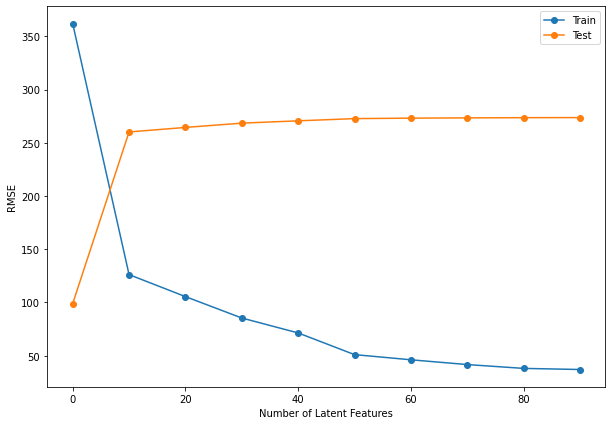

```python
#Choose the best K - number of latent features
latent_features = np.arange(0, 100, 10)
train_error = []
test_error = []

for k in latent_features:
    #Slicing the U, S, and Vt matrices to get k latent features from train and test data
    s_train_lat, u_train_lat, vt_train_lat = np.diag(s_train[:k]), u_train[:, :k], vt_train[:k, :] #take a particular portion of the matrix based on a latent features
    u_test_lat, vt_test_lat = u_test[:, :k], vt_test[:k, :]

    #Regenerating train and test interaction matrices using k latent features
    #interactions_matrix_train_preds = np.around(np.matmul(np.matmul(u_train_lat, s_train_lat), vt_train_lat))
    #interactions_matrix_test_preds = np.around(np.matmul(np.matmul(u_test_lat, s_train_lat), vt_test_lat))
    interactions_matrix_train_preds = np.dot(np.dot(u_train_lat, s_train_lat), vt_train_lat)
    interactions_matrix_test_preds = np.dot(np.dot(u_test_lat, s_train_lat), vt_test_lat)


    #Calculating the actual and predicted *number of unique users* for each song in the training data
    #*number of interactions*
    #!!!To improve inside interaction matrix can be sum of (normalized number of total interactions by song_id) +
    # +(normalized number of unique users interacted with this song).

    num_unique_users_interacted_train = interactions_matrix_train.sum(axis=0)   #was mean, !!would prefer my variant above - but calculation is time consuming
    num_unique_users_interacted_train_pred = interactions_matrix_train_preds.sum(axis=0)

    #Calculating the actual and predicted **number of unique users** for each song in the test data
    #*number of interactions*
    num_unique_users_interacted_test = interactions_matrix_test.sum(axis=0)
    num_unique_users_interacted_test_pred = interactions_matrix_test_preds.sum(axis=0)

    #Calculating train and test RMSE
    train_rmse = mean_squared_error(num_unique_users_interacted_train, num_unique_users_interacted_train_pred, squared=False)
    test_rmse = mean_squared_error(num_unique_users_interacted_test, num_unique_users_interacted_test_pred, squared=False)

    train_error.append(train_rmse)
    test_error.append(test_rmse)

#Plotting train and test RMSE
plt.figure(figsize=(10,7))
plt.plot(latent_features, train_error, label='Train', marker='o');
plt.plot(latent_features, test_error, label='Test', marker='o');
plt.xlabel('Number of Latent Features');
plt.ylabel('RMSE');
plt.legend();
```

```python
vt_train.shape
```

```
(4991, 4991)
```

#### **Observations and Insights:**

Let us now reconstruct the matrices using the number of latent features selected above

```python
k = 6
s_train_lat, u_train_lat, vt_train_lat = np.diag(s_train[:k]), u_train[:, :k], vt_train[:k, :]
u_test_lat, vt_test_lat = u_test[:, :k], vt_test[:k, :]
```

```python
vt_train_lat.shape
```

```
(6, 4991)
```

```python
interactions_matrix_train_preds = np.dot(np.dot(u_train_lat, s_train_lat), vt_train_lat)
interactions_matrix_test_preds = np.dot(np.dot(u_test_lat, s_train_lat), vt_test_lat)
```

```python
interactions_matrix_train_preds_SVD=pd.DataFrame(interactions_matrix_train_preds, index = match_idx, columns=match_cols)
interactions_matrix_train_preds_SVD.index.names = ["user_id"]
interactions_matrix_train_preds_SVD.columns.names = ["song_id"]
interactions_matrix_train_preds_SVD
```

| song_id user_id | 1 | 4 | 5 | 11 | 14 | 15 | 16 | 17 | 20 | 21 | ... | 9976 | 9977 | 9981 | 9983 | 9988 | 9989 | 9992 | 9994 | 9995 | 9996 |
| --- | --- | --- | --- | --- | --- | --- | --- | --- | --- | --- | --- | --- | --- | --- | --- | --- | --- | --- | --- | --- | --- |
| 11 | 0.000528 | 0.000135 | 0.000366 | 0.000159 | 0.000096 | 0.000173 | 0.001389 | 0.000177 | 0.000661 | 0.002065 | ... | 0.000245 | 0.000610 | 0.001098 | 0.000306 | 0.000138 | 0.000318 | 0.000092 | 0.000960 | 0.000421 | 0.000059 |
| 17 | 0.000489 | 0.000422 | 0.001801 | 0.000626 | 0.000209 | 0.000304 | 0.002744 | 0.000651 | 0.001246 | 0.007732 | ... | 0.000389 | 0.001448 | 0.003595 | 0.000596 | 0.000411 | 0.000572 | 0.000479 | 0.001341 | 0.000696 | 0.000099 |
| 32 | 0.011012 | 0.003991 | 0.014367 | 0.005433 | 0.002912 | 0.004426 | 0.032764 | 0.006693 | 0.016925 | 0.065727 | ... | 0.006185 | 0.018718 | 0.034493 | 0.006909 | 0.005805 | 0.008778 | 0.004073 | 0.021074 | 0.010275 | 0.001554 |
| 42 | 0.009967 | 0.007591 | 0.029858 | 0.010665 | 0.003993 | 0.006470 | 0.049554 | 0.012303 | 0.022331 | 0.131859 | ... | 0.007280 | 0.026877 | 0.062686 | 0.010431 | 0.009863 | 0.010647 | 0.008424 | 0.025047 | 0.013411 | 0.002242 |
| 57 | 0.002987 | 0.001276 | 0.005906 | 0.002050 | 0.001024 | 0.001165 | 0.009446 | 0.002392 | 0.005546 | 0.023518 | ... | 0.002081 | 0.006612 | 0.013358 | 0.002593 | 0.001740 | 0.003086 | 0.001632 | 0.005917 | 0.003061 | 0.000402 |
| ... | ... | ... | ... | ... | ... | ... | ... | ... | ... | ... | ... | ... | ... | ... | ... | ... | ... | ... | ... | ... | ... |
| 76307 | 0.002010 | 0.000772 | 0.003465 | 0.001212 | 0.000617 | 0.000736 | 0.006094 | 0.001403 | 0.003470 | 0.014089 | ... | 0.001320 | 0.003965 | 0.008277 | 0.001792 | 0.000974 | 0.001901 | 0.000945 | 0.003897 | 0.001954 | 0.000252 |
| 76331 | 0.009695 | 0.003340 | 0.011436 | 0.004413 | 0.002445 | 0.003861 | 0.028094 | 0.005534 | 0.014355 | 0.053778 | ... | 0.005243 | 0.015672 | 0.027918 | 0.005624 | 0.004985 | 0.007394 | 0.003270 | 0.018311 | 0.008841 | 0.001361 |
| 76333 | 0.001800 | 0.000560 | 0.002025 | 0.000772 | 0.000414 | 0.000607 | 0.005076 | 0.000854 | 0.002630 | 0.009441 | ... | 0.000954 | 0.002686 | 0.004919 | 0.001090 | 0.000604 | 0.001325 | 0.000526 | 0.003389 | 0.001553 | 0.000204 |
| 76342 | 0.001865 | 0.000890 | 0.002706 | 0.001072 | 0.000524 | 0.001024 | 0.006601 | 0.001453 | 0.002921 | 0.013582 | ... | 0.001018 | 0.003373 | 0.006510 | 0.001170 | 0.001531 | 0.001423 | 0.000841 | 0.003834 | 0.001966 | 0.000372 |
| 76347 | 0.000356 | 0.000167 | 0.000718 | 0.000253 | 0.000119 | 0.000154 | 0.001224 | 0.000295 | 0.000661 | 0.002989 | ... | 0.000240 | 0.000776 | 0.001601 | 0.000301 | 0.000222 | 0.000352 | 0.000199 | 0.000734 | 0.000376 | 0.000053 |

5000 rows × 4991 columns

**Now, let's recreate the original interaction matrix with the same number of latent features and create a function to recommend the top songs**

```python
# Singular Value Decomposition
U, sigma, Vt = u[:, :k], np.diag(s[:k]), vt[:k, :]
print("U= ", U)
print("Sigma= ",sigma)
print("Vt= ",Vt)

# Construct diagonal array in SVD
#sigma = np.diag(sigma)
```

```
U=  [[-2.09200442e-06  2.12468767e-04 -1.47746220e-05 -1.06195628e-04
  -2.69661053e-04  2.11598878e-04]
 [-1.20821578e-07  7.14855260e-04 -6.31876263e-05 -4.50204893e-04
  -1.10841632e-04  1.20369033e-03]
 [-3.86347817e-07  2.87767616e-03 -2.03240300e-04 -6.38561410e-04
  -1.86296701e-03  7.55131753e-03]
 ...
 [-1.82969916e-07  7.13134729e-04 -5.64951765e-05 -2.77846711e-04
  -6.67375966e-04  1.89032731e-03]
 [-1.35301094e-06  9.23363066e-04 -5.20871277e-05 -7.14393076e-05
  -2.29095645e-04  8.97098177e-04]
 [-5.81527026e-08  1.20626702e-04  8.90423392e-07 -6.41454732e-05
  -1.05541364e-04  5.33621859e-04]]
Sigma=  [[2213.58217036    0.            0.            0.            0.
     0.        ]
 [   0.          924.2009621     0.            0.            0.
     0.        ]
 [   0.            0.          757.97182774    0.            0.
     0.        ]
 [   0.            0.            0.          558.34016225    0.
     0.        ]
 [   0.            0.            0.            0.          479.77992878
     0.        ]
 [   0.            0.            0.            0.            0.
   437.73865692]]
Vt=  [[-9.53630372e-07 -1.60300539e-06 -1.76892913e-06 ... -2.92833076e-07
  -3.28957346e-07 -9.81842507e-08]
 [ 6.41566843e-04  8.84388688e-04  1.87854137e-03 ...  1.79471846e-03
   1.20296346e-03  3.66426749e-04]
 [-1.60089351e-05 -9.60420057e-05  4.09502074e-04 ... -1.53593215e-04
  -9.18042124e-05 -1.91876280e-05]
 [ 1.01142582e-04  3.22768156e-04 -1.30053553e-03 ... -3.99247797e-04
   4.46352094e-04  3.08645782e-04]
 [-4.61292998e-04 -4.48004083e-04 -5.70967699e-04 ... -5.47753061e-04
  -2.81961226e-04 -7.01728552e-05]
 [ 1.48250564e-03  1.00384859e-03  4.30035110e-03 ...  1.83922571e-04
   8.84609223e-04  2.12025014e-04]]
```

```python
Sigma_df = pd.DataFrame(sigma)
Sigma_df
Sigma_diag_array = np.diag(Sigma_df)
```

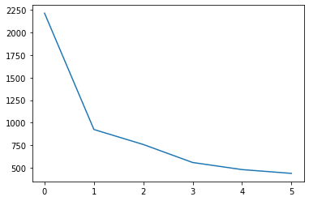

```python
plt.plot(Sigma_diag_array) # plotting by columns
plt.show()
```

```python
all_user_predicted_counts = np.dot(np.dot(U, sigma), Vt)

# Predicted ratings
preds_df = pd.DataFrame(abs(all_user_predicted_counts), columns = interactions_matrix_SVD_replace.columns, index = interactions_matrix_SVD_replace.index)
preds_df
```

| song_id user_id | 1 | 4 | 5 | 11 | 14 | 15 | 16 | 17 | 20 | 21 | ... | 9976 | 9977 | 9981 | 9983 | 9988 | 9989 | 9992 | 9994 | 9995 | 9996 |
| --- | --- | --- | --- | --- | --- | --- | --- | --- | --- | --- | --- | --- | --- | --- | --- | --- | --- | --- | --- | --- | --- |
| 11 | 0.000317 | 0.000307 | 0.000914 | 0.000274 | 0.000129 | 0.000164 | 0.001309 | 0.000367 | 0.000536 | 0.004118 | ... | 0.000269 | 0.000714 | 0.002597 | 0.000504 | 0.000287 | 0.000322 | 0.000222 | 0.000466 | 0.000329 | 0.000083 |
| 17 | 0.001205 | 0.001061 | 0.003845 | 0.001077 | 0.000515 | 0.000434 | 0.004728 | 0.001397 | 0.002178 | 0.016424 | ... | 0.000905 | 0.002961 | 0.009514 | 0.001241 | 0.000968 | 0.001272 | 0.000901 | 0.001419 | 0.001168 | 0.000281 |
| 32 | 0.006985 | 0.005970 | 0.020122 | 0.005454 | 0.002887 | 0.001762 | 0.022598 | 0.009079 | 0.011336 | 0.081127 | ... | 0.005425 | 0.016296 | 0.052629 | 0.007632 | 0.005914 | 0.007593 | 0.005056 | 0.006037 | 0.006230 | 0.001631 |
| 42 | 0.013163 | 0.011589 | 0.041454 | 0.011592 | 0.005601 | 0.004660 | 0.050857 | 0.015673 | 0.023521 | 0.176287 | ... | 0.009921 | 0.032177 | 0.103199 | 0.013613 | 0.010833 | 0.013911 | 0.009827 | 0.015108 | 0.012721 | 0.003107 |
| 57 | 0.003172 | 0.002450 | 0.009157 | 0.002301 | 0.001311 | 0.000202 | 0.008002 | 0.003627 | 0.004886 | 0.034056 | ... | 0.002475 | 0.007171 | 0.024065 | 0.003547 | 0.001946 | 0.003655 | 0.002243 | 0.001781 | 0.002350 | 0.000577 |
| ... | ... | ... | ... | ... | ... | ... | ... | ... | ... | ... | ... | ... | ... | ... | ... | ... | ... | ... | ... | ... | ... |
| 76307 | 0.003031 | 0.002375 | 0.008383 | 0.002108 | 0.001224 | 0.000226 | 0.007252 | 0.003265 | 0.004413 | 0.030963 | ... | 0.002511 | 0.006476 | 0.023603 | 0.004247 | 0.001727 | 0.003498 | 0.002068 | 0.001845 | 0.002184 | 0.000531 |
| 76331 | 0.006663 | 0.006268 | 0.019387 | 0.005653 | 0.002765 | 0.003028 | 0.026856 | 0.009679 | 0.011638 | 0.084695 | ... | 0.005123 | 0.016137 | 0.050029 | 0.007000 | 0.007219 | 0.006777 | 0.004968 | 0.007995 | 0.007025 | 0.001910 |
| 76333 | 0.001782 | 0.001511 | 0.005164 | 0.001394 | 0.000736 | 0.000428 | 0.005675 | 0.002156 | 0.002874 | 0.020782 | ... | 0.001408 | 0.004096 | 0.013710 | 0.002123 | 0.001377 | 0.001952 | 0.001273 | 0.001579 | 0.001550 | 0.000392 |
| 76342 | 0.001177 | 0.001189 | 0.003390 | 0.001044 | 0.000487 | 0.000718 | 0.005413 | 0.001897 | 0.002113 | 0.015664 | ... | 0.000901 | 0.002919 | 0.008725 | 0.001197 | 0.001528 | 0.001132 | 0.000895 | 0.001686 | 0.001391 | 0.000392 |
| 76347 | 0.000438 | 0.000344 | 0.001290 | 0.000329 | 0.000182 | 0.000047 | 0.001198 | 0.000504 | 0.000693 | 0.004902 | ... | 0.000338 | 0.001004 | 0.003341 | 0.000478 | 0.000281 | 0.000498 | 0.000314 | 0.000285 | 0.000339 | 0.000083 |

5000 rows × 5000 columns

```python
preds_df.max()
```

```
song_id
1       0.413155
4       0.287065
5       1.035335
11      0.362833
14      0.165402
          ...
9989    0.529503
9992    0.282925
9994    0.908285
9995    0.412335
9996    0.129953
Length: 5000, dtype: float64
```

```python
#Build the function to recommend top songs

def recommend_songs(user_idx, interactions_matrix, preds_df, num_recommendations):

    # Get and sort the user's ratings from the actual and predicted interaction matrix
    sorted_user_ratings = interactions_matrix.loc[user_idx].sort_values(ascending=False) #how much time our user listened his songs
    sorted_user_predictions = preds_df.loc[user_idx].sort_values(ascending=False) #prediction - how much time our user is going to listen all songs

    #Creating a dataframe with actual and predicted ratings columns
    temp = pd.concat([sorted_user_ratings, sorted_user_predictions], axis=1)
    temp.index.name = 'Recommended Songs'
    temp.columns = ['user_ratings', 'user_predictions']
    #print("temp=", temp)

    #Filtering the dataframe where actual ratings are 0 which implies that the user has not interacted with that movie
    #print(temp.loc[temp.user_ratings != 0])
    temp = temp.loc[temp.user_ratings == 0]  ###!!!!!Добавить нужно былоа!!!!

    #Recommending movies with top predicted ratings
    temp = temp.sort_values('user_predictions', ascending=False)
    #print("temp sorted", temp)
    #temp["title"]=""
    #temp["title"]=temp.index.map(df["title"])
    #print("temp final = ", temp)
    #print('\nBelow are the recommended songs for user(user_id = {}):\n'.format(user_idx))
    #print(temp['user_predictions'].head(num_recommendations))

    return temp[:num_recommendations].index.tolist()
```

```python
#Recommend songs to some user using the function defined above
user_index = 32
num_recommendations = 10

recommend_songs(user_index, interactions_matrix_SVD_replace, preds_df, num_recommendations)
```

```
[352, 5399, 2220, 8858, 5531, 7913, 3714, 8582, 605, 7796]
```

```python
#Recommend songs to some user using the function defined above
user_index = 11
num_recommendations = 5

rec  =recommend_songs(user_index, interactions_matrix_SVD_replace, preds_df, num_recommendations)
print(rec)
song_names_from_song_id(rec)
```

```
[4545, 2220, 352, 9859, 5531]

Recommended Songs:
```

| song_id | count_sum | play_count | title | release | artist_name | year |
| --- | --- | --- | --- | --- | --- | --- |
| 4545 | 2575 | 541 | I'll Be Your Man | The Big Come Up | The Black Keys | 2002 |
| 2220 | 31036 | 8277 | Sehr kosmisch | Musik von Harmonia | Harmonia | 0 |
| 352 | 26663 | 6949 | Dog Days Are Over (Radio Edit) | Now That's What I Call Music! 75 | Florence + The Machine | 0 |
| 9859 | 1997 | 125 | The Quest | A Taste Of Extreme Divinity | HYPOCRISY | 2009 |
| 5531 | 22100 | 5841 | Secrets | Waking Up | OneRepublic | 2009 |

```python
#Recommend songs to some user using the function defined above
user_index = 32542
num_recommendations = 10

rec = recommend_songs(user_index, interactions_matrix_SVD_replace, preds_df, num_recommendations)
print(rec)
song_names_from_song_id(rec)
```

```
[5399, 8858, 3714, 1664, 2220, 393, 8582, 6716, 605, 7796]

Recommended Songs:
```

| song_id | count_sum | play_count | title | release | artist_name | year |
| --- | --- | --- | --- | --- | --- | --- |
| 5399 | 8645 | 1918 | Strut (1993 Digital Remaster) | The World Of Sheena Easton - The Singles | Sheena Easton | 0 |
| 8858 | 1495 | 179 | Teardrop | Pure Chillout / Lounge Music Vol. 2 - The Most... | Underworld | 0 |
| 3714 | 1822 | 474 | I Get Joy | I Get Joy - Single | Coko featuring Kirk Franklin | 2006 |
| 1664 | 31153 | 5385 | Horn Concerto No. 4 in E flat K495: II. Romanc... | Mozart - Eine kleine Nachtmusik | Barry Tuckwell/Academy of St Martin-in-the-Fie... | 0 |
| 2220 | 31036 | 8277 | Sehr kosmisch | Musik von Harmonia | Harmonia | 0 |
| 393 | 5501 | 1038 | Nah! | Up! | Shania Twain | 2002 |
| 8582 | 11070 | 3976 | Use Somebody | Hitzone 49 | Kings Of Leon | 2008 |
| 6716 | 6931 | 1280 | Better To Reign In Hell | Damnation And A Day | Cradle Of Filth | 2003 |
| 605 | 9449 | 2976 | Lucky (Album Version) | We Sing. We Dance. We Steal Things. | Jason Mraz & Colbie Caillat | 0 |
| 7796 | 7178 | 2409 | Love Story | Fearless | Taylor Swift | 2008 |

```python
#Recommend songs to some user using the function defined above
user_index = 42239
num_recommendations = 10

rec=recommend_songs(user_index, interactions_matrix_SVD_replace, preds_df, num_recommendations)
print(rec)
song_names_from_song_id(rec)
```

```
[317, 5399, 6716, 617, 3462, 7416, 3567, 5291, 8029, 6378]

Recommended Songs:
```

| song_id | count_sum | play_count | title | release | artist_name | year |
| --- | --- | --- | --- | --- | --- | --- |
| 317 | 49253 | 7032 | Undo | Vespertine Live | Björk | 2001 |
| 5399 | 8645 | 1918 | Strut (1993 Digital Remaster) | The World Of Sheena Easton - The Singles | Sheena Easton | 0 |
| 6716 | 6931 | 1280 | Better To Reign In Hell | Damnation And A Day | Cradle Of Filth | 2003 |
| 617 | 16674 | 3129 | Sincerité Et Jalousie | Simple Et Funky | Alliance Ethnik | 0 |
| 3462 | 4271 | 1476 | If I Had You | For Your Entertainment (Deluxe Version) | Adam Lambert | 2009 |
| 7416 | 41418 | 6145 | Revelry | Only By The Night | Kings Of Leon | 2008 |
| 3567 | 5717 | 2071 | Supermassive Black Hole (Album Version) | Supermassive Black Hole | Muse | 0 |
| 5291 | 6923 | 2070 | Bring Me To Life | Fallen | Evanescence | 2003 |
| 8029 | 11410 | 2306 | I CAN'T GET STARTED | It's The Time | Ron Carter | 0 |
| 6378 | 6708 | 1275 | Sayonara-Nostalgia | Yuugata Generation | Base Ball Bear | 2005 |

Finally, we can **calculate the RMSE** for the final average predicted play_counts using the model-based recommendation system.

```python
#Create a dataframe containing average actual and average predicted play_counts of the songs and calculate the RMSE
rmse_df = pd.concat([interactions_matrix_SVD_replace.mean(), preds_df.mean()], axis=1)
rmse_df.columns = ['Avg_actual_play_counts', 'Avg_predicted_play_counts']
rmse_df
```

| song_id | Avg_actual_play_counts | Avg_predicted_play_counts |
| --- | --- | --- |
| 1 | 0.0378 | 0.006223 |
| 4 | 0.0242 | 0.006710 |
| 5 | 0.0462 | 0.017958 |
| 11 | 0.0272 | 0.005649 |
| 14 | 0.0102 | 0.002554 |
| ... | ... | ... |
| 9989 | 0.0430 | 0.005820 |
| 9992 | 0.0182 | 0.004838 |
| 9994 | 0.0300 | 0.010592 |
| 9995 | 0.0204 | 0.008181 |
| 9996 | 0.0164 | 0.002413 |

5000 rows × 2 columns

```python
r2_score(rmse_df.Avg_actual_play_counts, rmse_df.Avg_predicted_play_counts)
```

```
0.7313744943183316
```

```python
RMSE = mean_squared_error(rmse_df['Avg_actual_play_counts'], rmse_df['Avg_predicted_play_counts'], squared=False)
print('\nRMSE SVD Model = {} \n'.format(RMSE))
```

```
RMSE SVD Model = 0.039765655332435666
```

## **Evaluation (Precision/Recall) of the Matrix Factorization Collaborative Filtering

### **Preparing Train and Test Sets and Interaction Matrices - for evaluation of each model**

```python
#Probably DONT NEED
#Split Data into Train and Test DataSets 80/20
df_train, df_test = train_test_split(df_small, test_size=0.2, random_state=10) #can use df_small instead of df

print(df_train.shape, df_test.shape)

#create train and test interaction matrices
interactions_matrix_train = df_train.pivot(index='user_id', columns='song_id', values='play_count')
interactions_matrix_train.fillna(0, inplace=True)

interactions_matrix_test = df_test.pivot(index='user_id', columns='song_id', values='play_count')
interactions_matrix_test.fillna(0, inplace=True)

print(interactions_matrix_train.shape, interactions_matrix_test.shape)
```

```
(365081, 7) (91271, 7)
(5000, 5000) (5000, 4991)
```

```python
#PROBABLY DONT NEED
#Finding intersection between these matrices
#train and test matrices should have the same users, the same songs (to be comparable)

#Finding unique users in train and test data and then taking their intersection i.e. common users in train and test data
train_idx = set(interactions_matrix_train.index)
test_idx = set(interactions_matrix_test.index)
match_idx = train_idx.intersection(test_idx)
match_idx=sorted(match_idx)

#Finding unique songs in train and test data and then taking their intersection i.e. common movies in train and test data
train_songs = set(interactions_matrix_train.columns)
test_songs = set(interactions_matrix_test.columns)
match_cols = train_songs.intersection(test_songs)
match_cols=sorted(match_cols)

#Selecting only common users and songs from the test interaction matrix
interactions_matrix_test = interactions_matrix_test.loc[match_idx, match_cols]
interactions_matrix_test.shape

#Selecting only common users and songs from the TRAIN interaction matrix
interactions_matrix_train = interactions_matrix_train.loc[match_idx, match_cols]
interactions_matrix_train.shape
```

```
(5000, 4991)
```

```python
interactions_matrix_test
```

| song_id user_id | 1 | 4 | 5 | 11 | 14 | 15 | 16 | 17 | 20 | 21 | ... | 9976 | 9977 | 9981 | 9983 | 9988 | 9989 | 9992 | 9994 | 9995 | 9996 |
| --- | --- | --- | --- | --- | --- | --- | --- | --- | --- | --- | --- | --- | --- | --- | --- | --- | --- | --- | --- | --- | --- |
| 11 | 0.0 | 0.0 | 0.0 | 0.0 | 0.0 | 0.0 | 0.0 | 0.0 | 0.0 | 0.0 | ... | 0.0 | 0.0 | 0.0 | 0.0 | 0.0 | 0.0 | 0.0 | 0.0 | 0.0 | 0.0 |
| 17 | 0.0 | 0.0 | 0.0 | 0.0 | 0.0 | 0.0 | 0.0 | 0.0 | 0.0 | 0.0 | ... | 0.0 | 0.0 | 0.0 | 0.0 | 0.0 | 0.0 | 0.0 | 0.0 | 0.0 | 0.0 |
| 32 | 0.0 | 0.0 | 0.0 | 0.0 | 0.0 | 0.0 | 0.0 | 0.0 | 0.0 | 0.0 | ... | 0.0 | 0.0 | 0.0 | 0.0 | 0.0 | 0.0 | 0.0 | 0.0 | 0.0 | 0.0 |
| 42 | 0.0 | 0.0 | 0.0 | 0.0 | 0.0 | 0.0 | 0.0 | 0.0 | 0.0 | 0.0 | ... | 0.0 | 0.0 | 0.0 | 0.0 | 0.0 | 0.0 | 0.0 | 0.0 | 0.0 | 0.0 |
| 57 | 0.0 | 0.0 | 0.0 | 0.0 | 0.0 | 0.0 | 0.0 | 0.0 | 0.0 | 0.0 | ... | 0.0 | 0.0 | 0.0 | 0.0 | 0.0 | 0.0 | 0.0 | 0.0 | 0.0 | 0.0 |
| ... | ... | ... | ... | ... | ... | ... | ... | ... | ... | ... | ... | ... | ... | ... | ... | ... | ... | ... | ... | ... | ... |
| 76307 | 0.0 | 0.0 | 0.0 | 0.0 | 0.0 | 0.0 | 0.0 | 0.0 | 0.0 | 0.0 | ... | 0.0 | 0.0 | 0.0 | 0.0 | 0.0 | 0.0 | 0.0 | 0.0 | 0.0 | 0.0 |
| 76331 | 0.0 | 0.0 | 0.0 | 0.0 | 0.0 | 0.0 | 0.0 | 0.0 | 0.0 | 0.0 | ... | 0.0 | 0.0 | 0.0 | 0.0 | 0.0 | 0.0 | 0.0 | 0.0 | 0.0 | 0.0 |
| 76333 | 0.0 | 0.0 | 0.0 | 0.0 | 0.0 | 0.0 | 0.0 | 0.0 | 0.0 | 0.0 | ... | 0.0 | 0.0 | 0.0 | 0.0 | 0.0 | 0.0 | 0.0 | 0.0 | 0.0 | 0.0 |
| 76342 | 0.0 | 0.0 | 0.0 | 0.0 | 0.0 | 0.0 | 0.0 | 0.0 | 0.0 | 0.0 | ... | 0.0 | 0.0 | 0.0 | 0.0 | 0.0 | 0.0 | 0.0 | 0.0 | 0.0 | 0.0 |
| 76347 | 0.0 | 0.0 | 0.0 | 0.0 | 0.0 | 0.0 | 0.0 | 0.0 | 0.0 | 0.0 | ... | 0.0 | 0.0 | 0.0 | 0.0 | 0.0 | 0.0 | 0.0 | 0.0 | 0.0 | 0.0 |

5000 rows × 4991 columns

```python
#INTERACTION MATRIX FOR MATRIX FACTORIZATIN COLLABORATIVE FILTERING - PREDICTION on TRAIN SET
#==============================================================================================
interactions_matrix_train_preds_SVD.index.names = ["user_id"]
interactions_matrix_train_preds_SVD.columns.names = ["song_id"]
interactions_matrix_train_preds_SVD
```

| song_id user_id | 1 | 4 | 5 | 11 | 14 | 15 | 16 | 17 | 20 | 21 | ... | 9976 | 9977 | 9981 | 9983 | 9988 | 9989 | 9992 | 9994 | 9995 | 9996 |
| --- | --- | --- | --- | --- | --- | --- | --- | --- | --- | --- | --- | --- | --- | --- | --- | --- | --- | --- | --- | --- | --- |
| 11 | 0.000528 | 0.000135 | 0.000366 | 0.000159 | 0.000096 | 0.000173 | 0.001389 | 0.000177 | 0.000661 | 0.002065 | ... | 0.000245 | 0.000610 | 0.001098 | 0.000306 | 0.000138 | 0.000318 | 0.000092 | 0.000960 | 0.000421 | 0.000059 |
| 17 | 0.000489 | 0.000422 | 0.001801 | 0.000626 | 0.000209 | 0.000304 | 0.002744 | 0.000651 | 0.001246 | 0.007732 | ... | 0.000389 | 0.001448 | 0.003595 | 0.000596 | 0.000411 | 0.000572 | 0.000479 | 0.001341 | 0.000696 | 0.000099 |
| 32 | 0.011012 | 0.003991 | 0.014367 | 0.005433 | 0.002912 | 0.004426 | 0.032764 | 0.006693 | 0.016925 | 0.065727 | ... | 0.006185 | 0.018718 | 0.034493 | 0.006909 | 0.005805 | 0.008778 | 0.004073 | 0.021074 | 0.010275 | 0.001554 |
| 42 | 0.009967 | 0.007591 | 0.029858 | 0.010665 | 0.003993 | 0.006470 | 0.049554 | 0.012303 | 0.022331 | 0.131859 | ... | 0.007280 | 0.026877 | 0.062686 | 0.010431 | 0.009863 | 0.010647 | 0.008424 | 0.025047 | 0.013411 | 0.002242 |
| 57 | 0.002987 | 0.001276 | 0.005906 | 0.002050 | 0.001024 | 0.001165 | 0.009446 | 0.002392 | 0.005546 | 0.023518 | ... | 0.002081 | 0.006612 | 0.013358 | 0.002593 | 0.001740 | 0.003086 | 0.001632 | 0.005917 | 0.003061 | 0.000402 |
| ... | ... | ... | ... | ... | ... | ... | ... | ... | ... | ... | ... | ... | ... | ... | ... | ... | ... | ... | ... | ... | ... |
| 76307 | 0.002010 | 0.000772 | 0.003465 | 0.001212 | 0.000617 | 0.000736 | 0.006094 | 0.001403 | 0.003470 | 0.014089 | ... | 0.001320 | 0.003965 | 0.008277 | 0.001792 | 0.000974 | 0.001901 | 0.000945 | 0.003897 | 0.001954 | 0.000252 |
| 76331 | 0.009695 | 0.003340 | 0.011436 | 0.004413 | 0.002445 | 0.003861 | 0.028094 | 0.005534 | 0.014355 | 0.053778 | ... | 0.005243 | 0.015672 | 0.027918 | 0.005624 | 0.004985 | 0.007394 | 0.003270 | 0.018311 | 0.008841 | 0.001361 |
| 76333 | 0.001800 | 0.000560 | 0.002025 | 0.000772 | 0.000414 | 0.000607 | 0.005076 | 0.000854 | 0.002630 | 0.009441 | ... | 0.000954 | 0.002686 | 0.004919 | 0.001090 | 0.000604 | 0.001325 | 0.000526 | 0.003389 | 0.001553 | 0.000204 |
| 76342 | 0.001865 | 0.000890 | 0.002706 | 0.001072 | 0.000524 | 0.001024 | 0.006601 | 0.001453 | 0.002921 | 0.013582 | ... | 0.001018 | 0.003373 | 0.006510 | 0.001170 | 0.001531 | 0.001423 | 0.000841 | 0.003834 | 0.001966 | 0.000372 |
| 76347 | 0.000356 | 0.000167 | 0.000718 | 0.000253 | 0.000119 | 0.000154 | 0.001224 | 0.000295 | 0.000661 | 0.002989 | ... | 0.000240 | 0.000776 | 0.001601 | 0.000301 | 0.000222 | 0.000352 | 0.000199 | 0.000734 | 0.000376 | 0.000053 |

5000 rows × 4991 columns

```python
#ALL ACTUAL SONGS are INCLUDED ======FROM preds_df and full interaction matrix and interactions_matrix_SVD
#Counting Precision and Recall for EACH USER -> into the Precision_matrix, Recall_matrix - for THIS MODEL (SVD)

k_max = 41
columns_k = np.arange(10,k_max,10) #can be np.arange(5,41,5)

Precision_Matrix_MODEL_SVD = pd.DataFrame(columns=columns_k, index = match_idx) #Precision by users for k
Recall_Matrix_MODEL_SVD = pd.DataFrame(columns=columns_k, index = match_idx) #Recall by users for k


def non_match_elements(list_a, list_b):
    non_match = []
    for i in list_a:
        if i not in list_b:
            non_match.append(i)
    return non_match

def match_elements(list_a, list_b):
    match = []
    for i in list_a:
        if i in list_b:
            match.append(i)
    return match


for user in np.array(match_idx):  #([11, 17]): # match_idx: #for each user
    #print("USER=============", user)

    user_vector_actual=interactions_matrix_SVD.loc[user] #actual from testing set
    actual_v = user_vector_actual.drop(user_vector_actual[user_vector_actual == 0].index).sort_values(ascending=False)
    actual=actual_v.index.tolist()

    user_vector_predicted = preds_df.loc[user] #predicion from training set
    predicted_v = user_vector_predicted.drop(user_vector_predicted[user_vector_predicted == 0].index).sort_values(ascending=False)
    predicted=predicted_v.index.tolist()


    for k in columns_k:
        #print("\nk=",k)
        #print("\n++++predicted[:k]",predicted[:k])
        #print("\n\n=====actual",actual)
        match = match_elements(predicted[:k], actual) #list of true positives
        #print("\nMATCH",match)
        precision = len(match)/k
        #print("\nprecision",precision)
        #put prcision in matrix at row = user, column = k
        Precision_Matrix_MODEL_SVD.at[user, k] = precision
        #recall = len(match)/len(actual.index.tolist())
        recall = len(match)/len(actual)
        #print("\nrecall",recall)
        #put recall in matrix
        Recall_Matrix_MODEL_SVD.at[user, k] = recall
```

```python
Precision_Matrix_MODEL_SVD
```

|  | 10 | 20 | 30 | 40 |
| --- | --- | --- | --- | --- |
| 11 | 0.0 | 0.0 | 0.0 | 0.0 |
| 17 | 0.2 | 0.1 | 0.066667 | 0.05 |
| 32 | 0.1 | 0.05 | 0.033333 | 0.025 |
| 42 | 0.0 | 0.0 | 0.066667 | 0.05 |
| 57 | 0.0 | 0.0 | 0.033333 | 0.025 |
| ... | ... | ... | ... | ... |
| 76307 | 0.0 | 0.0 | 0.0 | 0.025 |
| 76331 | 0.0 | 0.0 | 0.066667 | 0.075 |
| 76333 | 0.1 | 0.05 | 0.033333 | 0.025 |
| 76342 | 0.0 | 0.0 | 0.0 | 0.025 |
| 76347 | 0.0 | 0.0 | 0.0 | 0.0 |

5000 rows × 4 columns

```python
Mean_Precision_Matrix_SVD = Precision_Matrix_MODEL_SVD.mean()
Mean_Precision_Matrix_SVD
```

```
10    0.22880
20    0.19019
30    0.17290
40    0.16214
dtype: float64
```

```python
Recall_Matrix_MODEL_SVD
```

|  | 10 | 20 | 30 | 40 |
| --- | --- | --- | --- | --- |
| 11 | 0.0 | 0.0 | 0.0 | 0.0 |
| 17 | 0.020833 | 0.020833 | 0.020833 | 0.020833 |
| 32 | 0.014706 | 0.014706 | 0.014706 | 0.014706 |
| 42 | 0.0 | 0.0 | 0.033333 | 0.033333 |
| 57 | 0.0 | 0.0 | 0.008065 | 0.008065 |
| ... | ... | ... | ... | ... |
| 76307 | 0.0 | 0.0 | 0.0 | 0.009346 |
| 76331 | 0.0 | 0.0 | 0.019231 | 0.028846 |
| 76333 | 0.02 | 0.02 | 0.02 | 0.02 |
| 76342 | 0.0 | 0.0 | 0.0 | 0.012346 |
| 76347 | 0.0 | 0.0 | 0.0 | 0.0 |

5000 rows × 4 columns

```python
Mean_Recall_Matrix_SVD = Recall_Matrix_MODEL_SVD.mean()
Mean_Recall_Matrix_SVD
```

```
10    0.025302
20    0.041290
30    0.055810
40    0.069451
dtype: float64
```

### **Clustering-Based Recommendation Systems**

In clustering-based recommendation systems, we explore the similarities and differences in people's tastes in songs based on how they rate different songs. We cluster similar users together and recommend songs to a user based on ratings from other users in the same cluster.

First, let's choose the optimal number of clusters i.e. K for K-means clustering

# I am going to use the same matrix 5000 x 5000 of top5000 users and top 5000 song_ids.

interactions_matrix_replace

#### **Choosing an optimal K**

We will try different values of k and calculate the **sum of squared errors (SSE) for each k**, then we will use the **elbow plot** to choose the optimal value of k

# Find the best k using the elbow plot

```python
sse = [] #Empty list to store the sum of squared errors for each value of k

for k in range(2, 40, 3):
    kmeans = KMeans(n_clusters=k, random_state=0).fit(interactions_matrix_replace)
    sse.append(kmeans.inertia_)
```

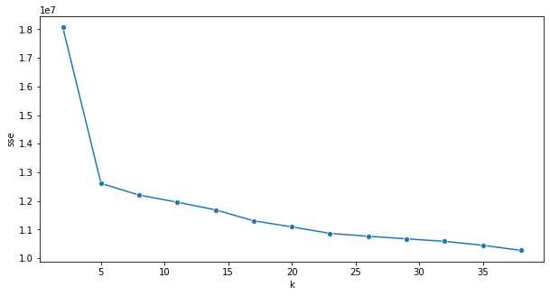

```python
#Plotting elbow plot

error_data = pd.DataFrame({'k':range(2, 40, 3), 'sse':sse})

plt.figure(figsize=(10,5))

sns.lineplot(x='k', y='sse', data=error_data, marker='o')

plt.show()
```

Now, let's cluster each user using K-Means clustering with k=6. We will **add one column `group` with cluster labels** to the original data `most_rated_movies_1k` for each user.

```python
interactions_matrix_replace #users/songs interaction matrix 5000 top users / 5000 top song_ids
```

| song_id user_id | 1 | 4 | 5 | 11 | 14 | 15 | 16 | 17 | 20 | 21 | ... | 9976 | 9977 | 9981 | 9983 | 9988 | 9989 | 9992 | 9994 | 9995 | 9996 |
| --- | --- | --- | --- | --- | --- | --- | --- | --- | --- | --- | --- | --- | --- | --- | --- | --- | --- | --- | --- | --- | --- |
| 11 | 0.0 | 0.0 | 0.0 | 0.0 | 0.0 | 0.0 | 0.0 | 0.0 | 0.0 | 0.0 | ... | 0.0 | 0.0 | 0.0 | 0.0 | 0.0 | 0.0 | 0.0 | 0.0 | 0.0 | 0.0 |
| 17 | 0.0 | 0.0 | 0.0 | 0.0 | 0.0 | 0.0 | 0.0 | 0.0 | 0.0 | 0.0 | ... | 0.0 | 0.0 | 0.0 | 0.0 | 0.0 | 0.0 | 0.0 | 0.0 | 0.0 | 0.0 |
| 32 | 0.0 | 0.0 | 0.0 | 0.0 | 0.0 | 0.0 | 0.0 | 0.0 | 0.0 | 0.0 | ... | 0.0 | 0.0 | 0.0 | 0.0 | 0.0 | 0.0 | 0.0 | 0.0 | 0.0 | 0.0 |
| 42 | 0.0 | 0.0 | 0.0 | 0.0 | 0.0 | 0.0 | 0.0 | 0.0 | 0.0 | 0.0 | ... | 0.0 | 0.0 | 0.0 | 0.0 | 0.0 | 0.0 | 0.0 | 0.0 | 0.0 | 0.0 |
| 57 | 0.0 | 0.0 | 5.0 | 0.0 | 0.0 | 0.0 | 0.0 | 0.0 | 0.0 | 0.0 | ... | 0.0 | 0.0 | 0.0 | 0.0 | 0.0 | 0.0 | 0.0 | 0.0 | 0.0 | 0.0 |
| ... | ... | ... | ... | ... | ... | ... | ... | ... | ... | ... | ... | ... | ... | ... | ... | ... | ... | ... | ... | ... | ... |
| 76307 | 0.0 | 0.0 | 0.0 | 0.0 | 0.0 | 0.0 | 0.0 | 0.0 | 0.0 | 0.0 | ... | 0.0 | 0.0 | 0.0 | 0.0 | 0.0 | 0.0 | 0.0 | 0.0 | 0.0 | 0.0 |
| 76331 | 0.0 | 0.0 | 0.0 | 0.0 | 0.0 | 0.0 | 0.0 | 0.0 | 4.0 | 0.0 | ... | 0.0 | 0.0 | 0.0 | 0.0 | 0.0 | 0.0 | 0.0 | 0.0 | 0.0 | 0.0 |
| 76333 | 0.0 | 0.0 | 0.0 | 0.0 | 0.0 | 0.0 | 0.0 | 0.0 | 0.0 | 0.0 | ... | 0.0 | 0.0 | 0.0 | 0.0 | 0.0 | 0.0 | 0.0 | 0.0 | 0.0 | 0.0 |
| 76342 | 0.0 | 0.0 | 0.0 | 0.0 | 0.0 | 0.0 | 0.0 | 0.0 | 0.0 | 0.0 | ... | 0.0 | 0.0 | 0.0 | 0.0 | 0.0 | 0.0 | 0.0 | 0.0 | 0.0 | 0.0 |
| 76347 | 0.0 | 0.0 | 0.0 | 0.0 | 0.0 | 0.0 | 0.0 | 0.0 | 0.0 | 0.0 | ... | 0.0 | 0.0 | 0.0 | 0.0 | 0.0 | 0.0 | 0.0 | 0.0 | 0.0 | 0.0 |

5000 rows × 5000 columns

```python
k_clust = 6
```

Now let's create functions to find the most played songs and the most interacted users

```python
def find_most_played_songs(interaction_matrix, num_songs):

    #Complete the function

    #Appending the count of ratings for each movie as a row in the interaction matrix
    user_song_most_played = interactions_matrix.append(interactions_matrix.sum(), ignore_index=True)

    #Sorting the values in the interaction matrix on the basis of the appended row (sum)
    user_song_most_played_sorted = user_song_most_played.sort_values(user_song_most_played.shape[0]-1, axis=1, ascending=False)

    #Dropping the appended row from the sorted interaction matrix
    user_song_most_played_sorted.drop(user_song_most_played_sorted.tail(1).index, inplace=True)

    #Selecting top songs with the most played number
    most_played_songs = user_song_most_played_sorted.iloc[:, :num_songs]


    return most_played_songs
```

```python
#Use the function defined above to find the 30 most played songs
most_played_songs = find_most_played_songs(interactions_matrix_replace, 30)
most_played_songs
```

| song_id | 614 | 317 | 352 | 7416 | 2220 | 1664 | 6246 | 5531 | 7913 | 1334 | ... | 8092 | 8252 | 8029 | 4639 | 1118 | 6175 | 4858 | 605 | 1990 | 6222 |
| --- | --- | --- | --- | --- | --- | --- | --- | --- | --- | --- | --- | --- | --- | --- | --- | --- | --- | --- | --- | --- | --- |
| 0 | NaN | NaN | NaN | NaN | NaN | NaN | NaN | NaN | NaN | NaN | ... | NaN | NaN | NaN | NaN | NaN | NaN | NaN | NaN | NaN | NaN |
| 1 | NaN | NaN | NaN | NaN | 1.0 | NaN | NaN | 1.0 | NaN | NaN | ... | NaN | NaN | NaN | NaN | NaN | NaN | NaN | NaN | NaN | NaN |
| 2 | NaN | NaN | NaN | NaN | NaN | NaN | 19.0 | NaN | NaN | NaN | ... | NaN | NaN | NaN | NaN | NaN | NaN | NaN | NaN | NaN | NaN |
| 3 | NaN | NaN | NaN | NaN | NaN | NaN | NaN | NaN | NaN | NaN | ... | NaN | NaN | NaN | NaN | 19.0 | NaN | NaN | NaN | NaN | NaN |
| 4 | NaN | NaN | NaN | NaN | NaN | NaN | NaN | NaN | NaN | NaN | ... | NaN | NaN | NaN | NaN | NaN | NaN | NaN | NaN | NaN | NaN |
| ... | ... | ... | ... | ... | ... | ... | ... | ... | ... | ... | ... | ... | ... | ... | ... | ... | ... | ... | ... | ... | ... |
| 4995 | NaN | NaN | NaN | NaN | NaN | NaN | NaN | NaN | NaN | NaN | ... | NaN | NaN | NaN | NaN | NaN | NaN | NaN | NaN | NaN | NaN |
| 4996 | NaN | NaN | NaN | NaN | NaN | NaN | NaN | NaN | NaN | NaN | ... | NaN | NaN | NaN | NaN | NaN | NaN | NaN | NaN | NaN | NaN |
| 4997 | NaN | NaN | NaN | NaN | NaN | NaN | 1.0 | NaN | NaN | NaN | ... | NaN | NaN | NaN | NaN | NaN | NaN | 8.0 | NaN | NaN | NaN |
| 4998 | NaN | NaN | NaN | NaN | NaN | NaN | NaN | NaN | NaN | NaN | ... | NaN | NaN | NaN | NaN | NaN | NaN | NaN | NaN | NaN | NaN |
| 4999 | NaN | NaN | NaN | NaN | NaN | NaN | NaN | NaN | NaN | NaN | ... | NaN | NaN | NaN | NaN | NaN | NaN | NaN | NaN | NaN | NaN |

5000 rows × 30 columns

```python
#Use the function defined above to find the 1000 most played songs
most_played_songs_1k = find_most_played_songs(interactions_matrix_replace, 1000)
most_played_songs_1k
```

| song_id | 614 | 317 | 352 | 7416 | 2220 | 1664 | 6246 | 5531 | 7913 | 1334 | ... | 9812 | 3858 | 7737 | 5587 | 2304 | 403 | 6825 | 4318 | 2654 | 9849 |
| --- | --- | --- | --- | --- | --- | --- | --- | --- | --- | --- | --- | --- | --- | --- | --- | --- | --- | --- | --- | --- | --- |
| 0 | NaN | NaN | NaN | NaN | NaN | NaN | NaN | NaN | NaN | NaN | ... | NaN | 1.0 | NaN | NaN | NaN | NaN | NaN | NaN | 2.0 | NaN |
| 1 | NaN | NaN | NaN | NaN | 1.0 | NaN | NaN | 1.0 | NaN | NaN | ... | NaN | NaN | 1.0 | NaN | NaN | NaN | NaN | NaN | NaN | NaN |
| 2 | NaN | NaN | NaN | NaN | NaN | NaN | 19.0 | NaN | NaN | NaN | ... | NaN | NaN | NaN | NaN | NaN | NaN | NaN | NaN | NaN | NaN |
| 3 | NaN | NaN | NaN | NaN | NaN | NaN | NaN | NaN | NaN | NaN | ... | NaN | NaN | NaN | NaN | NaN | NaN | NaN | NaN | NaN | NaN |
| 4 | NaN | NaN | NaN | NaN | NaN | NaN | NaN | NaN | NaN | NaN | ... | NaN | NaN | 1.0 | NaN | NaN | NaN | NaN | NaN | NaN | NaN |
| ... | ... | ... | ... | ... | ... | ... | ... | ... | ... | ... | ... | ... | ... | ... | ... | ... | ... | ... | ... | ... | ... |
| 4995 | NaN | NaN | NaN | NaN | NaN | NaN | NaN | NaN | NaN | NaN | ... | NaN | NaN | NaN | NaN | NaN | NaN | NaN | NaN | NaN | NaN |
| 4996 | NaN | NaN | NaN | NaN | NaN | NaN | NaN | NaN | NaN | NaN | ... | NaN | NaN | NaN | NaN | NaN | NaN | NaN | NaN | NaN | NaN |
| 4997 | NaN | NaN | NaN | NaN | NaN | NaN | 1.0 | NaN | NaN | NaN | ... | NaN | NaN | NaN | NaN | NaN | NaN | NaN | NaN | NaN | NaN |
| 4998 | NaN | NaN | NaN | NaN | NaN | NaN | NaN | NaN | NaN | NaN | ... | NaN | NaN | NaN | NaN | NaN | NaN | NaN | NaN | NaN | NaN |
| 4999 | NaN | NaN | NaN | NaN | NaN | NaN | NaN | NaN | NaN | NaN | ... | NaN | NaN | NaN | NaN | NaN | NaN | NaN | NaN | NaN | NaN |

5000 rows × 1000 columns

```python
def find_most_interacted_users(most_played_songs, num_users):

    #Complete the function
    #Finding how many of the top 30 songs have been played by the user
    most_played_songs['counts'] = pd.Series(most_played_songs.sum(axis=1))

    #Sorting the dataframe by the new 'counts' columns
    most_played_songs_users = most_played_songs.sort_values('counts', ascending=False)

    #Selecting top users with the most number of played songs
    most_played_songs_users_selected = most_played_songs_users.iloc[:num_users, :]

    #Dropping the 'counts' column
    most_played_songs_users_selected.drop(['counts'], axis=1, inplace=True)


    return most_played_songs_users_selected
```

```python
#Use the function defined above to find the 20 most interacted users for 30 most played songs
most_played_songs_users_selected = find_most_interacted_users(most_played_songs, 20)
most_played_songs_users_selected
```

| song_id | 614 | 317 | 352 | 7416 | 2220 | 1664 | 6246 | 5531 | 7913 | 1334 | ... | 8092 | 8252 | 8029 | 4639 | 1118 | 6175 | 4858 | 605 | 1990 | 6222 |
| --- | --- | --- | --- | --- | --- | --- | --- | --- | --- | --- | --- | --- | --- | --- | --- | --- | --- | --- | --- | --- | --- |
| 4080 | NaN | NaN | NaN | NaN | NaN | NaN | NaN | NaN | NaN | NaN | ... | NaN | NaN | NaN | NaN | NaN | NaN | NaN | NaN | 2213.0 | NaN |
| 1488 | NaN | 137.0 | 104.0 | 9.0 | 161.0 | 180.0 | 29.0 | 144.0 | NaN | 120.0 | ... | 73.0 | NaN | 56.0 | 46.0 | 44.0 | 89.0 | NaN | 50.0 | NaN | NaN |
| 213 | 43.0 | 44.0 | 10.0 | 36.0 | 157.0 | 28.0 | 19.0 | 35.0 | 24.0 | 5.0 | ... | 4.0 | 18.0 | 27.0 | 5.0 | 4.0 | 4.0 | 15.0 | 156.0 | NaN | 20.0 |
| 206 | 54.0 | 56.0 | 29.0 | 47.0 | 31.0 | 75.0 | 17.0 | 26.0 | 23.0 | 20.0 | ... | 20.0 | 14.0 | 4.0 | 17.0 | 9.0 | 11.0 | NaN | 11.0 | NaN | NaN |
| 2095 | 271.0 | 78.0 | 10.0 | 15.0 | 36.0 | 8.0 | 6.0 | 35.0 | 7.0 | 3.0 | ... | 2.0 | 8.0 | NaN | 1.0 | 3.0 | 3.0 | NaN | 3.0 | NaN | NaN |
| 4962 | 62.0 | 65.0 | 16.0 | 36.0 | 32.0 | 37.0 | 36.0 | 11.0 | 24.0 | 2.0 | ... | 4.0 | 34.0 | 7.0 | 1.0 | NaN | 4.0 | 1.0 | 2.0 | NaN | NaN |
| 3115 | 51.0 | 38.0 | 24.0 | 42.0 | 19.0 | 38.0 | 5.0 | 16.0 | 14.0 | 11.0 | ... | 11.0 | 35.0 | 7.0 | 4.0 | 2.0 | 11.0 | 1.0 | 7.0 | NaN | 2.0 |
| 4112 | 13.0 | 1.0 | 6.0 | 194.0 | 19.0 | 41.0 | NaN | 9.0 | NaN | 4.0 | ... | 14.0 | NaN | NaN | 4.0 | 3.0 | 5.0 | 6.0 | 2.0 | NaN | NaN |
| 2382 | 20.0 | 26.0 | 28.0 | 34.0 | 10.0 | 32.0 | 19.0 | 14.0 | 24.0 | 6.0 | ... | 6.0 | 15.0 | NaN | 5.0 | 4.0 | 4.0 | NaN | 1.0 | NaN | 1.0 |
| 3930 | 27.0 | 19.0 | 12.0 | 8.0 | 8.0 | 5.0 | 8.0 | 8.0 | 11.0 | 19.0 | ... | 8.0 | 13.0 | 8.0 | 4.0 | 9.0 | 5.0 | NaN | 28.0 | NaN | NaN |
| 3146 | 134.0 | NaN | NaN | 10.0 | 1.0 | 1.0 | NaN | 2.0 | 152.0 | NaN | ... | NaN | NaN | NaN | 3.0 | 2.0 | NaN | NaN | 2.0 | NaN | NaN |
| 729 | 33.0 | 34.0 | 18.0 | 111.0 | 26.0 | 2.0 | NaN | 9.0 | NaN | 6.0 | ... | 5.0 | 4.0 | NaN | 1.0 | 1.0 | 2.0 | NaN | 1.0 | NaN | 19.0 |
| 693 | 17.0 | 35.0 | 15.0 | 14.0 | 6.0 | 4.0 | 7.0 | 7.0 | 12.0 | 6.0 | ... | 11.0 | 4.0 | 21.0 | 8.0 | 2.0 | 4.0 | 6.0 | 5.0 | NaN | 2.0 |
| 1859 | 61.0 | 76.0 | 3.0 | 86.0 | 4.0 | 1.0 | NaN | 4.0 | NaN | 27.0 | ... | 1.0 | NaN | 1.0 | NaN | 1.0 | 2.0 | NaN | NaN | NaN | NaN |
| 518 | 6.0 | 96.0 | 10.0 | 18.0 | 9.0 | 56.0 | NaN | 10.0 | NaN | 5.0 | ... | 7.0 | 1.0 | NaN | 14.0 | 2.0 | 6.0 | NaN | 4.0 | NaN | NaN |
| 163 | NaN | NaN | NaN | 8.0 | 15.0 | 117.0 | NaN | NaN | NaN | 27.0 | ... | 28.0 | NaN | NaN | 21.0 | NaN | NaN | NaN | NaN | NaN | NaN |
| 510 | 19.0 | 14.0 | 20.0 | 16.0 | 21.0 | 8.0 | 3.0 | 15.0 | 8.0 | 10.0 | ... | 12.0 | 10.0 | 4.0 | 3.0 | 4.0 | 7.0 | NaN | 7.0 | NaN | 2.0 |
| 772 | 24.0 | 78.0 | 9.0 | 18.0 | 8.0 | 9.0 | 2.0 | 6.0 | 64.0 | 5.0 | ... | 5.0 | 8.0 | NaN | 1.0 | 1.0 | 1.0 | NaN | 1.0 | NaN | NaN |
| 2286 | NaN | 36.0 | 12.0 | NaN | 28.0 | 33.0 | 7.0 | 11.0 | NaN | 7.0 | ... | 4.0 | NaN | NaN | 6.0 | 2.0 | 9.0 | 1.0 | 6.0 | NaN | NaN |
| 4671 | 31.0 | 25.0 | 2.0 | 28.0 | 4.0 | 22.0 | 14.0 | 2.0 | 25.0 | NaN | ... | NaN | 22.0 | 7.0 | 1.0 | NaN | 2.0 | NaN | NaN | NaN | 1.0 |

20 rows × 30 columns

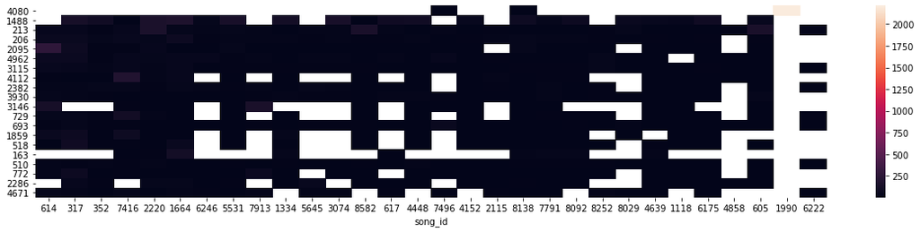

```python
#Use heatmap to visualize the above output i.e. the most played songs by most interacted users
figure = plt.figure(figsize=(20, 4))
sns.heatmap(most_played_songs_users_selected);
```

```python
#Use the function defined above to find the 5000 most interacted users for 30 most played songs
most_played_songs_users_selected = find_most_interacted_users(most_played_songs, 5000)
most_played_songs_users_selected
```

| song_id | 614 | 317 | 352 | 7416 | 2220 | 1664 | 6246 | 5531 | 7913 | 1334 | ... | 8092 | 8252 | 8029 | 4639 | 1118 | 6175 | 4858 | 605 | 1990 | 6222 |
| --- | --- | --- | --- | --- | --- | --- | --- | --- | --- | --- | --- | --- | --- | --- | --- | --- | --- | --- | --- | --- | --- |
| 4080 | NaN | NaN | NaN | NaN | NaN | NaN | NaN | NaN | NaN | NaN | ... | NaN | NaN | NaN | NaN | NaN | NaN | NaN | NaN | 2213.0 | NaN |
| 1488 | NaN | 137.0 | 104.0 | 9.0 | 161.0 | 180.0 | 29.0 | 144.0 | NaN | 120.0 | ... | 73.0 | NaN | 56.0 | 46.0 | 44.0 | 89.0 | NaN | 50.0 | NaN | NaN |
| 213 | 43.0 | 44.0 | 10.0 | 36.0 | 157.0 | 28.0 | 19.0 | 35.0 | 24.0 | 5.0 | ... | 4.0 | 18.0 | 27.0 | 5.0 | 4.0 | 4.0 | 15.0 | 156.0 | NaN | 20.0 |
| 206 | 54.0 | 56.0 | 29.0 | 47.0 | 31.0 | 75.0 | 17.0 | 26.0 | 23.0 | 20.0 | ... | 20.0 | 14.0 | 4.0 | 17.0 | 9.0 | 11.0 | NaN | 11.0 | NaN | NaN |
| 2095 | 271.0 | 78.0 | 10.0 | 15.0 | 36.0 | 8.0 | 6.0 | 35.0 | 7.0 | 3.0 | ... | 2.0 | 8.0 | NaN | 1.0 | 3.0 | 3.0 | NaN | 3.0 | NaN | NaN |
| ... | ... | ... | ... | ... | ... | ... | ... | ... | ... | ... | ... | ... | ... | ... | ... | ... | ... | ... | ... | ... | ... |
| 2752 | NaN | NaN | NaN | NaN | NaN | NaN | NaN | NaN | NaN | NaN | ... | NaN | NaN | NaN | NaN | NaN | NaN | NaN | NaN | NaN | NaN |
| 2751 | NaN | NaN | NaN | NaN | NaN | NaN | NaN | NaN | NaN | NaN | ... | NaN | NaN | NaN | NaN | NaN | NaN | NaN | NaN | NaN | NaN |
| 2750 | NaN | NaN | NaN | NaN | NaN | NaN | NaN | NaN | NaN | NaN | ... | NaN | NaN | NaN | NaN | NaN | NaN | NaN | NaN | NaN | NaN |
| 2745 | NaN | NaN | NaN | NaN | NaN | NaN | NaN | NaN | NaN | NaN | ... | NaN | NaN | NaN | NaN | NaN | NaN | NaN | NaN | NaN | NaN |
| 4999 | NaN | NaN | NaN | NaN | NaN | NaN | NaN | NaN | NaN | NaN | ... | NaN | NaN | NaN | NaN | NaN | NaN | NaN | NaN | NaN | NaN |

5000 rows × 30 columns

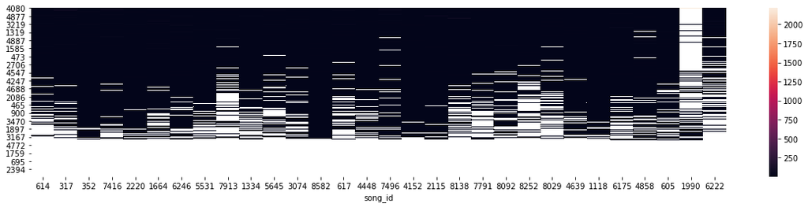

```python
#Use heatmap to visualize the above output i.e. the most played songs by most interacted users
figure = plt.figure(figsize=(20, 4))
sns.heatmap(most_played_songs_users_selected);
```

- In the above heatmap, you can see that some **cells are white i.e. the respective user did not listen to the song**. Those are represented by **NaN** in the interactions matrix.
- Here, we **only used 30 songs**, but if we use all the songs i.e. **10000** then the number of missing ratings will also increase and it will make the interactions matrix a **very sparse matrix**.

Clustering for a matrix with a lot of missing values is a challenging task. So below we will limit our interactions matrix by only using **1000 most played songs**.

**Observations and Insights: **_****

Now, let's cluster each user using K-Means clustering with K chosen above. We will **add one column `group` with cluster labels** to the **most played songs data**.

```python
predictions = KMeans(n_clusters=k_clust, random_state=0).fit_predict(interactions_matrix_replace) #Fit and predict using KMeans algorithm on the interaction matrix
results = pd.concat([most_played_songs_1k.reset_index(drop=True), pd.DataFrame({'group':predictions})], axis=1) #Concatenate most played songs data and the predictions
results
```

|  | 614 | 317 | 352 | 7416 | 2220 | 1664 | 6246 | 5531 | 7913 | 1334 | ... | 3858 | 7737 | 5587 | 2304 | 403 | 6825 | 4318 | 2654 | 9849 | group |
| --- | --- | --- | --- | --- | --- | --- | --- | --- | --- | --- | --- | --- | --- | --- | --- | --- | --- | --- | --- | --- | --- |
| 0 | NaN | NaN | NaN | NaN | NaN | NaN | NaN | NaN | NaN | NaN | ... | 1.0 | NaN | NaN | NaN | NaN | NaN | NaN | 2.0 | NaN | 1 |
| 1 | NaN | NaN | NaN | NaN | 1.0 | NaN | NaN | 1.0 | NaN | NaN | ... | NaN | 1.0 | NaN | NaN | NaN | NaN | NaN | NaN | NaN | 1 |
| 2 | NaN | NaN | NaN | NaN | NaN | NaN | 19.0 | NaN | NaN | NaN | ... | NaN | NaN | NaN | NaN | NaN | NaN | NaN | NaN | NaN | 1 |
| 3 | NaN | NaN | NaN | NaN | NaN | NaN | NaN | NaN | NaN | NaN | ... | NaN | NaN | NaN | NaN | NaN | NaN | NaN | NaN | NaN | 1 |
| 4 | NaN | NaN | NaN | NaN | NaN | NaN | NaN | NaN | NaN | NaN | ... | NaN | 1.0 | NaN | NaN | NaN | NaN | NaN | NaN | NaN | 1 |
| ... | ... | ... | ... | ... | ... | ... | ... | ... | ... | ... | ... | ... | ... | ... | ... | ... | ... | ... | ... | ... | ... |
| 4995 | NaN | NaN | NaN | NaN | NaN | NaN | NaN | NaN | NaN | NaN | ... | NaN | NaN | NaN | NaN | NaN | NaN | NaN | NaN | NaN | 1 |
| 4996 | NaN | NaN | NaN | NaN | NaN | NaN | NaN | NaN | NaN | NaN | ... | NaN | NaN | NaN | NaN | NaN | NaN | NaN | NaN | NaN | 1 |
| 4997 | NaN | NaN | NaN | NaN | NaN | NaN | 1.0 | NaN | NaN | NaN | ... | NaN | NaN | NaN | NaN | NaN | NaN | NaN | NaN | NaN | 1 |
| 4998 | NaN | NaN | NaN | NaN | NaN | NaN | NaN | NaN | NaN | NaN | ... | NaN | NaN | NaN | NaN | NaN | NaN | NaN | NaN | NaN | 1 |
| 4999 | NaN | NaN | NaN | NaN | NaN | NaN | NaN | NaN | NaN | NaN | ... | NaN | NaN | NaN | NaN | NaN | NaN | NaN | NaN | NaN | 1 |

5000 rows × 1001 columns

Let's check the count of user in each cluster

```python
#Check the count of users in each cluster
results['group'].value_counts()
```

```
1    4972
0      23
3       2
4       1
5       1
2       1
Name: group, dtype: int64
```

```
k= 2
1    4999
0       1
Name: group, dtype: int64
```

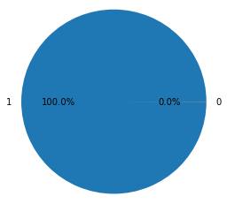

```
k= 3
1    4998
0       1
2       1
Name: group, dtype: int64
```

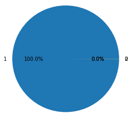

```
k= 4
3    4647
1     351
0       1
2       1
Name: group, dtype: int64
```

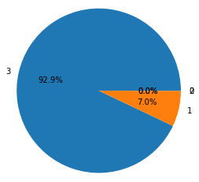

```
k= 5
4    4569
3     423
1       6
0       1
2       1
Name: group, dtype: int64
```

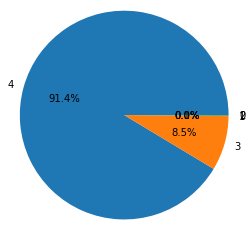

```
k= 6
1    4972
0      23
3       2
4       1
5       1
2       1
Name: group, dtype: int64
```

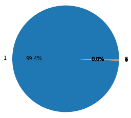

```
k= 7
4    4569
3     417
1       7
6       4
0       1
5       1
2       1
Name: group, dtype: int64
```

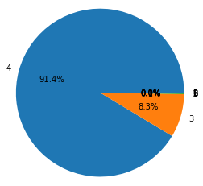

```
k= 8
2    4625
5     368
0       2
4       1
1       1
6       1
3       1
7       1
Name: group, dtype: int64
```

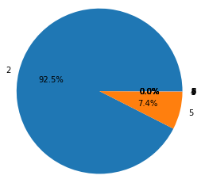

```
k= 9
3    4452
1     492
4      31
0      20
8       1
5       1
2       1
6       1
7       1
Name: group, dtype: int64
```

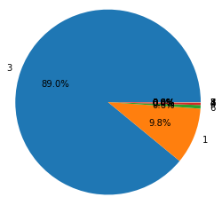

```
k= 10
2    4605
5     386
0       2
4       1
8       1
1       1
9       1
6       1
3       1
7       1
Name: group, dtype: int64
```

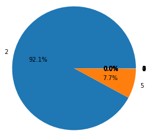

```
k= 11
2     4604
5      386
0        2
4        1
8        1
1        1
9        1
6        1
10       1
3        1
7        1
Name: group, dtype: int64
```

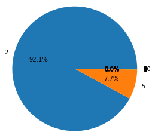

```
k= 12
2     4582
5      396
11      12
0        2
4        1
8        1
1        1
9        1
6        1
10       1
3        1
7        1
Name: group, dtype: int64
```

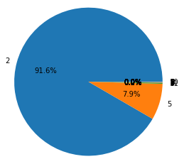

```
k= 13
2     4557
5      419
11      12
0        2
12       2
4        1
8        1
1        1
9        1
6        1
10       1
3        1
7        1
Name: group, dtype: int64
```

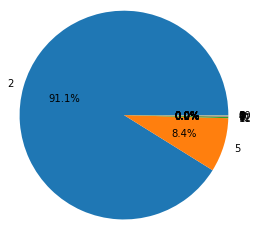

```
k= 14
2     4557
5      418
11      12
0        2
12       2
4        1
8        1
1        1
9        1
13       1
6        1
10       1
3        1
7        1
Name: group, dtype: int64
```

[1 more figures not shown]

```python
### Estimate clusters split for different K

for k in np.arange(2,15,1):
    print("k=",k)
    results1 = pd.DataFrame()
    predictions = KMeans(n_clusters=k, random_state=0).fit_predict(interactions_matrix_replace) #Fit and predict using KMeans algorithm on the interaction matrix
    results1 = pd.concat([most_played_songs_1k.reset_index(drop=True), pd.DataFrame({'group':predictions})], axis=1) #Concatenate most played songs data and the predictions
    #print(results1)
    print(results1["group"].value_counts()) #-> записать в столбец/строку матрицы #
    plt.pie(results1["group"].value_counts(), autopct= '%.1f%%', radius = 1.2, labels = results1["group"].unique().tolist())
    plt.show()
```

**Observations and Insights:**

- For every k from 2 to 15 was done KMeans and clustering of the database. It was found out that in most cases more than 90% of users belongs to the same class. It means these users will get the same recommendation.
- Clustering model in our case is close to Popularity Based Model (in more than 90% of users = Popularity-Based Model - recommending the same top popular songs for all the users). So, MAP@K for this model will be close to 0, like in Popularity-Based Model.

Let's visualize **the biggest cluster** and check how sparse or dense the cluster is. It would be difficult to visualize large clusters, so let's plot **only 50 users and songs with most interactions**.

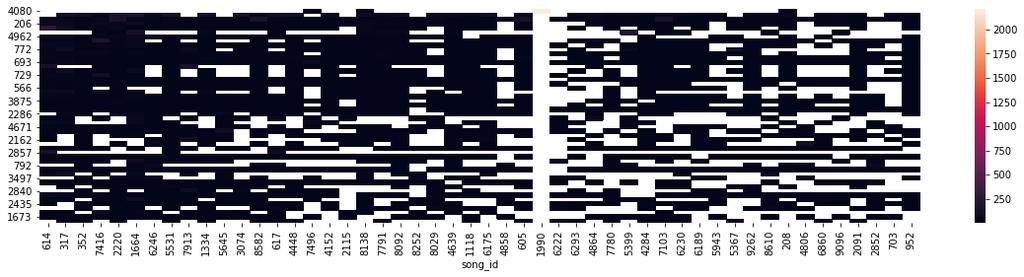

```python
cluster_number = 1
n_users = 50
n_songs = 50

#Filter the results dataframe to extract users in the cluster
cluster_1_predictions = results[results.group == cluster_number].drop(['group'], axis=1)


#Find top 50 songs with the most number of interactions
cluster_1_songs = find_most_played_songs(cluster_1_predictions, n_songs)

#Finding top 50 users with the most number of interactions
cluster_1_users = find_most_interacted_users(cluster_1_songs, n_users)

#Visualize using heatmap
figure = plt.figure(figsize=(20, 4))
sns.heatmap(cluster_1_users);
```

Now, let's **recommend songs** to a user from the chosen cluster. Let's select the user in cluster with most number of interactions

```python
#Hint: use find_most_interacted_users function defined above from the largest cluster 1
find_most_interacted_users(cluster_1_predictions, 1).index
```

```
Int64Index([2162], dtype='int64')
```

**Observations and Insights** *The user that interacted the most in the largest cluster (cluster 1) is 2162.

```python
num_of_top_songs = 5
```

```python
#recommend top 5 songs based on clustering based recommendation systems
#In cluster 1, the user ID 2162 has listened to most number of songs.
user_id_ = 2162
num_of_songs = 5

cluster_1_predictions.loc[2162, :]
```

```
614          1.0
317          NaN
352         21.0
7416         NaN
2220         NaN
           ...
6825         NaN
4318         NaN
2654         NaN
9849         NaN
counts    1690.0
Name: 2162, Length: 1001, dtype: float64
```

```python
user_id = 2162

#Finding all the songs for user 2162
user_id_ratings  = cluster_1_predictions.loc[user_id, :]

#Finding not listened songs for user 2162
user_id_unrated_songs =  user_id_ratings[user_id_ratings.isnull()]

#Finding the average rating by users in cluster 1 for those not listened songs
avg_ratings = pd.concat([user_id_unrated_songs, cluster_1_predictions.mean()], axis=1, join='inner').loc[:,0]

#Recommending top 20 songs
rec = avg_ratings.sort_values(ascending=False)[:20].index.tolist()
print(rec)
song_names_from_song_id(rec)
```

```
[32, 8858, 2287, 1578, 616, 994, 6685, 5199, 1823, 8075, 9185, 8254, 1791, 3608, 6584, 3863, 136, 9558, 8324, 390]

Recommended Songs:
```

| song_id | count_sum | play_count | title | release | artist_name | year |
| --- | --- | --- | --- | --- | --- | --- |
| 32 | 2869 | 158 | 221 | Spun | keller williams | 1998 |
| 8858 | 1495 | 179 | Teardrop | Pure Chillout / Lounge Music Vol. 2 - The Most... | Underworld | 0 |
| 2287 | 1661 | 126 | Bros Sto Rimagmeno Spiti (2003 Digital Remaster) | 50 Hronia Rebetiko Tragoudi | George Dalaras | 0 |
| 1578 | 1102 | 180 | Stuck Between | Voices In My Head | Riverside | 0 |
| 616 | 2395 | 246 | Kelma | Made In Medina / Ole Ole | Rachid Taha | 1995 |
| 994 | 1136 | 166 | Ona Kasuita | Mirando el mundo al revés | Che Sudaka | 2007 |
| 6685 | 973 | 135 | Waiting For A Dream | Want | Rufus Wainwright | 2004 |
| 5199 | 4972 | 423 | Recado Falado (Metrô Da Saudade) | 2 Em 1 | Alceu Valença | 0 |
| 1823 | 1324 | 170 | Scissors (Album Version) | Slipknot | Slipknot | 1989 |
| 8075 | 1387 | 159 | I C Love Affair | Disco Discharge. Euro Disco | Gaz Nevada | 0 |
| 9185 | 1790 | 295 | You'd Be So Nice To Come Home To | All Through The Night | Julie London | 1960 |
| 8254 | 999 | 246 | Untouchable | Fearless | Taylor Swift | 2009 |
| 1791 | 1950 | 272 | Eternal Flame (Single Version) | Eternal Flame | Atomic Kitten | 2004 |
| 3608 | 1654 | 287 | Musti Sotakoira (2007 Digital Remaster) | Musti Sotakoira | Kollaa Kestää | 0 |
| 6584 | 2466 | 421 | Welcome To The Black Parade (Album Version) | The Black Parade | My Chemical Romance | 2006 |
| 3863 | 1570 | 276 | None Shall Pass (Main) | None Shall Pass - Single | Aesop Rock | 0 |
| 136 | 1050 | 159 | O My God | Message In A Box | The Police | 1983 |
| 9558 | 1286 | 218 | The Stallion | The Pod | Ween | 1991 |
| 8324 | 5212 | 580 | The Big Gundown | Invaders Must Die Remixes and Bonus Tracks | The Prodigy | 2009 |
| 390 | 2856 | 379 | Oceanside | Akron/Family & Angels Of Light | Angels Of Light & Akron/Family | 2005 |

**Observations and Insights:**

- In our case clustering is divided our users into uneven clusters, where the largest cluster is more than 90% of all the users. It means that we need to give the same recommendations to more than 90% of the users. These recommendations will not be presonolized.
- In my opinion, this method looks like popularity-based filtering, as we recommend the same songs to more than 90% of the users.

# **Content-Based Recommendation Systems**

**Think About It:** So far we have only used the play_count of songs to find recommendations but we have other information/features on songs as well. Can we take those song features into account?

In content-based recommendation system, we would be using the feature - **text**. In this dataset, we don't have any song review but we can combine the columns - **title**, **release**, and **artist_name** to create a text-based feature and apply **tfidf** feature extraction technique to extract features, which we later use to compute similar songs based on these texts.

```python
df_small['text'] = df_small["title"]+" "+df_small["release"]+" "+df_small["artist_name"]
df_small

#Use the smaller version of the original data to get the feature 'text'
```

|  | user_id | song_id | play_count | title | release | artist_name | year | text |
| --- | --- | --- | --- | --- | --- | --- | --- | --- |
| 197 | 6958 | 40 | 1 | Full Circle | Breakout | Miley Cyrus | 2008 | Full Circle Breakout Miley Cyrus |
| 198 | 6958 | 151 | 2 | Poor Jackie | Rabbit Habits | Man Man | 2008 | Poor Jackie Rabbit Habits Man Man |
| 199 | 6958 | 326 | 1 | Hot N Cold (Manhattan Clique Remix Radio Edit) | Hot N Cold | Katy Perry | 2008 | Hot N Cold (Manhattan Clique Remix Radio Edit)... |
| 200 | 6958 | 447 | 1 | Daisy And Prudence | Distillation | Erin McKeown | 2000 | Daisy And Prudence Distillation Erin McKeown |
| 201 | 6958 | 484 | 1 | Everythings Just Wonderful | Alright_ Still | Lily Allen | 0 | Everythings Just Wonderful Alright_ Still Lily... |
| ... | ... | ... | ... | ... | ... | ... | ... | ... |
| 1999761 | 47786 | 9717 | 1 | Do You Wanna | Konk | The Kooks | 2008 | Do You Wanna Konk The Kooks |
| 1999764 | 47786 | 9803 | 1 | Oh Comely | In The Aeroplane Over The Sea | Neutral Milk Hotel | 1998 | Oh Comely In The Aeroplane Over The Sea Neutra... |
| 1999765 | 47786 | 9847 | 1 | He Can Only Hold Her | Back To Black | Amy Winehouse | 2006 | He Can Only Hold Her Back To Black Amy Winehouse |
| 1999766 | 47786 | 9858 | 5 | Drunk Kid Catholic | Noise Floor [Rarities 98 - 05] | Bright Eyes | 2000 | Drunk Kid Catholic Noise Floor [Rarities 98 - ... |
| 1999768 | 47786 | 9954 | 3 | Let's Live For Today | 150 Rock 'N' Roll Classics | The Grass Roots | 1987 | Let's Live For Today 150 Rock 'N' Roll Classic... |

456352 rows × 8 columns

```python
df_small_CB = df_small[["user_id", "song_id", "play_count", "text"]]
df_small_CB  = df_small_CB.drop_duplicates(subset = ["song_id"])
df_small_CB = df_small_CB.set_index("song_id")
df_small_CB = df_small_CB.sort_index()
df_small_CB_index = df_small_CB.index
df_small_CB
```

| song_id | user_id | play_count | text |
| --- | --- | --- | --- |
| 1 | 42697 | 1 | Cearc Agus Coileach / The Hen And Cock Casadh/... |
| 4 | 57932 | 1 | Rome Wasn't Built In A Day Parts Of The Proces... |
| 5 | 39055 | 5 | Jesus Loves You (Album Version) Expect The Imp... |
| 11 | 36189 | 2 | Juke Box Hero (Remastered LP Version ) Definit... |
| 14 | 35091 | 1 | Love Don't Live Here Anymore Rhino Hi-Five: Ro... |
| ... | ... | ... | ... |
| 9989 | 27018 | 2 | Watch The Tapes Sound Of Silver LCD Soundsystem |
| 9992 | 64429 | 10 | Afterlife (Album Version) Afterlife Avenged Se... |
| 9994 | 56716 | 10 | Throw Some D's Remix Rich Boy Rich Boy / Andre... |
| 9995 | 35091 | 5 | Le Million Ma Génération Ste Strausz |
| 9996 | 50246 | 1 | Recovered Con:fusion Marco V |

5000 rows × 3 columns

```python
#Checking first five indices
indices = pd.Series(df_small_CB.index)
indices[0:5]
```

```
0     1
1     4
2     5
3    11
4    14
Name: song_id, dtype: int64
```

#### Loading libraries to handle text data

```python
import re #regular expression patterns
import nltk
#download all the nltk packages required here
nltk.download('wordnet')
nltk.download('stopwords')
nltk.download('punkt')
from nltk import word_tokenize #tokenization for spaces
from nltk.stem import WordNetLemmatizer #standartization
from nltk.corpus import stopwords #remove stop words
from sklearn.feature_extraction.text import CountVectorizer, TfidfVectorizer #feature extraction
```

We will create a **function to pre-process the text data:**

- **Stopwords:** A stop word is a commonly used word (such as “the”, “a”, “an”, “in”) that does not contain information in the text and can be ignored.
- **Lemmatization:** Lemmatization in linguistics is the process of grouping together the inflected forms of a word so they can be analyzed as a single item. For example, runs, running, ran are all forms of the word run, therefore run is the lemma of all these words.

```python
#Build the function to preprocess the data
```

```python
def tokenize(text):

    #Making each letter as lowercase and removing non-alphabetical text
    text = re.sub(r"[^a-zA-Z]"," ",text.lower())

    #Extracting each word in the text
    tokens = word_tokenize(text)

    #Removing stopwords
    words = [word for word in tokens if word not in stopwords.words("english")]

    #Lemmatize the words
    text_lems = [WordNetLemmatizer().lemmatize(lem).strip() for lem in words]

    return text_lems
```

```python
#Apply TF-IDF transformation on the text column using the function defined above - using tfidf as a feature extraction technique
tfidf = TfidfVectorizer(tokenizer=tokenize)
song_tfidf = tfidf.fit_transform(df_small_CB['text'].values).toarray()
```

```python
song_tfidf
```

```
array([[0., 0., 0., ..., 0., 0., 0.],
       [0., 0., 0., ..., 0., 0., 0.],
       [0., 0., 0., ..., 0., 0., 0.],
       ...,
       [0., 0., 0., ..., 0., 0., 0.],
       [0., 0., 0., ..., 0., 0., 0.],
       [0., 0., 0., ..., 0., 0., 0.]])
```

```python
songs_features_df = pd.DataFrame(song_tfidf)
songs_features_df.index.names = ["song_id"]
songs_features_df.columns.names = ["text_features"]
songs_features_df.index = df_small_CB_index
songs_features_df
```

| text_features song_id | 0 | 1 | 2 | 3 | 4 | 5 | 6 | 7 | 8 | 9 | ... | 7259 | 7260 | 7261 | 7262 | 7263 | 7264 | 7265 | 7266 | 7267 | 7268 |
| --- | --- | --- | --- | --- | --- | --- | --- | --- | --- | --- | --- | --- | --- | --- | --- | --- | --- | --- | --- | --- | --- |
| 1 | 0.0 | 0.0 | 0.0 | 0.0 | 0.0 | 0.0 | 0.0 | 0.0 | 0.0 | 0.0 | ... | 0.0 | 0.0 | 0.0 | 0.0 | 0.0 | 0.0 | 0.0 | 0.0 | 0.0 | 0.0 |
| 4 | 0.0 | 0.0 | 0.0 | 0.0 | 0.0 | 0.0 | 0.0 | 0.0 | 0.0 | 0.0 | ... | 0.0 | 0.0 | 0.0 | 0.0 | 0.0 | 0.0 | 0.0 | 0.0 | 0.0 | 0.0 |
| 5 | 0.0 | 0.0 | 0.0 | 0.0 | 0.0 | 0.0 | 0.0 | 0.0 | 0.0 | 0.0 | ... | 0.0 | 0.0 | 0.0 | 0.0 | 0.0 | 0.0 | 0.0 | 0.0 | 0.0 | 0.0 |
| 11 | 0.0 | 0.0 | 0.0 | 0.0 | 0.0 | 0.0 | 0.0 | 0.0 | 0.0 | 0.0 | ... | 0.0 | 0.0 | 0.0 | 0.0 | 0.0 | 0.0 | 0.0 | 0.0 | 0.0 | 0.0 |
| 14 | 0.0 | 0.0 | 0.0 | 0.0 | 0.0 | 0.0 | 0.0 | 0.0 | 0.0 | 0.0 | ... | 0.0 | 0.0 | 0.0 | 0.0 | 0.0 | 0.0 | 0.0 | 0.0 | 0.0 | 0.0 |
| ... | ... | ... | ... | ... | ... | ... | ... | ... | ... | ... | ... | ... | ... | ... | ... | ... | ... | ... | ... | ... | ... |
| 9989 | 0.0 | 0.0 | 0.0 | 0.0 | 0.0 | 0.0 | 0.0 | 0.0 | 0.0 | 0.0 | ... | 0.0 | 0.0 | 0.0 | 0.0 | 0.0 | 0.0 | 0.0 | 0.0 | 0.0 | 0.0 |
| 9992 | 0.0 | 0.0 | 0.0 | 0.0 | 0.0 | 0.0 | 0.0 | 0.0 | 0.0 | 0.0 | ... | 0.0 | 0.0 | 0.0 | 0.0 | 0.0 | 0.0 | 0.0 | 0.0 | 0.0 | 0.0 |
| 9994 | 0.0 | 0.0 | 0.0 | 0.0 | 0.0 | 0.0 | 0.0 | 0.0 | 0.0 | 0.0 | ... | 0.0 | 0.0 | 0.0 | 0.0 | 0.0 | 0.0 | 0.0 | 0.0 | 0.0 | 0.0 |
| 9995 | 0.0 | 0.0 | 0.0 | 0.0 | 0.0 | 0.0 | 0.0 | 0.0 | 0.0 | 0.0 | ... | 0.0 | 0.0 | 0.0 | 0.0 | 0.0 | 0.0 | 0.0 | 0.0 | 0.0 | 0.0 |
| 9996 | 0.0 | 0.0 | 0.0 | 0.0 | 0.0 | 0.0 | 0.0 | 0.0 | 0.0 | 0.0 | ... | 0.0 | 0.0 | 0.0 | 0.0 | 0.0 | 0.0 | 0.0 | 0.0 | 0.0 | 0.0 |

5000 rows × 7269 columns

```python
#printing this dataframe to excel
#songs_features_df.to_excel("songs_features_df.xlsx")
```

We have extracted **7269 features** from the text data. Now, we can find similarities between songs using these features. We will use cosine similarity to calculate the similarity.

```python
#Find similar songs
similar_songs = cosine_similarity(song_tfidf, song_tfidf)
similar_songs
```

```
array([[1., 0., 0., ..., 0., 0., 0.],
       [0., 1., 0., ..., 0., 0., 0.],
       [0., 0., 1., ..., 0., 0., 0.],
       ...,
       [0., 0., 0., ..., 1., 0., 0.],
       [0., 0., 0., ..., 0., 1., 0.],
       [0., 0., 0., ..., 0., 0., 1.]])
```

```python
similar_songs_df = pd.DataFrame(similar_songs)
similar_songs_df.index = df_small_CB_index
similar_songs_df.columns = df_small_CB_index
similar_songs_df
```

| song_id | 1 | 4 | 5 | 11 | 14 | 15 | 16 | 17 | 20 | 21 | ... | 9976 | 9977 | 9981 | 9983 | 9988 | 9989 | 9992 | 9994 | 9995 | 9996 |
| --- | --- | --- | --- | --- | --- | --- | --- | --- | --- | --- | --- | --- | --- | --- | --- | --- | --- | --- | --- | --- | --- |
| 1 | 1.0 | 0.0 | 0.000000 | 0.000000 | 0.000000 | 0.0 | 0.000000 | 0.000000 | 0.000000 | 0.0 | ... | 0.0 | 0.0 | 0.000000 | 0.0 | 0.0 | 0.0 | 0.000000 | 0.0 | 0.0 | 0.0 |
| 4 | 0.0 | 1.0 | 0.000000 | 0.000000 | 0.000000 | 0.0 | 0.000000 | 0.000000 | 0.072090 | 0.0 | ... | 0.0 | 0.0 | 0.000000 | 0.0 | 0.0 | 0.0 | 0.000000 | 0.0 | 0.0 | 0.0 |
| 5 | 0.0 | 0.0 | 1.000000 | 0.026741 | 0.030937 | 0.0 | 0.029412 | 0.079680 | 0.066219 | 0.0 | ... | 0.0 | 0.0 | 0.000000 | 0.0 | 0.0 | 0.0 | 0.052158 | 0.0 | 0.0 | 0.0 |
| 11 | 0.0 | 0.0 | 0.026741 | 1.000000 | 0.000000 | 0.0 | 0.029703 | 0.038438 | 0.031944 | 0.0 | ... | 0.0 | 0.0 | 0.000000 | 0.0 | 0.0 | 0.0 | 0.025161 | 0.0 | 0.0 | 0.0 |
| 14 | 0.0 | 0.0 | 0.030937 | 0.000000 | 1.000000 | 0.0 | 0.000000 | 0.000000 | 0.000000 | 0.0 | ... | 0.0 | 0.0 | 0.040852 | 0.0 | 0.0 | 0.0 | 0.000000 | 0.0 | 0.0 | 0.0 |
| ... | ... | ... | ... | ... | ... | ... | ... | ... | ... | ... | ... | ... | ... | ... | ... | ... | ... | ... | ... | ... | ... |
| 9989 | 0.0 | 0.0 | 0.000000 | 0.000000 | 0.000000 | 0.0 | 0.000000 | 0.000000 | 0.000000 | 0.0 | ... | 0.0 | 0.0 | 0.000000 | 0.0 | 0.0 | 1.0 | 0.000000 | 0.0 | 0.0 | 0.0 |
| 9992 | 0.0 | 0.0 | 0.052158 | 0.025161 | 0.000000 | 0.0 | 0.027673 | 0.074971 | 0.062306 | 0.0 | ... | 0.0 | 0.0 | 0.000000 | 0.0 | 0.0 | 0.0 | 1.000000 | 0.0 | 0.0 | 0.0 |
| 9994 | 0.0 | 0.0 | 0.000000 | 0.000000 | 0.000000 | 0.0 | 0.000000 | 0.000000 | 0.000000 | 0.0 | ... | 0.0 | 0.0 | 0.000000 | 0.0 | 0.0 | 0.0 | 0.000000 | 1.0 | 0.0 | 0.0 |
| 9995 | 0.0 | 0.0 | 0.000000 | 0.000000 | 0.000000 | 0.0 | 0.000000 | 0.000000 | 0.000000 | 0.0 | ... | 0.0 | 0.0 | 0.000000 | 0.0 | 0.0 | 0.0 | 0.000000 | 0.0 | 1.0 | 0.0 |
| 9996 | 0.0 | 0.0 | 0.000000 | 0.000000 | 0.000000 | 0.0 | 0.000000 | 0.000000 | 0.000000 | 0.0 | ... | 0.0 | 0.0 | 0.000000 | 0.0 | 0.0 | 0.0 | 0.000000 | 0.0 | 0.0 | 1.0 |

5000 rows × 5000 columns

Finally, let's create a function to find most similar songs to recommend for a given song

```python
#OLD VERSION
# Create a function that takes in song title as input and returns the top 10 recommended songs
nn=10

def recommendations_CB(song_id, similar_songs, nn):

    recommended_songs = []

    indices = pd.Series(df_small_CB.index)

    # getting the index of the song that matches the song_id
    idx = indices[indices == song_id].index[0]

    # creating a Series with the similarity scores in descending order
    score_series = pd.Series(similar_songs[idx]).sort_values(ascending = False)

    # getting the indices of 10 most similar songs
    #==========top_indexes = list(score_series.iloc[1:nn+1].index)
    top_indexes_series_all_users = score_series.iloc[1:]

    top_indexes = score_series.iloc[1:nn+1].index.tolist()
    top_indexes

    # populating the list with the song_id of the best nn matching songs
    #for i in top_indexes:
    #    recommended_songs.append(list(df_small_CB.index)[i])

    return top_indexes, top_indexes_series_all_users
```

Recommend top songs similar to some song

```python
#Recommend TOP 10 songs for user 40 using the function defined above
recc, sss = recommendations_CB(40, similar_songs, 10)
print(recc)
song_names_from_song_id(recc)
```

```
[3676, 3551, 3130, 2248, 1473, 4852, 3355, 3788, 3608, 220]

Recommended Songs:
```

| song_id | count_sum | play_count | title | release | artist_name | year |
| --- | --- | --- | --- | --- | --- | --- |
| 3676 | 457 | 116 | I Wanna Love You (Akon Cover) ( Compilation) | The Way We Talk | The Maine | 2007 |
| 3551 | 581 | 317 | You're A Cad | Ray Guns Are Not Just The Future | the bird and the bee | 2009 |
| 3130 | 213 | 142 | Fool For Your Loving | Whitesnake's Greatest Hits | Whitesnake | 1980 |
| 2248 | 1617 | 608 | Not Fair | Ö3 Greatest Hits 46 | Lily Allen | 2009 |
| 1473 | 193 | 65 | Wishin' And Hopin' | Totally Chick Flicks | Dusty Springfield | 0 |
| 4852 | 1961 | 553 | Naive | 17 Again - Music From The Motion Picture | The Kooks | 2009 |
| 3355 | 271 | 101 | Brown Sugar (Edited) | Brown Sugar | D'Angelo | 1995 |
| 3788 | 600 | 168 | ...Baby One More Time | Essential - Girls Night In | Britney Spears | 1998 |
| 3608 | 1654 | 287 | Musti Sotakoira (2007 Digital Remaster) | Musti Sotakoira | Kollaa Kestää | 0 |
| 220 | 142 | 86 | Sometimes Things Get_ Whatever | Random Album Title | Deadmau5 | 2008 |

## **Evaluation (Precision/Recall) of the Content-Based Filtering

### **Preparing Train and Test Sets and Interaction Matrices - for evaluation of each model**

```python
#Split Data into Train and Test DataSets 80/20
df_train, df_test = train_test_split(df_small, test_size=0.2, random_state=10) #can use df_small instead of df

print(df_train.shape, df_test.shape)

#create train and test interaction matrices
interactions_matrix_train = df_train.pivot(index='user_id', columns='song_id', values='play_count')
interactions_matrix_train.fillna(0, inplace=True)

interactions_matrix_test = df_test.pivot(index='user_id', columns='song_id', values='play_count')
interactions_matrix_test.fillna(0, inplace=True)

print(interactions_matrix_train.shape, interactions_matrix_test.shape)
```

```
(365081, 8) (91271, 8)
(5000, 5000) (5000, 4991)
```

```python
#Finding intersection between these matrices
#train and test matrices should have the same users, the same songs (to be comparable)

#Finding unique users in train and test data and then taking their intersection i.e. common users in train and test data
train_idx = set(interactions_matrix_train.index)
test_idx = set(interactions_matrix_test.index)
match_idx = train_idx.intersection(test_idx)
match_idx=sorted(match_idx)

#Finding unique songs in train and test data and then taking their intersection i.e. common movies in train and test data
train_songs = set(interactions_matrix_train.columns)
test_songs = set(interactions_matrix_test.columns)
match_cols = train_songs.intersection(test_songs)
match_cols=sorted(match_cols)

#Selecting only common users and songs from the test interaction matrix
interactions_matrix_test = interactions_matrix_test.loc[match_idx, match_cols]
interactions_matrix_test.shape

#Selecting only common users and songs from the TRAIN interaction matrix
interactions_matrix_train = interactions_matrix_train.loc[match_idx, match_cols]
interactions_matrix_train.shape
```

```
(5000, 4991)
```

```python
interactions_matrix_test
```

| song_id user_id | 1 | 4 | 5 | 11 | 14 | 15 | 16 | 17 | 20 | 21 | ... | 9976 | 9977 | 9981 | 9983 | 9988 | 9989 | 9992 | 9994 | 9995 | 9996 |
| --- | --- | --- | --- | --- | --- | --- | --- | --- | --- | --- | --- | --- | --- | --- | --- | --- | --- | --- | --- | --- | --- |
| 11 | 0.0 | 0.0 | 0.0 | 0.0 | 0.0 | 0.0 | 0.0 | 0.0 | 0.0 | 0.0 | ... | 0.0 | 0.0 | 0.0 | 0.0 | 0.0 | 0.0 | 0.0 | 0.0 | 0.0 | 0.0 |
| 17 | 0.0 | 0.0 | 0.0 | 0.0 | 0.0 | 0.0 | 0.0 | 0.0 | 0.0 | 0.0 | ... | 0.0 | 0.0 | 0.0 | 0.0 | 0.0 | 0.0 | 0.0 | 0.0 | 0.0 | 0.0 |
| 32 | 0.0 | 0.0 | 0.0 | 0.0 | 0.0 | 0.0 | 0.0 | 0.0 | 0.0 | 0.0 | ... | 0.0 | 0.0 | 0.0 | 0.0 | 0.0 | 0.0 | 0.0 | 0.0 | 0.0 | 0.0 |
| 42 | 0.0 | 0.0 | 0.0 | 0.0 | 0.0 | 0.0 | 0.0 | 0.0 | 0.0 | 0.0 | ... | 0.0 | 0.0 | 0.0 | 0.0 | 0.0 | 0.0 | 0.0 | 0.0 | 0.0 | 0.0 |
| 57 | 0.0 | 0.0 | 0.0 | 0.0 | 0.0 | 0.0 | 0.0 | 0.0 | 0.0 | 0.0 | ... | 0.0 | 0.0 | 0.0 | 0.0 | 0.0 | 0.0 | 0.0 | 0.0 | 0.0 | 0.0 |
| ... | ... | ... | ... | ... | ... | ... | ... | ... | ... | ... | ... | ... | ... | ... | ... | ... | ... | ... | ... | ... | ... |
| 76307 | 0.0 | 0.0 | 0.0 | 0.0 | 0.0 | 0.0 | 0.0 | 0.0 | 0.0 | 0.0 | ... | 0.0 | 0.0 | 0.0 | 0.0 | 0.0 | 0.0 | 0.0 | 0.0 | 0.0 | 0.0 |
| 76331 | 0.0 | 0.0 | 0.0 | 0.0 | 0.0 | 0.0 | 0.0 | 0.0 | 0.0 | 0.0 | ... | 0.0 | 0.0 | 0.0 | 0.0 | 0.0 | 0.0 | 0.0 | 0.0 | 0.0 | 0.0 |
| 76333 | 0.0 | 0.0 | 0.0 | 0.0 | 0.0 | 0.0 | 0.0 | 0.0 | 0.0 | 0.0 | ... | 0.0 | 0.0 | 0.0 | 0.0 | 0.0 | 0.0 | 0.0 | 0.0 | 0.0 | 0.0 |
| 76342 | 0.0 | 0.0 | 0.0 | 0.0 | 0.0 | 0.0 | 0.0 | 0.0 | 0.0 | 0.0 | ... | 0.0 | 0.0 | 0.0 | 0.0 | 0.0 | 0.0 | 0.0 | 0.0 | 0.0 | 0.0 |
| 76347 | 0.0 | 0.0 | 0.0 | 0.0 | 0.0 | 0.0 | 0.0 | 0.0 | 0.0 | 0.0 | ... | 0.0 | 0.0 | 0.0 | 0.0 | 0.0 | 0.0 | 0.0 | 0.0 | 0.0 | 0.0 |

5000 rows × 4991 columns

```python
#INTERACTION MATRIX FOR CONTENT-BASED FILTERING - PREDICTION on TRAIN SET
#==============================================================================================
#interactions_matrix_train_preds_CONTENT
```

```python
similar_songs_df
```

| song_id | 1 | 4 | 5 | 11 | 14 | 15 | 16 | 17 | 20 | 21 | ... | 9976 | 9977 | 9981 | 9983 | 9988 | 9989 | 9992 | 9994 | 9995 | 9996 |
| --- | --- | --- | --- | --- | --- | --- | --- | --- | --- | --- | --- | --- | --- | --- | --- | --- | --- | --- | --- | --- | --- |
| 1 | 1.0 | 0.0 | 0.000000 | 0.000000 | 0.000000 | 0.0 | 0.000000 | 0.000000 | 0.000000 | 0.0 | ... | 0.0 | 0.0 | 0.000000 | 0.0 | 0.0 | 0.0 | 0.000000 | 0.0 | 0.0 | 0.0 |
| 4 | 0.0 | 1.0 | 0.000000 | 0.000000 | 0.000000 | 0.0 | 0.000000 | 0.000000 | 0.072090 | 0.0 | ... | 0.0 | 0.0 | 0.000000 | 0.0 | 0.0 | 0.0 | 0.000000 | 0.0 | 0.0 | 0.0 |
| 5 | 0.0 | 0.0 | 1.000000 | 0.026741 | 0.030937 | 0.0 | 0.029412 | 0.079680 | 0.066219 | 0.0 | ... | 0.0 | 0.0 | 0.000000 | 0.0 | 0.0 | 0.0 | 0.052158 | 0.0 | 0.0 | 0.0 |
| 11 | 0.0 | 0.0 | 0.026741 | 1.000000 | 0.000000 | 0.0 | 0.029703 | 0.038438 | 0.031944 | 0.0 | ... | 0.0 | 0.0 | 0.000000 | 0.0 | 0.0 | 0.0 | 0.025161 | 0.0 | 0.0 | 0.0 |
| 14 | 0.0 | 0.0 | 0.030937 | 0.000000 | 1.000000 | 0.0 | 0.000000 | 0.000000 | 0.000000 | 0.0 | ... | 0.0 | 0.0 | 0.040852 | 0.0 | 0.0 | 0.0 | 0.000000 | 0.0 | 0.0 | 0.0 |
| ... | ... | ... | ... | ... | ... | ... | ... | ... | ... | ... | ... | ... | ... | ... | ... | ... | ... | ... | ... | ... | ... |
| 9989 | 0.0 | 0.0 | 0.000000 | 0.000000 | 0.000000 | 0.0 | 0.000000 | 0.000000 | 0.000000 | 0.0 | ... | 0.0 | 0.0 | 0.000000 | 0.0 | 0.0 | 1.0 | 0.000000 | 0.0 | 0.0 | 0.0 |
| 9992 | 0.0 | 0.0 | 0.052158 | 0.025161 | 0.000000 | 0.0 | 0.027673 | 0.074971 | 0.062306 | 0.0 | ... | 0.0 | 0.0 | 0.000000 | 0.0 | 0.0 | 0.0 | 1.000000 | 0.0 | 0.0 | 0.0 |
| 9994 | 0.0 | 0.0 | 0.000000 | 0.000000 | 0.000000 | 0.0 | 0.000000 | 0.000000 | 0.000000 | 0.0 | ... | 0.0 | 0.0 | 0.000000 | 0.0 | 0.0 | 0.0 | 0.000000 | 1.0 | 0.0 | 0.0 |
| 9995 | 0.0 | 0.0 | 0.000000 | 0.000000 | 0.000000 | 0.0 | 0.000000 | 0.000000 | 0.000000 | 0.0 | ... | 0.0 | 0.0 | 0.000000 | 0.0 | 0.0 | 0.0 | 0.000000 | 0.0 | 1.0 | 0.0 |
| 9996 | 0.0 | 0.0 | 0.000000 | 0.000000 | 0.000000 | 0.0 | 0.000000 | 0.000000 | 0.000000 | 0.0 | ... | 0.0 | 0.0 | 0.000000 | 0.0 | 0.0 | 0.0 | 0.000000 | 0.0 | 0.0 | 1.0 |

5000 rows × 5000 columns

```python
np.fill_diagonal(similar_songs_df.values, 0)
similar_songs_df
```

| song_id | 1 | 4 | 5 | 11 | 14 | 15 | 16 | 17 | 20 | 21 | ... | 9976 | 9977 | 9981 | 9983 | 9988 | 9989 | 9992 | 9994 | 9995 | 9996 |
| --- | --- | --- | --- | --- | --- | --- | --- | --- | --- | --- | --- | --- | --- | --- | --- | --- | --- | --- | --- | --- | --- |
| 1 | 0.0 | 0.0 | 0.000000 | 0.000000 | 0.000000 | 0.0 | 0.000000 | 0.000000 | 0.000000 | 0.0 | ... | 0.0 | 0.0 | 0.000000 | 0.0 | 0.0 | 0.0 | 0.000000 | 0.0 | 0.0 | 0.0 |
| 4 | 0.0 | 0.0 | 0.000000 | 0.000000 | 0.000000 | 0.0 | 0.000000 | 0.000000 | 0.072090 | 0.0 | ... | 0.0 | 0.0 | 0.000000 | 0.0 | 0.0 | 0.0 | 0.000000 | 0.0 | 0.0 | 0.0 |
| 5 | 0.0 | 0.0 | 0.000000 | 0.026741 | 0.030937 | 0.0 | 0.029412 | 0.079680 | 0.066219 | 0.0 | ... | 0.0 | 0.0 | 0.000000 | 0.0 | 0.0 | 0.0 | 0.052158 | 0.0 | 0.0 | 0.0 |
| 11 | 0.0 | 0.0 | 0.026741 | 0.000000 | 0.000000 | 0.0 | 0.029703 | 0.038438 | 0.031944 | 0.0 | ... | 0.0 | 0.0 | 0.000000 | 0.0 | 0.0 | 0.0 | 0.025161 | 0.0 | 0.0 | 0.0 |
| 14 | 0.0 | 0.0 | 0.030937 | 0.000000 | 0.000000 | 0.0 | 0.000000 | 0.000000 | 0.000000 | 0.0 | ... | 0.0 | 0.0 | 0.040852 | 0.0 | 0.0 | 0.0 | 0.000000 | 0.0 | 0.0 | 0.0 |
| ... | ... | ... | ... | ... | ... | ... | ... | ... | ... | ... | ... | ... | ... | ... | ... | ... | ... | ... | ... | ... | ... |
| 9989 | 0.0 | 0.0 | 0.000000 | 0.000000 | 0.000000 | 0.0 | 0.000000 | 0.000000 | 0.000000 | 0.0 | ... | 0.0 | 0.0 | 0.000000 | 0.0 | 0.0 | 0.0 | 0.000000 | 0.0 | 0.0 | 0.0 |
| 9992 | 0.0 | 0.0 | 0.052158 | 0.025161 | 0.000000 | 0.0 | 0.027673 | 0.074971 | 0.062306 | 0.0 | ... | 0.0 | 0.0 | 0.000000 | 0.0 | 0.0 | 0.0 | 0.000000 | 0.0 | 0.0 | 0.0 |
| 9994 | 0.0 | 0.0 | 0.000000 | 0.000000 | 0.000000 | 0.0 | 0.000000 | 0.000000 | 0.000000 | 0.0 | ... | 0.0 | 0.0 | 0.000000 | 0.0 | 0.0 | 0.0 | 0.000000 | 0.0 | 0.0 | 0.0 |
| 9995 | 0.0 | 0.0 | 0.000000 | 0.000000 | 0.000000 | 0.0 | 0.000000 | 0.000000 | 0.000000 | 0.0 | ... | 0.0 | 0.0 | 0.000000 | 0.0 | 0.0 | 0.0 | 0.000000 | 0.0 | 0.0 | 0.0 |
| 9996 | 0.0 | 0.0 | 0.000000 | 0.000000 | 0.000000 | 0.0 | 0.000000 | 0.000000 | 0.000000 | 0.0 | ... | 0.0 | 0.0 | 0.000000 | 0.0 | 0.0 | 0.0 | 0.000000 | 0.0 | 0.0 | 0.0 |

5000 rows × 5000 columns

```python
interactions_matrix_pred_CONTENT = pd.DataFrame(0.0, columns = match_cols, index = match_idx) #match_cols instead top5000_most_played_songs
interactions_matrix_pred_CONTENT.index.names = ["user_id"]
interactions_matrix_pred_CONTENT.columns.names = ["song_id"]
interactions_matrix_pred_CONTENT
```

| song_id user_id | 1 | 4 | 5 | 11 | 14 | 15 | 16 | 17 | 20 | 21 | ... | 9976 | 9977 | 9981 | 9983 | 9988 | 9989 | 9992 | 9994 | 9995 | 9996 |
| --- | --- | --- | --- | --- | --- | --- | --- | --- | --- | --- | --- | --- | --- | --- | --- | --- | --- | --- | --- | --- | --- |
| 11 | 0.0 | 0.0 | 0.0 | 0.0 | 0.0 | 0.0 | 0.0 | 0.0 | 0.0 | 0.0 | ... | 0.0 | 0.0 | 0.0 | 0.0 | 0.0 | 0.0 | 0.0 | 0.0 | 0.0 | 0.0 |
| 17 | 0.0 | 0.0 | 0.0 | 0.0 | 0.0 | 0.0 | 0.0 | 0.0 | 0.0 | 0.0 | ... | 0.0 | 0.0 | 0.0 | 0.0 | 0.0 | 0.0 | 0.0 | 0.0 | 0.0 | 0.0 |
| 32 | 0.0 | 0.0 | 0.0 | 0.0 | 0.0 | 0.0 | 0.0 | 0.0 | 0.0 | 0.0 | ... | 0.0 | 0.0 | 0.0 | 0.0 | 0.0 | 0.0 | 0.0 | 0.0 | 0.0 | 0.0 |
| 42 | 0.0 | 0.0 | 0.0 | 0.0 | 0.0 | 0.0 | 0.0 | 0.0 | 0.0 | 0.0 | ... | 0.0 | 0.0 | 0.0 | 0.0 | 0.0 | 0.0 | 0.0 | 0.0 | 0.0 | 0.0 |
| 57 | 0.0 | 0.0 | 0.0 | 0.0 | 0.0 | 0.0 | 0.0 | 0.0 | 0.0 | 0.0 | ... | 0.0 | 0.0 | 0.0 | 0.0 | 0.0 | 0.0 | 0.0 | 0.0 | 0.0 | 0.0 |
| ... | ... | ... | ... | ... | ... | ... | ... | ... | ... | ... | ... | ... | ... | ... | ... | ... | ... | ... | ... | ... | ... |
| 76307 | 0.0 | 0.0 | 0.0 | 0.0 | 0.0 | 0.0 | 0.0 | 0.0 | 0.0 | 0.0 | ... | 0.0 | 0.0 | 0.0 | 0.0 | 0.0 | 0.0 | 0.0 | 0.0 | 0.0 | 0.0 |
| 76331 | 0.0 | 0.0 | 0.0 | 0.0 | 0.0 | 0.0 | 0.0 | 0.0 | 0.0 | 0.0 | ... | 0.0 | 0.0 | 0.0 | 0.0 | 0.0 | 0.0 | 0.0 | 0.0 | 0.0 | 0.0 |
| 76333 | 0.0 | 0.0 | 0.0 | 0.0 | 0.0 | 0.0 | 0.0 | 0.0 | 0.0 | 0.0 | ... | 0.0 | 0.0 | 0.0 | 0.0 | 0.0 | 0.0 | 0.0 | 0.0 | 0.0 | 0.0 |
| 76342 | 0.0 | 0.0 | 0.0 | 0.0 | 0.0 | 0.0 | 0.0 | 0.0 | 0.0 | 0.0 | ... | 0.0 | 0.0 | 0.0 | 0.0 | 0.0 | 0.0 | 0.0 | 0.0 | 0.0 | 0.0 |
| 76347 | 0.0 | 0.0 | 0.0 | 0.0 | 0.0 | 0.0 | 0.0 | 0.0 | 0.0 | 0.0 | ... | 0.0 | 0.0 | 0.0 | 0.0 | 0.0 | 0.0 | 0.0 | 0.0 | 0.0 | 0.0 |

5000 rows × 4991 columns

```python
def intersection(lst1, lst2):
    lst3 = [value for value in lst1 if value in lst2]
    return lst3

def Union(lst1, lst2):  #without repetition
    final_list = list(set(lst1) | set(lst2))
    return final_list
```

```python
#NEW VERSIONbbbbb  - 3d Attempt  FINAL, I hope
# Create a function that takes in song title as input and returns the top 10 recommended songs

def recommendations_CB_full_series(song_id, similar_songs_df):

    recommended_songs = []

    # creating a Series with the similarity scores in descending order
    score_series = pd.Series(similar_songs_df[song_id]).sort_values(ascending = False)

    score_series = score_series[score_series>0]

    #score_series = score_series[score_series<1]

    # getting the indices of NON-ZERO-similarity-score similar songs
    #top_indexes = list(score_series.index)

    #top_indexes = intersection(top_indexes,match_cols)

    # populating the list with the song_id of the best nn matching songs
    #for i in top_indexes:
    #    recommended_songs.append(top_indexes)

        #>>> numbers = [1, 2, 3]
        #>>> numbers.append(4)
        #>>> numbers [1, 2, 3, 4]

        #Union(recommended_songs, list(df_small_CB.index)[i].tolist() )

    return score_series #recommended_songs
```

```python
#CREATE INTERACTION MATRIX USER/SONGS: Recommendations for Content-Based Model

#For every user:
    #find songs he actually listened
    #for every actual song -> find similar song
    #form series of similar song for this user
    #sort this series DESCENDING by similarity score, delete duplicates(if any)
    #Form PREDICION INTERACTION USER/SONG MATRIX

for user in match_idx: #match_idx: #np.array([32]): #match_idx:
    #print("\nUSER==============",user)
    recom = pd.Series()
    list_of_actual_songs_for_user = interactions_matrix_train.T[user]  #test->train
    list_of_actual_songs_for_user = list_of_actual_songs_for_user[list_of_actual_songs_for_user != 0]
    #print("list_of_actual_songs_for_user",list_of_actual_songs_for_user)
    for i in list_of_actual_songs_for_user.index: #find similar songs for all user's acutal songs
        new_recom = recommendations_CB_full_series(i, similar_songs_df)
        #print("\nNew Recommendation for this user for sone_id=", i, " IS: ", new_recom, type(new_recom))
        recom = recom.append(new_recom)
        #print("\nOUR CUMULUTIVE SERIS OF SIMILAR SONGS\n", recom)
    #print("dirty recommendation\n", recom)

    #recom = remove_all_occurrences(recom, 1.0)

    recom.sort_values(ascending = False)  #- maybe do it later after dropping

    #print("sorted recommendations\n", recom)
    #from recom delete duplicate indeces - keep only index with highest score
    recom = recom[~recom.index.duplicated(keep="first")] #remove duplicated indeces
        #put this recommendations for user to Recomendation Interactins Matrix CONTENT
    #recom.drop(labels = interactions_matrix_train.T[user].index.tolist(), errors='ignore')    #===============================================================================================
    #recom = recom.loc[recom.index.isin(interactions_matrix_train.T.index)] #delete not in training set
    #print("\nfinal recom for this user\n",user," is++++", recom)
    for song in recom.index:
        #print("\nvalue score of the song", song, " IS=====", recom[song])
        #print("\nrecom score==+++:", recom[song])
        #print("type of the song +++++++++:", type(song), type(user))
        interactions_matrix_pred_CONTENT.loc[user].at[song] = recom[song]
        #print("interactions_matrix_pred_CONTENT.at user =",user," song=", song, "=======",interactions_matrix_pred_CONTENT.loc[user].at[song])
```

```python
interactions_matrix_pred_CONTENT
```

| song_id user_id | 1 | 4 | 5 | 11 | 14 | 15 | 16 | 17 | 20 | 21 | ... | 9976 | 9977 | 9981 | 9983 | 9988 | 9989 | 9992 | 9994 | 9995 | 9996 |
| --- | --- | --- | --- | --- | --- | --- | --- | --- | --- | --- | --- | --- | --- | --- | --- | --- | --- | --- | --- | --- | --- |
| 11 | 0.0 | 0.056630 | 0.060828 | 0.029343 | 0.063729 | 0.027891 | 0.032273 | 0.087433 | 0.072662 | 0.083266 | ... | 0.203118 | 0.000000 | 0.108764 | 0.234134 | 0.133442 | 0.000000 | 0.057233 | 0.076465 | 0.102423 | 0.000000 |
| 17 | 0.0 | 0.057281 | 0.059099 | 0.027190 | 0.044818 | 0.000000 | 0.029905 | 0.054897 | 0.062590 | 0.308199 | ... | 0.106561 | 0.000000 | 0.067827 | 0.037926 | 0.178690 | 0.141960 | 0.035935 | 0.082733 | 0.000000 | 0.000000 |
| 32 | 0.0 | 0.000000 | 0.064278 | 0.052521 | 0.038485 | 0.000000 | 0.034104 | 0.092392 | 0.076784 | 0.000000 | ... | 0.000000 | 0.000000 | 0.052266 | 0.085629 | 0.000000 | 0.000000 | 0.060479 | 0.128646 | 0.122632 | 0.000000 |
| 42 | 0.0 | 0.073083 | 0.037886 | 0.038261 | 0.023023 | 0.023130 | 0.042082 | 0.054457 | 0.079856 | 0.058968 | ... | 0.000000 | 0.221693 | 0.000000 | 0.033440 | 0.000000 | 0.199555 | 0.035647 | 0.000000 | 0.000000 | 0.000000 |
| 57 | 0.0 | 0.206482 | 0.060782 | 0.026741 | 0.030937 | 0.011799 | 0.029412 | 0.079680 | 0.066219 | 0.272228 | ... | 0.320196 | 0.000000 | 0.090274 | 0.033105 | 0.000000 | 0.000000 | 0.052158 | 0.094583 | 0.053666 | 0.000000 |
| ... | ... | ... | ... | ... | ... | ... | ... | ... | ... | ... | ... | ... | ... | ... | ... | ... | ... | ... | ... | ... | ... |
| 76307 | 0.0 | 0.078383 | 0.022168 | 0.022388 | 0.037715 | 0.028304 | 0.024623 | 0.171169 | 0.026482 | 0.000000 | ... | 0.000000 | 0.000000 | 0.108764 | 0.041431 | 0.000000 | 0.000000 | 0.020858 | 0.096814 | 0.062097 | 0.000000 |
| 76331 | 0.0 | 0.072090 | 0.066219 | 0.031944 | 0.046094 | 0.260874 | 0.035134 | 0.095183 | 0.119970 | 0.064839 | ... | 0.079290 | 0.000000 | 0.132094 | 0.084101 | 0.124608 | 0.109615 | 0.062306 | 0.062698 | 0.095662 | 0.070946 |
| 76333 | 0.0 | 0.000000 | 0.026714 | 0.014925 | 0.045195 | 0.025680 | 0.016416 | 0.038399 | 0.031912 | 0.000000 | ... | 0.127497 | 0.000000 | 0.061378 | 0.000000 | 0.000000 | 0.000000 | 0.025135 | 0.057605 | 0.069035 | 0.000000 |
| 76342 | 0.0 | 0.057281 | 0.050498 | 0.034392 | 0.038295 | 0.000000 | 0.037826 | 0.102475 | 0.062590 | 0.000000 | ... | 0.234680 | 0.000000 | 0.000000 | 0.049943 | 0.000000 | 0.115603 | 0.067079 | 0.150290 | 0.106509 | 0.000000 |
| 76347 | 0.0 | 0.078383 | 0.030909 | 0.031215 | 0.056832 | 0.016228 | 0.034332 | 0.044429 | 0.036923 | 0.065898 | ... | 0.000000 | 0.000000 | 0.077182 | 0.161265 | 0.000000 | 0.135228 | 0.029083 | 0.000000 | 0.103898 | 0.076219 |

5000 rows × 4991 columns

```python
#Counting Precision and Recall for EACH USER -> into the Precision_matrix, Recall_matrix - for THIS MODEL (CONTENT-Based)

k_max = 41
columns_k = np.arange(10,k_max,10) #can be np.arange(5,41,5)

Precision_Matrix_MODEL_CONTENT = pd.DataFrame(columns=columns_k, index = match_idx) #Precision by users for k
Recall_Matrix_MODEL_CONTENT = pd.DataFrame(columns=columns_k, index = match_idx) #Recall by users for k


def non_match_elements(list_a, list_b):
    non_match = []
    for i in list_a:
        if i not in list_b:
            non_match.append(i)
    return non_match

def match_elements(list_a, list_b):
    match = []
    for i in list_a:
        if i in list_b:
            match.append(i)
    return match


for user in match_idx: #np.array([32542,75144,76342]):  #([11, 17]): # match_idx: #for each user
    #print("USER=============", user)
    user_vector_actual=interactions_matrix_test.loc[user] #actual from testing set
    actual_v = user_vector_actual.drop(user_vector_actual[user_vector_actual == 0].index).sort_values(ascending=False)
    actual=actual_v.index.tolist()

    #user_vector_predicted = recommend_songs(user, interactions_matrix_train, interactions_matrix_pred_CONTENT, k_max) #prediction from Training Set
    #predicted = user_vector_predicted

    user_vector_predicted = interactions_matrix_pred_CONTENT.loc[user] #actual from testing set #WAS interactions_matrix_test
    predicted_v = user_vector_predicted.drop(user_vector_predicted[user_vector_predicted == 0].index).sort_values(ascending=False)
    predicted=predicted_v.index.tolist()


    for k in columns_k:
        #print("\nk=",k)
        #print("\n++++predicted[:k]",predicted[:k])
        #print("\n\n=====actual",actual)
        match = match_elements(predicted[:k], actual) #list of true positives
        #print("\nMATCH",match)
        precision = len(match)/k
        #print("\nprecision",precision)
        #put prcision in matrix at row = user, column = k
        Precision_Matrix_MODEL_CONTENT.at[user, k] = precision
        #recall = len(match)/len(actual.index.tolist())
        recall = len(match)/len(actual)
        #print("\nrecall",recall)
        #put recall in matrix
        Recall_Matrix_MODEL_CONTENT.at[user, k] = recall
```

```python
Precision_Matrix_MODEL_CONTENT
```

|  | 10 | 20 | 30 | 40 |
| --- | --- | --- | --- | --- |
| 11 | 0.2 | 0.1 | 0.066667 | 0.05 |
| 17 | 0.0 | 0.0 | 0.0 | 0.025 |
| 32 | 0.0 | 0.1 | 0.1 | 0.1 |
| 42 | 0.2 | 0.15 | 0.1 | 0.075 |
| 57 | 0.2 | 0.1 | 0.066667 | 0.05 |
| ... | ... | ... | ... | ... |
| 76307 | 0.3 | 0.2 | 0.2 | 0.2 |
| 76331 | 0.1 | 0.1 | 0.1 | 0.15 |
| 76333 | 0.0 | 0.05 | 0.033333 | 0.025 |
| 76342 | 0.1 | 0.15 | 0.133333 | 0.125 |
| 76347 | 0.0 | 0.0 | 0.033333 | 0.025 |

5000 rows × 4 columns

```python
Mean_Precision_Matrix_CONTENT = Precision_Matrix_MODEL_CONTENT.mean()
Mean_Precision_Matrix_CONTENT
```

```
10    0.050000
20    0.046290
30    0.043653
40    0.041460
dtype: float64
```

```python
Recall_Matrix_MODEL_CONTENT
```

|  | 10 | 20 | 30 | 40 |
| --- | --- | --- | --- | --- |
| 11 | 0.125 | 0.125 | 0.125 | 0.125 |
| 17 | 0.0 | 0.0 | 0.0 | 0.05 |
| 32 | 0.0 | 0.133333 | 0.2 | 0.266667 |
| 42 | 0.166667 | 0.25 | 0.25 | 0.25 |
| 57 | 0.086957 | 0.086957 | 0.086957 | 0.086957 |
| ... | ... | ... | ... | ... |
| 76307 | 0.103448 | 0.137931 | 0.206897 | 0.275862 |
| 76331 | 0.033333 | 0.066667 | 0.1 | 0.2 |
| 76333 | 0.0 | 0.111111 | 0.111111 | 0.111111 |
| 76342 | 0.052632 | 0.157895 | 0.210526 | 0.263158 |
| 76347 | 0.0 | 0.0 | 0.125 | 0.125 |

5000 rows × 4 columns

```python
Mean_Recall_Matrix_CONTENT = Recall_Matrix_MODEL_CONTENT.mean()
Mean_Recall_Matrix_CONTENT
```

```
10    0.030869
20    0.056845
30    0.080413
40    0.101666
dtype: float64
```

```python
#+++++++++++++++++++++++++++++++++++++ FINAL VERSION
```

# **Hybrid Approach (Content-Based + Model-based Collaborative Filtering)**

# Split dataset into train/test 80/20

# Step1. Apply Conent Based. -> Get Interactions_Matrix_Prediction_CONTENT

# Step2. Hybrid = Content Based + SVD ->

```
# -> Interactions_Train_Actual - Interactions_Matrix_Prediction_CONTENT = Ldiff (we need to estimate with SVD)
```

# Step3. Hybrid_Prediction = Interactions_Matrix_Prediction_CONTENT + Estimation of Ldiff

## Step1.

Apply Conent Based to train dataset. -> Get Interactions_Matrix_Prediction_CONTENT

```python
interactions_matrix_pred_CONTENT
```

| song_id user_id | 1 | 4 | 5 | 11 | 14 | 15 | 16 | 17 | 20 | 21 | ... | 9976 | 9977 | 9981 | 9983 | 9988 | 9989 | 9992 | 9994 | 9995 | 9996 |
| --- | --- | --- | --- | --- | --- | --- | --- | --- | --- | --- | --- | --- | --- | --- | --- | --- | --- | --- | --- | --- | --- |
| 11 | 0.0 | 0.056630 | 0.060828 | 0.029343 | 0.063729 | 0.027891 | 0.032273 | 0.087433 | 0.072662 | 0.083266 | ... | 0.203118 | 0.000000 | 0.108764 | 0.234134 | 0.133442 | 0.000000 | 0.057233 | 0.076465 | 0.102423 | 0.000000 |
| 17 | 0.0 | 0.057281 | 0.059099 | 0.027190 | 0.044818 | 0.000000 | 0.029905 | 0.054897 | 0.062590 | 0.308199 | ... | 0.106561 | 0.000000 | 0.067827 | 0.037926 | 0.178690 | 0.141960 | 0.035935 | 0.082733 | 0.000000 | 0.000000 |
| 32 | 0.0 | 0.000000 | 0.064278 | 0.052521 | 0.038485 | 0.000000 | 0.034104 | 0.092392 | 0.076784 | 0.000000 | ... | 0.000000 | 0.000000 | 0.052266 | 0.085629 | 0.000000 | 0.000000 | 0.060479 | 0.128646 | 0.122632 | 0.000000 |
| 42 | 0.0 | 0.073083 | 0.037886 | 0.038261 | 0.023023 | 0.023130 | 0.042082 | 0.054457 | 0.079856 | 0.058968 | ... | 0.000000 | 0.221693 | 0.000000 | 0.033440 | 0.000000 | 0.199555 | 0.035647 | 0.000000 | 0.000000 | 0.000000 |
| 57 | 0.0 | 0.206482 | 0.060782 | 0.026741 | 0.030937 | 0.011799 | 0.029412 | 0.079680 | 0.066219 | 0.272228 | ... | 0.320196 | 0.000000 | 0.090274 | 0.033105 | 0.000000 | 0.000000 | 0.052158 | 0.094583 | 0.053666 | 0.000000 |
| ... | ... | ... | ... | ... | ... | ... | ... | ... | ... | ... | ... | ... | ... | ... | ... | ... | ... | ... | ... | ... | ... |
| 76307 | 0.0 | 0.078383 | 0.022168 | 0.022388 | 0.037715 | 0.028304 | 0.024623 | 0.171169 | 0.026482 | 0.000000 | ... | 0.000000 | 0.000000 | 0.108764 | 0.041431 | 0.000000 | 0.000000 | 0.020858 | 0.096814 | 0.062097 | 0.000000 |
| 76331 | 0.0 | 0.072090 | 0.066219 | 0.031944 | 0.046094 | 0.260874 | 0.035134 | 0.095183 | 0.119970 | 0.064839 | ... | 0.079290 | 0.000000 | 0.132094 | 0.084101 | 0.124608 | 0.109615 | 0.062306 | 0.062698 | 0.095662 | 0.070946 |
| 76333 | 0.0 | 0.000000 | 0.026714 | 0.014925 | 0.045195 | 0.025680 | 0.016416 | 0.038399 | 0.031912 | 0.000000 | ... | 0.127497 | 0.000000 | 0.061378 | 0.000000 | 0.000000 | 0.000000 | 0.025135 | 0.057605 | 0.069035 | 0.000000 |
| 76342 | 0.0 | 0.057281 | 0.050498 | 0.034392 | 0.038295 | 0.000000 | 0.037826 | 0.102475 | 0.062590 | 0.000000 | ... | 0.234680 | 0.000000 | 0.000000 | 0.049943 | 0.000000 | 0.115603 | 0.067079 | 0.150290 | 0.106509 | 0.000000 |
| 76347 | 0.0 | 0.078383 | 0.030909 | 0.031215 | 0.056832 | 0.016228 | 0.034332 | 0.044429 | 0.036923 | 0.065898 | ... | 0.000000 | 0.000000 | 0.077182 | 0.161265 | 0.000000 | 0.135228 | 0.029083 | 0.000000 | 0.103898 | 0.076219 |

5000 rows × 4991 columns

```python
interactions_matrix_train
```

| song_id user_id | 1 | 4 | 5 | 11 | 14 | 15 | 16 | 17 | 20 | 21 | ... | 9976 | 9977 | 9981 | 9983 | 9988 | 9989 | 9992 | 9994 | 9995 | 9996 |
| --- | --- | --- | --- | --- | --- | --- | --- | --- | --- | --- | --- | --- | --- | --- | --- | --- | --- | --- | --- | --- | --- |
| 11 | 0.0 | 0.0 | 0.0 | 0.0 | 0.0 | 0.0 | 0.0 | 0.0 | 0.0 | 0.0 | ... | 0.0 | 0.0 | 0.0 | 0.0 | 0.0 | 0.0 | 0.0 | 0.0 | 0.0 | 0.0 |
| 17 | 0.0 | 0.0 | 0.0 | 0.0 | 0.0 | 0.0 | 0.0 | 0.0 | 0.0 | 0.0 | ... | 0.0 | 0.0 | 0.0 | 0.0 | 0.0 | 0.0 | 0.0 | 0.0 | 0.0 | 0.0 |
| 32 | 0.0 | 0.0 | 0.0 | 0.0 | 0.0 | 0.0 | 0.0 | 0.0 | 0.0 | 0.0 | ... | 0.0 | 0.0 | 0.0 | 0.0 | 0.0 | 0.0 | 0.0 | 0.0 | 0.0 | 0.0 |
| 42 | 0.0 | 0.0 | 0.0 | 0.0 | 0.0 | 0.0 | 0.0 | 0.0 | 0.0 | 0.0 | ... | 0.0 | 0.0 | 0.0 | 0.0 | 0.0 | 0.0 | 0.0 | 0.0 | 0.0 | 0.0 |
| 57 | 0.0 | 0.0 | 5.0 | 0.0 | 0.0 | 0.0 | 0.0 | 0.0 | 0.0 | 0.0 | ... | 0.0 | 0.0 | 0.0 | 0.0 | 0.0 | 0.0 | 0.0 | 0.0 | 0.0 | 0.0 |
| ... | ... | ... | ... | ... | ... | ... | ... | ... | ... | ... | ... | ... | ... | ... | ... | ... | ... | ... | ... | ... | ... |
| 76307 | 0.0 | 0.0 | 0.0 | 0.0 | 0.0 | 0.0 | 0.0 | 0.0 | 0.0 | 0.0 | ... | 0.0 | 0.0 | 0.0 | 0.0 | 0.0 | 0.0 | 0.0 | 0.0 | 0.0 | 0.0 |
| 76331 | 0.0 | 0.0 | 0.0 | 0.0 | 0.0 | 0.0 | 0.0 | 0.0 | 4.0 | 0.0 | ... | 0.0 | 0.0 | 0.0 | 0.0 | 0.0 | 0.0 | 0.0 | 0.0 | 0.0 | 0.0 |
| 76333 | 0.0 | 0.0 | 0.0 | 0.0 | 0.0 | 0.0 | 0.0 | 0.0 | 0.0 | 0.0 | ... | 0.0 | 0.0 | 0.0 | 0.0 | 0.0 | 0.0 | 0.0 | 0.0 | 0.0 | 0.0 |
| 76342 | 0.0 | 0.0 | 0.0 | 0.0 | 0.0 | 0.0 | 0.0 | 0.0 | 0.0 | 0.0 | ... | 0.0 | 0.0 | 0.0 | 0.0 | 0.0 | 0.0 | 0.0 | 0.0 | 0.0 | 0.0 |
| 76347 | 0.0 | 0.0 | 0.0 | 0.0 | 0.0 | 0.0 | 0.0 | 0.0 | 0.0 | 0.0 | ... | 0.0 | 0.0 | 0.0 | 0.0 | 0.0 | 0.0 | 0.0 | 0.0 | 0.0 | 0.0 |

5000 rows × 4991 columns

```python
interactions_matrix_test
```

| song_id user_id | 1 | 4 | 5 | 11 | 14 | 15 | 16 | 17 | 20 | 21 | ... | 9976 | 9977 | 9981 | 9983 | 9988 | 9989 | 9992 | 9994 | 9995 | 9996 |
| --- | --- | --- | --- | --- | --- | --- | --- | --- | --- | --- | --- | --- | --- | --- | --- | --- | --- | --- | --- | --- | --- |
| 11 | 0.0 | 0.0 | 0.0 | 0.0 | 0.0 | 0.0 | 0.0 | 0.0 | 0.0 | 0.0 | ... | 0.0 | 0.0 | 0.0 | 0.0 | 0.0 | 0.0 | 0.0 | 0.0 | 0.0 | 0.0 |
| 17 | 0.0 | 0.0 | 0.0 | 0.0 | 0.0 | 0.0 | 0.0 | 0.0 | 0.0 | 0.0 | ... | 0.0 | 0.0 | 0.0 | 0.0 | 0.0 | 0.0 | 0.0 | 0.0 | 0.0 | 0.0 |
| 32 | 0.0 | 0.0 | 0.0 | 0.0 | 0.0 | 0.0 | 0.0 | 0.0 | 0.0 | 0.0 | ... | 0.0 | 0.0 | 0.0 | 0.0 | 0.0 | 0.0 | 0.0 | 0.0 | 0.0 | 0.0 |
| 42 | 0.0 | 0.0 | 0.0 | 0.0 | 0.0 | 0.0 | 0.0 | 0.0 | 0.0 | 0.0 | ... | 0.0 | 0.0 | 0.0 | 0.0 | 0.0 | 0.0 | 0.0 | 0.0 | 0.0 | 0.0 |
| 57 | 0.0 | 0.0 | 0.0 | 0.0 | 0.0 | 0.0 | 0.0 | 0.0 | 0.0 | 0.0 | ... | 0.0 | 0.0 | 0.0 | 0.0 | 0.0 | 0.0 | 0.0 | 0.0 | 0.0 | 0.0 |
| ... | ... | ... | ... | ... | ... | ... | ... | ... | ... | ... | ... | ... | ... | ... | ... | ... | ... | ... | ... | ... | ... |
| 76307 | 0.0 | 0.0 | 0.0 | 0.0 | 0.0 | 0.0 | 0.0 | 0.0 | 0.0 | 0.0 | ... | 0.0 | 0.0 | 0.0 | 0.0 | 0.0 | 0.0 | 0.0 | 0.0 | 0.0 | 0.0 |
| 76331 | 0.0 | 0.0 | 0.0 | 0.0 | 0.0 | 0.0 | 0.0 | 0.0 | 0.0 | 0.0 | ... | 0.0 | 0.0 | 0.0 | 0.0 | 0.0 | 0.0 | 0.0 | 0.0 | 0.0 | 0.0 |
| 76333 | 0.0 | 0.0 | 0.0 | 0.0 | 0.0 | 0.0 | 0.0 | 0.0 | 0.0 | 0.0 | ... | 0.0 | 0.0 | 0.0 | 0.0 | 0.0 | 0.0 | 0.0 | 0.0 | 0.0 | 0.0 |
| 76342 | 0.0 | 0.0 | 0.0 | 0.0 | 0.0 | 0.0 | 0.0 | 0.0 | 0.0 | 0.0 | ... | 0.0 | 0.0 | 0.0 | 0.0 | 0.0 | 0.0 | 0.0 | 0.0 | 0.0 | 0.0 |
| 76347 | 0.0 | 0.0 | 0.0 | 0.0 | 0.0 | 0.0 | 0.0 | 0.0 | 0.0 | 0.0 | ... | 0.0 | 0.0 | 0.0 | 0.0 | 0.0 | 0.0 | 0.0 | 0.0 | 0.0 | 0.0 |

5000 rows × 4991 columns

## Step2.

Hybrid = Content Based + SVD ->

```
# -> Interactions_Train_Actual - Interactions_Matrix_Prediction_CONTENT = Ldiff (we need to estimate with SVD)
```

```python
u, s, vt = np.linalg.svd(interactions_matrix_replace.loc[match_idx, match_cols], full_matrices=False)
```

```python
#We solved the problem of Cold Start (for new items or items with little interaction)
Ldiff_matrix = interactions_matrix_train - interactions_matrix_pred_CONTENT
#Ldiff_matrix = pd.DataFrame(abs(Ldiff_matrix))  #===================I added abs
Ldiff_matrix
```

| song_id user_id | 1 | 4 | 5 | 11 | 14 | 15 | 16 | 17 | 20 | 21 | ... | 9976 | 9977 | 9981 | 9983 | 9988 | 9989 | 9992 | 9994 | 9995 | 9996 |
| --- | --- | --- | --- | --- | --- | --- | --- | --- | --- | --- | --- | --- | --- | --- | --- | --- | --- | --- | --- | --- | --- |
| 11 | 0.0 | -0.056630 | -0.060828 | -0.029343 | -0.063729 | -0.027891 | -0.032273 | -0.087433 | -0.072662 | -0.083266 | ... | -0.203118 | 0.000000 | -0.108764 | -0.234134 | -0.133442 | 0.000000 | -0.057233 | -0.076465 | -0.102423 | 0.000000 |
| 17 | 0.0 | -0.057281 | -0.059099 | -0.027190 | -0.044818 | 0.000000 | -0.029905 | -0.054897 | -0.062590 | -0.308199 | ... | -0.106561 | 0.000000 | -0.067827 | -0.037926 | -0.178690 | -0.141960 | -0.035935 | -0.082733 | 0.000000 | 0.000000 |
| 32 | 0.0 | 0.000000 | -0.064278 | -0.052521 | -0.038485 | 0.000000 | -0.034104 | -0.092392 | -0.076784 | 0.000000 | ... | 0.000000 | 0.000000 | -0.052266 | -0.085629 | 0.000000 | 0.000000 | -0.060479 | -0.128646 | -0.122632 | 0.000000 |
| 42 | 0.0 | -0.073083 | -0.037886 | -0.038261 | -0.023023 | -0.023130 | -0.042082 | -0.054457 | -0.079856 | -0.058968 | ... | 0.000000 | -0.221693 | 0.000000 | -0.033440 | 0.000000 | -0.199555 | -0.035647 | 0.000000 | 0.000000 | 0.000000 |
| 57 | 0.0 | -0.206482 | 4.939218 | -0.026741 | -0.030937 | -0.011799 | -0.029412 | -0.079680 | -0.066219 | -0.272228 | ... | -0.320196 | 0.000000 | -0.090274 | -0.033105 | 0.000000 | 0.000000 | -0.052158 | -0.094583 | -0.053666 | 0.000000 |
| ... | ... | ... | ... | ... | ... | ... | ... | ... | ... | ... | ... | ... | ... | ... | ... | ... | ... | ... | ... | ... | ... |
| 76307 | 0.0 | -0.078383 | -0.022168 | -0.022388 | -0.037715 | -0.028304 | -0.024623 | -0.171169 | -0.026482 | 0.000000 | ... | 0.000000 | 0.000000 | -0.108764 | -0.041431 | 0.000000 | 0.000000 | -0.020858 | -0.096814 | -0.062097 | 0.000000 |
| 76331 | 0.0 | -0.072090 | -0.066219 | -0.031944 | -0.046094 | -0.260874 | -0.035134 | -0.095183 | 3.880030 | -0.064839 | ... | -0.079290 | 0.000000 | -0.132094 | -0.084101 | -0.124608 | -0.109615 | -0.062306 | -0.062698 | -0.095662 | -0.070946 |
| 76333 | 0.0 | 0.000000 | -0.026714 | -0.014925 | -0.045195 | -0.025680 | -0.016416 | -0.038399 | -0.031912 | 0.000000 | ... | -0.127497 | 0.000000 | -0.061378 | 0.000000 | 0.000000 | 0.000000 | -0.025135 | -0.057605 | -0.069035 | 0.000000 |
| 76342 | 0.0 | -0.057281 | -0.050498 | -0.034392 | -0.038295 | 0.000000 | -0.037826 | -0.102475 | -0.062590 | 0.000000 | ... | -0.234680 | 0.000000 | 0.000000 | -0.049943 | 0.000000 | -0.115603 | -0.067079 | -0.150290 | -0.106509 | 0.000000 |
| 76347 | 0.0 | -0.078383 | -0.030909 | -0.031215 | -0.056832 | -0.016228 | -0.034332 | -0.044429 | -0.036923 | -0.065898 | ... | 0.000000 | 0.000000 | -0.077182 | -0.161265 | 0.000000 | -0.135228 | -0.029083 | 0.000000 | -0.103898 | -0.076219 |

5000 rows × 4991 columns

**Now we need to estimate Ldiff_matrix with SVD method.**

#### We use SVD method on Ldiff training intercation matrix

```python
u, s, vt = np.linalg.svd(Ldiff_matrix, full_matrices=False)
```

```python
u.shape
```

```
(5000, 4991)
```

```python
s.shape
```

```
(4991,)
```

```python
vt.shape
```

```
(4991, 4991)
```

#### Splitting the dataset and selecting optimal latent variables

Now, we need to find the appropriate K to use in order to re-generate the interaction matrix and make predictions. We will split the data into **train and test data** and make predictions for different value of K. We will choose the K which gives good performance on the train and test data.

Now, let's split the data into **train and test data**

```python
X_train, X_test = train_test_split(df_small, test_size=0.2, random_state=10)
```

```python
X_train.shape
```

```
(365081, 8)
```

```python
X_test.shape
```

```
(91271, 8)
```

Let's create the **train and test interactions matrices**

```python
#Train interaction matrix
interactions_matrix_train = X_train.pivot(index='user_id', columns='song_id', values='play_count')
interactions_matrix_train.fillna(0, inplace=True)
```

```python
interactions_matrix_train.shape
```

```
(5000, 5000)
```

```python
#Test interaction matrix
interactions_matrix_test = X_test.pivot(index='user_id', columns='song_id', values='play_count')
interactions_matrix_test.fillna(0, inplace=True)
```

```python
interactions_matrix_test.shape
```

```
(5000, 4991)
```

We will use the **interactions_matrix_train** to find U, S, and V transpose using SVD. Then find the subset of rows in the **interactions_matrix_test** dataset which we can predict using this matrix decomposition with different numbers of latent features.

```python
#Finding unique users in train and test data and then taking their intersection i.e. common users in train and test data
train_idx = set(interactions_matrix_train.index)
test_idx = set(interactions_matrix_test.index)
match_idx1 = train_idx.intersection(test_idx)

#Finding unique songs in train and test data and then taking their intersection i.e. common movies in train and test data
train_ssongs = set(interactions_matrix_train.columns)
test_songs = set(interactions_matrix_test.columns)
match_cols1 = train_ssongs.intersection(test_songs)

#Selecting only common users and movies from the test interaction matrix
interactions_matrix_test = interactions_matrix_test.loc[match_idx1, match_cols1]
```

```python
interactions_matrix_test.shape
```

```
(5000, 4991)
```

```python
interactions_matrix_train=interactions_matrix_train.loc[match_idx, match_cols]
interactions_matrix_train
```

| song_id user_id | 1 | 4 | 5 | 11 | 14 | 15 | 16 | 17 | 20 | 21 | ... | 9976 | 9977 | 9981 | 9983 | 9988 | 9989 | 9992 | 9994 | 9995 | 9996 |
| --- | --- | --- | --- | --- | --- | --- | --- | --- | --- | --- | --- | --- | --- | --- | --- | --- | --- | --- | --- | --- | --- |
| 11 | 0.0 | 0.0 | 0.0 | 0.0 | 0.0 | 0.0 | 0.0 | 0.0 | 0.0 | 0.0 | ... | 0.0 | 0.0 | 0.0 | 0.0 | 0.0 | 0.0 | 0.0 | 0.0 | 0.0 | 0.0 |
| 17 | 0.0 | 0.0 | 0.0 | 0.0 | 0.0 | 0.0 | 0.0 | 0.0 | 0.0 | 0.0 | ... | 0.0 | 0.0 | 0.0 | 0.0 | 0.0 | 0.0 | 0.0 | 0.0 | 0.0 | 0.0 |
| 32 | 0.0 | 0.0 | 0.0 | 0.0 | 0.0 | 0.0 | 0.0 | 0.0 | 0.0 | 0.0 | ... | 0.0 | 0.0 | 0.0 | 0.0 | 0.0 | 0.0 | 0.0 | 0.0 | 0.0 | 0.0 |
| 42 | 0.0 | 0.0 | 0.0 | 0.0 | 0.0 | 0.0 | 0.0 | 0.0 | 0.0 | 0.0 | ... | 0.0 | 0.0 | 0.0 | 0.0 | 0.0 | 0.0 | 0.0 | 0.0 | 0.0 | 0.0 |
| 57 | 0.0 | 0.0 | 5.0 | 0.0 | 0.0 | 0.0 | 0.0 | 0.0 | 0.0 | 0.0 | ... | 0.0 | 0.0 | 0.0 | 0.0 | 0.0 | 0.0 | 0.0 | 0.0 | 0.0 | 0.0 |
| ... | ... | ... | ... | ... | ... | ... | ... | ... | ... | ... | ... | ... | ... | ... | ... | ... | ... | ... | ... | ... | ... |
| 76307 | 0.0 | 0.0 | 0.0 | 0.0 | 0.0 | 0.0 | 0.0 | 0.0 | 0.0 | 0.0 | ... | 0.0 | 0.0 | 0.0 | 0.0 | 0.0 | 0.0 | 0.0 | 0.0 | 0.0 | 0.0 |
| 76331 | 0.0 | 0.0 | 0.0 | 0.0 | 0.0 | 0.0 | 0.0 | 0.0 | 4.0 | 0.0 | ... | 0.0 | 0.0 | 0.0 | 0.0 | 0.0 | 0.0 | 0.0 | 0.0 | 0.0 | 0.0 |
| 76333 | 0.0 | 0.0 | 0.0 | 0.0 | 0.0 | 0.0 | 0.0 | 0.0 | 0.0 | 0.0 | ... | 0.0 | 0.0 | 0.0 | 0.0 | 0.0 | 0.0 | 0.0 | 0.0 | 0.0 | 0.0 |
| 76342 | 0.0 | 0.0 | 0.0 | 0.0 | 0.0 | 0.0 | 0.0 | 0.0 | 0.0 | 0.0 | ... | 0.0 | 0.0 | 0.0 | 0.0 | 0.0 | 0.0 | 0.0 | 0.0 | 0.0 | 0.0 |
| 76347 | 0.0 | 0.0 | 0.0 | 0.0 | 0.0 | 0.0 | 0.0 | 0.0 | 0.0 | 0.0 | ... | 0.0 | 0.0 | 0.0 | 0.0 | 0.0 | 0.0 | 0.0 | 0.0 | 0.0 | 0.0 |

5000 rows × 4991 columns

Now, let's decompose the **interactions_matrix_train** and **find the U and Vt for the test data** using the common users and movies in the train and test data

```python
u_train, s_train, vt_train = np.linalg.svd(interactions_matrix_train, full_matrices=False)
```

```python
#Finding u_test and vt_test matrices using u_train, vt_train and common user/movies in train and test data
row_idxs = interactions_matrix_train.index.isin(test_idx)
col_idxs = interactions_matrix_train.columns.isin(test_songs)
u_test = u_train[row_idxs, :]
vt_test = vt_train[:, col_idxs]
```

We have calculated U and Vt matrices for the train as well as test data. Now, we need to find the number of latent features that give us the **lowest RMSE on the train and the test data**.

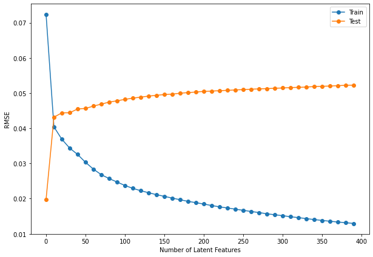

```python
#Creating array for number of latent features and empty lists to store train and test errors
latent_features = np.arange(0, 400, 10)
train_error = []
test_error = []

for k in latent_features:
    #Slicing the U, S, and Vt matrices to get k latent features from train and test data
    s_train_lat, u_train_lat, vt_train_lat = np.diag(s_train[:k]), u_train[:, :k], vt_train[:k, :]
    u_test_lat, vt_test_lat = u_test[:, :k], vt_test[:k, :]

    #Regenerating train and test interaction matrices using k latent features
    interactions_matrix_train_preds = np.around(np.matmul(np.matmul(u_train_lat, s_train_lat), vt_train_lat))
    interactions_matrix_test_preds = np.around(np.matmul(np.matmul(u_test_lat, s_train_lat), vt_test_lat))

    #Calculating the actual and predicted average rating for each movie in the training data
    avg_rating_train = interactions_matrix_train.mean(axis=0)
    avg_rating_train_pred = interactions_matrix_train_preds.mean(axis=0)

    #Calculating the actual and predicted average rating for each movie in the test data
    avg_rating_test = interactions_matrix_test.mean(axis=0)
    avg_rating_test_pred = interactions_matrix_test_preds.mean(axis=0)

    #Calculating train and test RMSE
    train_rmse = mean_squared_error(avg_rating_train, avg_rating_train_pred, squared=False)
    test_rmse = mean_squared_error(avg_rating_test, avg_rating_test_pred, squared=False)

    train_error.append(train_rmse)
    test_error.append(test_rmse)

#Plotting train and test RMSE
plt.figure(figsize=(10,7))
plt.plot(latent_features, train_error, label='Train', marker='o');
plt.plot(latent_features, test_error, label='Test', marker='o');
plt.xlabel('Number of Latent Features');
plt.ylabel('RMSE');
plt.legend();
```

Let us now **reconstruct the original interaction matrix using latent features = 10** in the same way as above

```python
s_final, u_final, vt_final = np.diag(s[:10]), u[:, :10], vt[:10, :]
Ldiff_Predicted = np.around(np.matmul(np.matmul(u_final, s_final), vt_final))
Ldiff_Predicted = pd.DataFrame(abs(Ldiff_Predicted), columns = match_cols, index = match_idx)
Ldiff_Predicted
```

|  | 1 | 4 | 5 | 11 | 14 | 15 | 16 | 17 | 20 | 21 | ... | 9976 | 9977 | 9981 | 9983 | 9988 | 9989 | 9992 | 9994 | 9995 | 9996 |
| --- | --- | --- | --- | --- | --- | --- | --- | --- | --- | --- | --- | --- | --- | --- | --- | --- | --- | --- | --- | --- | --- |
| 11 | 0.0 | 0.0 | 0.0 | 0.0 | 0.0 | 0.0 | 0.0 | 0.0 | 0.0 | 0.0 | ... | 0.0 | 0.0 | 0.0 | 0.0 | 0.0 | 0.0 | 0.0 | 0.0 | 0.0 | 0.0 |
| 17 | 0.0 | 0.0 | 0.0 | 0.0 | 0.0 | 0.0 | 0.0 | 0.0 | 0.0 | 0.0 | ... | 0.0 | 0.0 | 0.0 | 0.0 | 0.0 | 0.0 | 0.0 | 0.0 | 0.0 | 0.0 |
| 32 | 0.0 | 0.0 | 0.0 | 0.0 | 0.0 | 0.0 | 0.0 | 0.0 | 0.0 | 0.0 | ... | 0.0 | 0.0 | 0.0 | 0.0 | 0.0 | 0.0 | 0.0 | 0.0 | 0.0 | 0.0 |
| 42 | 0.0 | 0.0 | 0.0 | 0.0 | 0.0 | 0.0 | 0.0 | 0.0 | 0.0 | 0.0 | ... | 0.0 | 0.0 | 0.0 | 0.0 | 0.0 | 0.0 | 0.0 | 0.0 | 0.0 | 0.0 |
| 57 | 0.0 | 0.0 | 0.0 | 0.0 | 0.0 | 0.0 | 0.0 | 0.0 | 0.0 | 0.0 | ... | 0.0 | 0.0 | 0.0 | 0.0 | 0.0 | 0.0 | 0.0 | 0.0 | 0.0 | 0.0 |
| ... | ... | ... | ... | ... | ... | ... | ... | ... | ... | ... | ... | ... | ... | ... | ... | ... | ... | ... | ... | ... | ... |
| 76307 | 0.0 | 0.0 | 0.0 | 0.0 | 0.0 | 0.0 | 0.0 | 0.0 | 0.0 | 0.0 | ... | 0.0 | 0.0 | 0.0 | 0.0 | 0.0 | 0.0 | 0.0 | 0.0 | 0.0 | 0.0 |
| 76331 | 0.0 | 0.0 | 0.0 | 0.0 | 0.0 | 0.0 | 0.0 | 0.0 | 0.0 | 0.0 | ... | 0.0 | 0.0 | 0.0 | 0.0 | 0.0 | 0.0 | 0.0 | 0.0 | 0.0 | 0.0 |
| 76333 | 0.0 | 0.0 | 0.0 | 0.0 | 0.0 | 0.0 | 0.0 | 0.0 | 0.0 | 0.0 | ... | 0.0 | 0.0 | 0.0 | 0.0 | 0.0 | 0.0 | 0.0 | 0.0 | 0.0 | 0.0 |
| 76342 | 0.0 | 0.0 | 0.0 | 0.0 | 0.0 | 0.0 | 0.0 | 0.0 | 0.0 | 0.0 | ... | 0.0 | 0.0 | 0.0 | 0.0 | 0.0 | 0.0 | 0.0 | 0.0 | 0.0 | 0.0 |
| 76347 | 0.0 | 0.0 | 0.0 | 0.0 | 0.0 | 0.0 | 0.0 | 0.0 | 0.0 | 0.0 | ... | 0.0 | 0.0 | 0.0 | 0.0 | 0.0 | 0.0 | 0.0 | 0.0 | 0.0 | 0.0 |

5000 rows × 4991 columns